# Grays Harbor Recreational Crab Harvest Estimate

Pooled CPUE Model - 2024-25 Season (2024-09-16 to 2025-09-15) Results Report

Washington Department of Fish and Wildlife

2026-09-29

> **How to read this report.** This is the results report for one harvest estimate from the pooled CPUE model, the method of record. **The headline is Section 7**: the port total and its components, each with a 95% credible interval. Read it with Section 6 (did every fit converge, and which method each component reports), Section 13 (how far the design-based and Bayesian estimates agree) and Section 16 (every warning, fallback and skipped step this run recorded). Sections 1 to 5 show the configuration, the inputs and the resolved expansion factors; Sections 8 to 12 break the total down and show the diagnostics behind it. Code is hidden; the **Code** buttons reveal any step. Every number in this report is computed by this run; none is typed into the text.

## 1. Setup and configuration

Loads packages, sources the helper functions in `03_R_functions/`, applies the run configuration from `run_config.R`, and defines the two sub-seasons (pot-closure and all-gear). Every user-selectable toggle for this run lives in `run_config.R`.

```r
###############################################################################
# Crab Creel Estimation - Westport / Grays Harbor  |  Pooled CPUE Model
# Any season, part-season or span (2024-25 is the development test season)
# Pipeline code: last numbered tag v7.9 (2026-07-12); versioned by date since, and the
# model of record is this code as of 2026-09-29 (B44 to B51; see the development history)
#
# Estimates total recreational Dungeness crab harvest at Westport / Grays Harbor
# from a single pooled CPUE process shared across gear types. Three population
# components are estimated independently and summed to the port total:
#   1. Shore crabbers (dock + jetty + beach)   BSS + PE
#   2. Private boat crabbers                    BSS + PE
#   3. Commercial/charter boats                 commercial census + charter expansion
# Two gear-regime sub-seasons per season (build_subseasons(); the dates are run_config's
# pot_closure_start / pot_closure_end): a pot closure (non-pot gear only) and all-gear (pots
# allowed); a multi-season span has one pair per season. "Pot closure" was formerly labeled
# "ring-net only"; non-pot gear other than ring nets is also legal, so the name was
# a misnomer. The internal key stays "ring_net_only" for output-filename continuity.
#
# CURRENT STATE: both fitted components run on the gear-DEPLOYMENT effort
# unit (h = number_of_gear, L = tau), via the shared 03_R_functions/bss_effort_spec.R.
# Helper functions live in 03_R_functions/ (sourced wholesale in the setup chunk),
# and every user-selectable toggle lives in run_config.R (the single file you edit);
# this .Rmd's params block holds only model-internal tuning (sampler settings, gate
# and AR-selector thresholds).
#
# KEY FEATURES: adaptive AR(1) temporal resolution; B1_C weekend CPUE effect;
# Method v2.0: derived shore turnover tau_shore and calibration boat turnover with a shared
# tau_bar; dynamic per-stratum crabbing fraction f with a combo share c; zero-inflated NB2
# shore catch; commercial census + charter expansion; the single-section level
# hierarchies collapsed (A31, T2.5). L_effective / day length only under a time unit (B55);
# data-driven R_G prior;
# gear-deployment effort scale (R_G_boat / tau_boat, tau_shore); scale-aware
# convergence gate; the expected catch from the generated quantities and, since B46, the
# predictive catch drawn after the fit from the fitted zero-inflated NB
# (03_R_functions/bss_predictive_catch.R); every chain started with init_r = 0.5 (B51).
#
# FULL CHANGE LOG (every version, newest first, with working notes):
#   07_documentation/BSS-GH-pooled-CPUE-model-development-history.md
# METHOD REFERENCE (the published method of record):
#   07_documentation/BSS-GH-pooled-CPUE-model-documentation.md
###############################################################################

# ===========================================================================
# 0. SETUP
# ===========================================================================

# 2026-09-28 (B46): one package list and loader (03_R_functions/bss_packages.R): renv.lock's
# versions when renv is active, a stop naming the package when one cannot be had.
if (!requireNamespace("here", quietly = TRUE)) stop("Package 'here' is missing: run renv::restore() first.", call. = FALSE)
source(here::here("03_R_functions", "bss_packages.R")); bss_load_packages()
rstan_options(auto_write = TRUE)
purrr::walk(list.files(here("03_R_functions"), full.names = TRUE), source)

run_date <- format(Sys.Date(), "%Y%m%d")
# Unique per-run subfolder so same-day runs never overwrite each other.
# run_config$run_tag (set in run_config.R, or by run_rg_sweep.R) names the folder,
# e.g. pooled-CPUE-run5; blank falls back to a HHMMSS timestamp. The `knit:` block
# above stashes that timestamp in options(crab_run_tag=) so a standalone RStudio
# knit writes its HTML and this driver's CSVs into the SAME folder.
# 2026-09-28 (B46): bss_output_dir() also refuses a tag naming a season the run does not
# model, never writes into a folder that already holds a run, and makes the tag path-safe.
output_dir <- bss_output_dir("pooled-CPUE-", if (exists("run_config")) run_config else NULL)
```

```r
# timer_start() / timer_stop() and their timing state now live in
# 03_R_functions/bss_timers.R (auto-sourced). Read collected timings with
# bss_timer_log(). Extracted; behavior unchanged.

run_start_time <- Sys.time()

# ===========================================================================
# 0.1 PARAMETERS
# ===========================================================================

params <- list(
  # NOTE: every user-selectable toggle (season window, structural dates, catch
  # groups, day-typing, effort unit, incomplete-trip filter, I/E settings,
  # holidays, and the model-behavior levers such as collapse_mu_hier) now lives in
  # run_config.R, the single source of truth, and is applied as an override below.
  # This list holds ONLY this model's internal tuning: the Stan model file, the
  # per-fit sampler settings, the convergence-gate thresholds, and the adaptive
  # AR-selector thresholds. These rarely change and legitimately differ from the
  # gear-resolved model, so they stay with the model rather than in run_config.

  # --- Stan model file ---
  bss_model_file    = "crab_bss_pooled.stan",

  # --- Shared reader behavior (merged fetch_crab_data, 2026-08-01) ---
  # TRUE = the historical pooled reader: drop private_boat interviews with no
  # positive gear_time_total. (The gear-resolved driver sets FALSE.)
  boat_require_gear_time = TRUE,

  # --- BSS sampler defaults ---
  bss_adapt_delta   = 0.9,

  # --- BSS convergence tuning (extra iterations for longer sub-seasons / daily AR) ---
  bss_iter_default          = 3000,
  bss_warmup_default        = 1500,
  bss_max_treedepth_default = 10,
  bss_iter_shore_allgear    = 5000,
  bss_warmup_shore_allgear  = 2500,

  # Per-fit treedepth / adapt_delta overrides (v6.1, ported from gear-resolved
  # v5.2). The shore all-gear daily-AR posterior is the densest geometry and
  # saturated max_treedepth=10 on 91.6% of iterations in the 2026-04-08 run;
  # ring-net fits are data-sparse and benefit from tighter adaptation. Any fit
  # without an override uses the *_default values.
  # 2026-09-08: production now caps shore all-gear at WEEKLY (P_n 44, not 289), so
  # these settings, tuned for the daily geometry, are retained as headroom rather
  # than necessity; they also cover the ladder, which can still fit this component
  # at daily. Do not trim them without re-checking a daily rung.
  bss_treedepth_shore_allgear = 14,
  bss_delta_shore_allgear     = 0.95,
  bss_treedepth_ringnet       = 12,
  bss_delta_ringnet           = 0.95,

  # v6.2: boat all-gear sampler tuning. The boat all-gear fit failed in the
  # 2026-04-08 run (5998 divergences, R-hat 1.074, n_eff 76) under defaults.
  # treedepth_pct was 0, so divergences came from step size: adapt_delta is
  # raised to 0.99 (primary lever) and max_treedepth to 13 (buffer), with more
  # iterations to give n_eff a chance to clear 400.
  bss_iter_boat_allgear       = 5000,
  bss_warmup_boat_allgear     = 2500,
  bss_treedepth_boat_allgear  = 13,
  bss_delta_boat_allgear      = 0.99,

  # bss_min_interviews MOVED to run_config.R (improvement 6, 2026-08-25). It lived here,
  # in params_model, which is merged ON TOP of run_config -- so a value set in run_config
  # was silently overridden by this one. Both the pre-filter floor
  # (bss_min_interviews) and the new post-filter floor (bss_min_interviews_fitted) are
  # now single-sourced from run_config.R.

  # --- B1.8: SCALE-AWARE convergence gate thresholds --------------------------
  # The gate rejects a BSS fit whose divergent transitions have BIASED the
  # reported totals, while accepting a fit whose divergences are diffuse and
  # harmless (Betancourt 2017). It measures the divergent draws' impact on each
  # reported TOTAL in units of that total's posterior SD (scale-invariant):
  #   impact = |median(all_draws) - median(bulk_draws)| / sd(all_draws)
  # A fit passes when max(impact_C, impact_E) is below max_divergence_total_impact_sd,
  # with a hard divergent-FRACTION backstop (max_divergence_fraction). See the
  # model documentation and development history for the full B1.8 rationale.
  max_divergence_total_impact_sd = 0.10,
  # P7 (2026-07-12): tightened from 0.15 to 0.05. The scale-aware impact test above
  # (max_divergence_total_impact_sd) is the primary gate; this fraction is only a hard
  # backstop, and 0.15 was too loose to defend for a publication method (a fit at ~14%
  # divergences would have passed as BSS). 0.05 matches the gear-resolved model. The
  # 2026-07-11 pooled fits (0.54%, 2.23%, 2.5% divergences) are all under 5%, so this
  # changes no current gating decision; divergences indicate biased HMC exploration
  # (Betancourt 2017), so the backstop belongs near 5%.
  max_divergence_fraction        = 0.05,

  # D37 (2026-09-29): the deprecated max_divergences / max_divergence_distortion keys were
  # removed; nothing read them. The level-normalized distortion is still COMPUTED and
  # reported in convergence_report.csv (distortion_C / distortion_E), without a threshold.

  # --- Adaptive AR temporal-resolution thresholds -----------------------------
  # The model selects the finest AR resolution the data can support:
  #   daily:   effort obs on >= ar_daily_min_coverage of days AND >= ar_daily_min_obs
  #   weekly:  >= ar_weekly_min_per_week effort obs per week on average
  #   monthly: fallback for sparse data
  ar_daily_min_coverage  = 0.25,
  ar_daily_min_obs       = 20,
  ar_weekly_min_per_week = 1.5

  # v6.5 (B1): per-population cap on AR resolution. The map now lives in run_config.R
  # (ar_max_resolution$pooled) so both models' caps sit in one place; this model's cap
  # is selected from it just after the merge below (P5, 2026-07-12). The boat
  # (trailer-count) effort series is too weakly informative for daily AR, so the boat
  # is capped at MONTHLY; the shore is capped at WEEKLY for all-gear and BIWEEKLY for the
  # pot closure (both adopted 2026-09-07 after the ladder, and the evidence is in Section 18
  # of the method document). A population absent from the map defaults to "daily" (no cap).
  # Read ar_max_resolution$pooled in run_config.R for the shipped values; the cap only ever
  # COARSENS, so a cap finer than the data-driven pick is ignored.
  # (D37, 2026-09-29: ie_use_all_dates_for_diagnostics was removed; nothing read it.)
)
```

```r
# --- Run-level config from run_config.R (single source of truth) --------------
# run_config.R owns every user-selectable toggle (season window, structural dates,
# catch groups, day-typing, effort unit, filters, I/E settings, holidays, the AR
# resolution map, and the model-behavior toggles). When launched via run_estimation.R
# the orchestrator has already defined `run_config`; when this .Rmd is knit standalone
# the guard below sources run_config.R so the same toggles are used either way.
if (!exists("run_config")) source(here::here("run_config.R"))
# P5 (2026-07-12): run_config is the BASE parameter set; this model's internal tuning
# (defined above) is layered on top. The two key sets are disjoint, so the merge order
# carries intent only (run_config is the base, the model updates it with its specifics).
params <- modifyList(run_config, params)
# 2026-08-30: the ONE sanctioned way for run_config to reach a sampler setting, applied
# AFTER the merge because params_model wins it (03_R_functions/bss_sampler_override.R).
# Unset in production, so this is a no-op on a normal run; it errors loudly on a
# non-sampler key rather than silently dropping it.
params <- bss_apply_sampler_override(params, model_label = "pooled")
# Select this model's AR-resolution cap from the shared per-model map in run_config.
params$ar_max_resolution <- run_config$ar_max_resolution$pooled

# Crabbing holidays now live in an editable workbook (04_input_files/crabbing_holidays.xlsx),
# read here via 03_R_functions/read_crabbing_holidays.R and filtered to season_filter, so the
# season update is a spreadsheet edit rather than a code edit. Populate params$crabbing_holiday_dates
# ONCE here; every downstream consumer (classify_day_type, prep_days_crab, estimate_comm_charter)
# reads it from params unchanged. Kept as a bare object too so inline references still resolve.
params$crabbing_holiday_dates <- read_crabbing_holidays(params)
crabbing_holiday_dates <- params$crabbing_holiday_dates


# Dungeness only. The Red Rock catch group and its estimate_red_rock switch were removed
# 2026-09-28 (B44): never shipped on, and never validated (turning it on summed the two
# species in the monthly tables). The loops over catch_groups stay, over one group.
catch_groups <- "Dungeness_Kept"

# Sub-seasons split by the pot-closure window (03_R_functions/build_subseasons.R).
# The pot closure is when pots are not legal (non-pot gear only); its window is set
# explicitly in run_config (pot_closure_start / pot_closure_end). For the current
# config (closure at the season start) this returns the historical two sub-seasons
# with unchanged internal names ("ring_net_only" is the pot-closure key, kept for
# output-filename continuity; display_name is "Pot closure"), so keys and filenames
# do not change. A mid-season closure adds pre/post all-gear periods automatically.
# Model logic keys off ss$gear_regime ("pot_closure" | "all_gear"), never ss$name.
subseasons <- build_subseasons(params)
for (ss in subseasons) {
  cat(sprintf("Sub-season: %-26s %s to %s (%d days)\n",
              paste0(ss$display_name, " [", ss$name, "]"),
              ss$start, ss$end, as.integer(ss$end - ss$start + 1)))
}
cat(sprintf("Catch groups: %s\n", paste(catch_groups, collapse = ", ")))

# Sub-season aggregation is now GENERAL (2026-07-13): the PE port summary, the catch-by-
# mode table, and the final harvest table sum over whatever sub-seasons build_subseasons
# produced (via pe_pop_sum / pe_port_total below), rather than the hardcoded historical
# pair. A mid-season pot closure (which adds all_gear_pre / all_gear_post keys) is
# therefore handled end-to-end. That general path has NOT yet been validated against a
# fitted run, so emit a loud note when the sub-season set departs from the historical
# pair; verify the port total against the per-component PE table before citing such a run.
ss_name_set <- vapply(subseasons, function(z) z$name, character(1))
if (!setequal(ss_name_set, c("ring_net_only", "all_gear"))) {
  cat(sprintf(paste0(
    "\n*** NOTE: non-historical sub-season set {%s}. The report aggregation sums over all ",
    "sub-seasons per population, but this configuration has not been validated against a ",
    "fitted run; verify the port total against the per-component PE table before citing. ***\n"),
    paste(ss_name_set, collapse = ", ")))
}

# --- Generalized PE aggregation over the sub-season set (build_subseasons) -----------
# Sum a PE field over all sub-seasons of a population so the port total, the by-mode
# table, and the final-table PE rows follow build_subseasons instead of a fixed 5-row
# layout. These close over the run globals `pe_all` (populated by the PE loop) and
# `subseasons`; they are only called after the PE loop, so pe_all exists by call time.
# pe_all keys are "<population>_<subseason-name>"; a missing key or field contributes 0.
pe_field   <- function(key, field) pe_all[[key]][[field]] %||% 0
pe_pop_sum <- function(pop, field)
  sum(vapply(subseasons, function(ss) pe_field(paste0(pop, "_", ss$name), field), numeric(1)), na.rm = TRUE)
pe_port_total <- function(field)  # na.rm matches the baseline sum([1:5], na.rm=TRUE):
  sum(pe_pop_sum("shore", field), pe_pop_sum("private_boat", field),
      pe_field("comm_charter", field), na.rm = TRUE)


# Every step below calls a function in 03_R_functions/ (sourced above): fetch_crab_data(),
# fetch_ie_data() and estimate_shore_turnover() (bss_day_length.R), prep_days_crab(),
# prep_population_summary(), run_pe_pooled(), prep_bss_crab_pooled(), estimate_comm_charter()
# and the diagnostics writers. README-R-functions.md lists every file. (Stub comments that
# described each function as "extracted verbatim" from this file, some of them describing a
# day-length L that is no longer the expansion factor, were removed 2026-09-29.)
```

This run’s configuration (run_config.R merged with the driver’s model settings). Every key is in run_parameters.txt.

| Setting | Value |
| --- | --- |
| Season(s) | 2024-25 |
| Estimation window | 2024-09-16 to 2025-09-15 |
| Sub-seasons | Pot closure 2024-09-16 to 2024-11-30; All gear 2024-12-01 to 2025-09-15 |
| Shore effort unit | gear-deployments |
| Model | crab_bss_pooled.stan |
| Chains / cores / seed / init_r | 4 / 4 / 20260619 / 0.5 |
| Iterations (shore all-gear; boat all-gear; others) | 5000 (warmup 2500); 5000 (warmup 2500); 3000 (warmup 1500) |
| Convergence gate | R-hat < 1.01, n_eff > 400, divergent fraction < 0.05, impact < 0.1 SD |
| AR cap (pooled) | shore = weekly/biweekly; private_boat = monthly |
| Level hierarchy, one section (A31) | both |
| Shore turnover prior | derived (resolved in Section 3.1) |
| Boat turnover prior | calibration, log-SD 0.5 (resolved in Section 3.1) |
| Shared turnover | TRUE |
| Crabbing fraction f | dynamic = TRUE, strata = month, source = both |
| Marine hazard term | mode = manual; boat = nws_sca_any; shore = none; sub-seasons = all_gear |
| Opener covariates | off |
| Census / charter | census_expansion = none; charter_frame = roster; charter_expansion = vessel; census_uncertainty = charter |
| PE unsampled cells | effort fill = local_day_type; CPUE fill = local; variance = impute_aware |
| Code (git) | 2523e8e (working tree has uncommitted changes) |
| Output folder | pooled-CPUE-2024-25-220449 |

## 2. Data ingestion

Reads the effort counts, crabber interviews, the commercial tally and charter roster, the ingress/egress (I/E) surveys, the sampler contacts and the OSP boat counts, and classifies each interview as shore, private boat, or commercial/charter. The table after this step counts what each stream delivered for this run’s window.

```r
# ---- 7.0 LOAD DATA ----
timer_start("1_load_data")
cat("\n", strrep("=",60), "\n LOADING DATA\n", strrep("=",60), "\n")
dwg <- fetch_crab_data(params)
ie_data <- fetch_ie_data(params)
# Review item 1 (2026-09-08): the crabbing-fraction classification rows come from the
# sampler contacts (dwg$boat_contacts, every private boat approached) and/or the egress
# columns of the I/E workbook, per params$crab_fraction_source. See crab_fraction.R.
params$crab_fraction_rows <- crab_fraction_source_rows(dwg, ie_data, params)

# --- Review item 2 (2026-09-08): the shore turnover at the hours the counts were taken.
# Derived from the I/E interval rows (the workbook's `time` column) and the shore count
# hours EVERY run and written to shore_turnover_*.csv; it becomes the prior centre only
# when run_config sets tau_shore_prior_mu = "derived" (bss_resolve_tau_shore_prior), because
# it moves the shore component by the ratio of the two priors (about 1.47 on 2024-25).
shore_turnover <- estimate_shore_turnover(attr(ie_data, "ie_intervals"), dwg$shore_effort, params)
write_shore_turnover(shore_turnover, output_dir)
params <- bss_resolve_tau_shore_prior(params, shore_turnover)

# --- 2026-09-09: the sampler shifts and the shift-coverage diagnostic. The crabbing
# fraction is read from boats contacted DURING a shift (about 9:45 to 15:50); this writes
# how much of the day's boat returns the shift covers (from the boat I/E return profile)
# and whether the trip-type mix drifts with the hour inside the shift. Diagnostic only;
# guarded so a missing shifts file cannot break a run (03_R_functions/sampler_shifts.R).
sampler_shifts <- tryCatch(fetch_sampler_shifts(params),
                           error = function(e) { bss_warn("sampler shifts", paste("Sampler shifts skipped:", conditionMessage(e)), severity = "note"); NULL })
shift_coverage <- tryCatch(diagnose_shift_coverage(sampler_shifts, ie_data, dwg$boat_contacts_detail, params, output_dir = output_dir),
                           error = function(e) { bss_warn("sampler shifts", paste("Shift coverage diagnostic skipped:", conditionMessage(e)), severity = "note"); NULL })

# --- Phase 0: OSP Westport boat-count ingest + overlap calibration ---
# NOT diagnostic only since 2026-09-08: under tau_boat_prior_mu = "calibration" the overlap
# result sets the boat turnover prior centre (bss_resolve_tau_boat_prior below), and an error
# caught here falls back to tau_boat_prior_mu_fallback (3.03, the 2024-25 calibration; D36,
# 2026-09-29), and both the error and the fallback go to the run-warnings log (bss_warn),
# which the report prints in its last section.
# fetch_osp_boat_counts() and diagnose_osp_trailer_overlap() live in 03_R_functions/
# (auto-sourced). The diagnostic writes osp_trailer_overlap_calibration.csv,
# osp_trailer_overlap_pairs.csv, osp_coverage_audit.csv and osp_trailer_overlap.png to
# output_dir. osp_boat is the per-day OSP series (boat_effort schema) that Phase 1
# consumes as a second boat effort stream. Guarded so a missing file cannot break a run.
osp_boat <- tryCatch(fetch_osp_boat_counts(params),
                     error = function(e) { bss_warn("OSP", paste("OSP ingest skipped:", conditionMessage(e))); NULL })
osp_overlap <- tryCatch(diagnose_osp_trailer_overlap(osp_boat, params, output_dir = output_dir),
                        error = function(e) { bss_warn("OSP", paste("OSP overlap diagnostic skipped:", conditionMessage(e))); NULL })
# improvement 8: OSP crab-ONLY counts (a LOWER bound on the crabbing fraction f, because
# OSP labels combo trips by the non-crab fishery). Lifted here so both the PE and the BSS
# read the same rows from one file read. Empty until the crab-only column exists, in which
# case every f feature is inert and f behaves exactly as it does today.
params$osp_crab_rows <- attr(osp_boat, "osp_crab_rows")
if (!is.null(params$osp_crab_rows) && nrow(params$osp_crab_rows) > 0)
  cat(sprintf("  OSP crab-only rows lifted for the f lower bound: %d day(s).\n",
              nrow(params$osp_crab_rows)))
# B48 (2026-09-28): the per-day crab-only rows as the model reads them (the boats SAMPLED, the
# rate behind that n and where it came from), so the f floor can be audited day by day.
if (!is.null(params$osp_crab_rows) && nrow(params$osp_crab_rows) > 0)
  tryCatch(utils::write.csv(dplyr::mutate(params$osp_crab_rows, crab_only_share = osp_crab_only / osp_total),
                            file.path(output_dir, "osp_crab_only_daily.csv"), row.names = FALSE),
           error = function(e) bss_warn("OSP", paste("osp_crab_only_daily.csv not written:", conditionMessage(e)), severity = "note"))

# --- Review item 3 + 5 (2026-09-08): resolve the boat turnover prior centre from THIS
# window's OSP/trailer overlap when tau_boat_prior_mu = "calibration". The resolved
# number replaces params$tau_boat_prior_mu, so the PE (run_pe_pooled), the shared-turnover
# prior (bss_effort_spec -> bss_shared_tau_data) and the tau-sensitivity projection all
# expand the trailer count by one quantity. See 03_R_functions/bss_turnover_prior.R.
params <- bss_resolve_tau_boat_prior(params, osp_overlap)

# --- Fit L_effective regression ---
# B55 (2026-09-29): only when a day length is used (a time-denominated shore unit, or
# day_length_diagnostics = TRUE). Under gear-deployments nothing reads it; the I/E survey's
# job is the shore turnover above (shore_turnover_*.csv) and the I/E observation stream.
L_eff_model <- NULL
if(isTRUE(params$use_ie_day_length) && bss_needs_day_length(params) && nrow(ie_data) > 0) {
  L_eff_model <- estimate_L_effective(ie_data, params)
  if(!is.null(L_eff_model)) {
    # Save regression diagnostics
    if(!is.null(L_eff_model$detail)) {
      write.csv(L_eff_model$detail,
                file.path(output_dir, "L_effective_ie_detail.csv"), row.names = FALSE)
    }
  }
}
timer_stop("1_load_data")
```

What each input stream delivered. ‘Rows’ counts records as read (the I/E rows span every season in the workbook, because the shore turnover pools them; D24); ‘Days in window’ counts distinct days inside the estimation window. The OSP crab-only column is optional (B48): zero days means OSP has not delivered it.

| Stream | Rows | Days in window |
| --- | --- | --- |
| Shore gear counts | 365 | 197 |
| Private-boat trailer counts | 240 | 186 |
| Interviews: shore | 3,731 | 197 |
| Interviews: private boat | 180 | 91 |
| Interviews: commercial/charter | 165 | 45 |
| Sampler boat contacts (crabbing fraction) | 422 | 124 |
| OSP returning-boat days | 148 | 148 |
| OSP crab-only days | 0 | 0 |
| Commercial/charter tally days | 47 | 47 |
| Charter roster trips | 40 | 38 |
| I/E survey days: shore (all seasons) | 40 | 6 |
| I/E survey days: boat (all seasons) | 2 | 0 |

## 3. Input diagnostics: effort and CPUE

The raw inputs before any modelling: the shore gear counts and the private-boat trailer counts (each point is a day’s MEAN count, the quantity the effort likelihood is scaled to; days with more counts are larger), the OSP returning-boat totals, and the interview catch rate per gear deployment, the unit the model uses. Look for gaps (a run of unsampled weekends) and anomalies (an implausible spike).

```r
# ---- 7.1 DIAGNOSTIC PLOTS ----
timer_start("2_diagnostic_plots")
cat("\n", strrep("=",60), "\n DIAGNOSTIC PLOTS\n", strrep("=",60), "\n")

days_full <- prep_days_crab(params$est_date_start, params$est_date_end,
                            params, L_eff_model = L_eff_model)
```

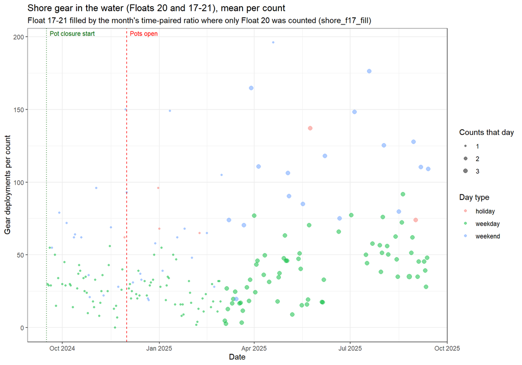

Shore gear in the water, mean per count, by day type. The dotted and dashed lines mark the pot-closure start and the day pots open.

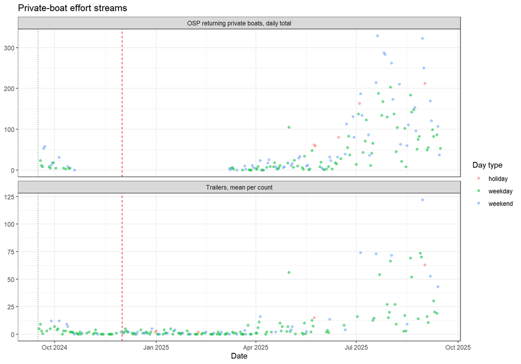

Private-boat effort: the trailer counts (mean per count) and the OSP returning-boat totals.

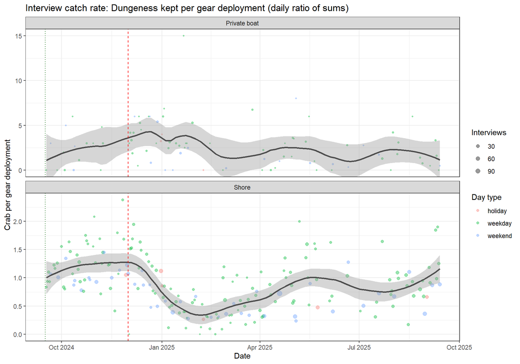

Interview catch rate per gear deployment, by population, with a loess smooth.

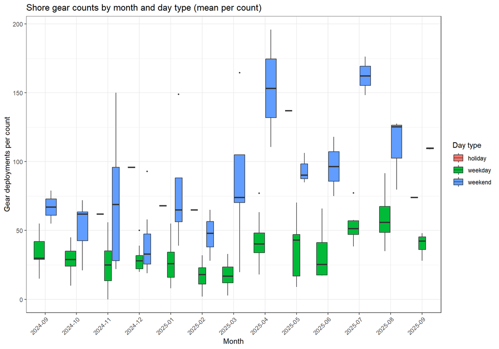

Shore gear counts by month and day type.

```r
# Plot 1: Shore gear count timeseries
p_shore_effort <- dwg$shore_effort |>
  group_by(event_date) |>
  # 2026-09-29: the day's MEAN count (it was the SUM over the day's 1 to 3 counts, which
  # inflated a multi-count day 2 to 3x on the page; the model never used the sum).
  summarise(mean_gear = mean(count_quantity), n_counts = n(), .groups = "drop") |>
  mutate(day_type = classify_day_type(event_date, params)) |>
  ggplot(aes(x = event_date, y = mean_gear, color = day_type, size = n_counts)) +
  geom_point(alpha = 0.5) +
  pot_closure_markers(params, labels = TRUE) +
  scale_size_continuous(range = c(1,3), breaks = 1:3, name = "Counts that day") +
  scale_y_continuous(labels = scales::comma) +
  labs(title = "Shore gear in the water (Floats 20 and 17-21), mean per count",
       subtitle = "Float 17-21 filled by the month's time-paired ratio where only Float 20 was counted (shore_f17_fill)",
       x = "Date", y = "Gear deployments per count", color = "Day type") +
  theme_bw()
ggsave(file.path(output_dir, "plot_shore_effort_timeseries.png"), p_shore_effort, width = 10, height = 6)

# Plot 2: Boat trailer count timeseries
p_boat_effort <- dwg$boat_effort |>
  group_by(event_date) |>
  summarise(value = mean(count_quantity), n_counts = n(), .groups = "drop") |>
  mutate(day_type = classify_day_type(event_date, params), series = "Trailers, mean per count") |>
  dplyr::bind_rows(
    if (!is.null(osp_boat) && nrow(osp_boat))
      osp_boat |> group_by(event_date) |> summarise(value = sum(count_quantity), n_counts = 1L, .groups = "drop") |>
        dplyr::filter(event_date >= as.Date(params$est_date_start), event_date <= as.Date(params$est_date_end)) |>
        mutate(day_type = classify_day_type(event_date, params), series = "OSP returning private boats, daily total")
    else NULL) |>
  ggplot(aes(x = event_date, y = value, color = day_type)) +
  geom_point(alpha = 0.5) +
  pot_closure_markers(params, labels = FALSE) +
  facet_wrap(~series, ncol = 1, scales = "free_y") +
  scale_y_continuous(labels = scales::comma) +
  labs(title = "Private-boat effort streams", x = "Date", y = NULL, color = "Day type") +
  theme_bw()
ggsave(file.path(output_dir, "plot_boat_effort_timeseries.png"), p_boat_effort, width = 10, height = 8)

# Plot 3: CPUE by population, per GEAR DEPLOYMENT (2026-09-29: it was per crabber-hour, the
# unit the model left in v7.7), as the day's ratio of sums, the estimator the PE uses.
cpue_data <- dwg$interview |>
  mutate(.g = suppressWarnings(as.numeric(number_of_gear))) |>
  filter(is.finite(.g), .g > 0, dungeness_kept >= 0, population %in% c("shore", "private_boat")) |>
  group_by(event_date, population) |>
  summarise(cpue = sum(dungeness_kept) / sum(.g), n_int = n(), .groups = "drop") |>
  mutate(day_type = classify_day_type(event_date, params),
         population = dplyr::recode(population, shore = "Shore", private_boat = "Private boat"))

p_cpue <- cpue_data |>
  ggplot(aes(x = event_date, y = cpue, color = day_type)) +
  geom_point(aes(size = n_int), alpha = 0.4) +
  geom_smooth(method = "loess", formula = y ~ x, span = 0.3, se = TRUE, color = "grey30") +
  pot_closure_markers(params, labels = FALSE) +
  facet_wrap(~population, ncol = 1, scales = "free_y") +
  scale_size_continuous(range = c(0.8, 3), name = "Interviews") +
  coord_cartesian(ylim = c(0, NA)) +
  labs(title = "Interview catch rate: Dungeness kept per gear deployment (daily ratio of sums)",
       x = "Date", y = "Crab per gear deployment", color = "Day type") +
  theme_bw()
ggsave(file.path(output_dir, "plot_cpue_timeseries.png"), p_cpue, width = 10, height = 8)

# Plot 4: Gear counts by month and day type (boxplot of the day's mean count)
p_effort_month <- dwg$shore_effort |>
  group_by(event_date) |>
  summarise(mean_gear = mean(count_quantity), .groups = "drop") |>
  mutate(day_type = classify_day_type(event_date, params),
         month_label = factor(format(event_date, "%Y-%m"))) |>
  ggplot(aes(x = month_label, y = mean_gear, fill = day_type)) +
  geom_boxplot(outlier.size = 0.8) +
  labs(title = "Shore gear counts by month and day type (mean per count)",
       x = "Month", y = "Gear deployments per count", fill = "Day type") +
  theme_bw() +
  theme(axis.text.x = element_text(angle = 45, hjust = 1))
ggsave(file.path(output_dir, "plot_effort_by_month.png"), p_effort_month, width = 12, height = 6)

# L_effective regression and day-length plots: ONLY under a time-denominated unit (B55). Under
# gear-deployments nothing reads a day length, and these two figures used to present one as the
# quantity "propagated into the Stan model", which it is not.
if(bss_needs_day_length(params) && !is.null(L_eff_model) && !is.null(L_eff_model$detail) && nrow(L_eff_model$detail) >= 3) {
  # Predict L over the estimation window (2026-09-28, B46: it was a fixed 2024 calendar year,
  # so the prediction line and the I/E points sat on different dates in every other season)
  viz_dates <- seq.Date(as.Date(params$est_date_start), as.Date(params$est_date_end), by = "day")
  viz_pred <- L_eff_model$predict_fn(viz_dates, rep("weekday", length(viz_dates)))
  viz_pred_wkend <- L_eff_model$predict_fn(viz_dates, rep("weekend", length(viz_dates)))

  p_L_regression <- ggplot() +
    geom_ribbon(data = tibble(date = viz_dates, lo = viz_pred$L_mu * exp(-1.96 * viz_pred$L_sigma),
                              hi = viz_pred$L_mu * exp(1.96 * viz_pred$L_sigma)),
                aes(x = date, ymin = lo, ymax = hi), alpha = 0.15, fill = "steelblue") +
    geom_line(data = tibble(date = viz_dates, L = viz_pred$L_mu),
              aes(x = date, y = L, color = "Weekday prediction"), linewidth = 0.8) +
    geom_line(data = tibble(date = viz_dates, L = viz_pred_wkend$L_mu),
              aes(x = date, y = L, color = "Weekend prediction"), linewidth = 0.8, linetype = "dashed") +
    geom_point(data = L_eff_model$detail,
               aes(x = event_date, y = L_effective, shape = day_type_group), size = 3) +
    labs(title = "L_effective Regression (log-scale quadratic + day type)",
         subtitle = sprintf("Method: %s | n=%d I/E days | Shaded = 95%% prediction interval",
                            L_eff_model$method, L_eff_model$n_obs),
         x = "Date", y = "L_effective (hours)", color = "Prediction", shape = "I/E day type") +
    theme_bw()
  ggsave(file.path(output_dir, "plot_L_effective_regression.png"), p_L_regression, width = 12, height = 6)
}

# Day length comparison (civil twilight vs regression), time units only (B55)
if (bss_needs_day_length(params)) {
p_day_length <- days_full |>
  ggplot(aes(x = event_date)) +
  geom_line(aes(y = day_length_civil_twilight, color = "Civil twilight"), alpha = 0.5) +
  geom_ribbon(aes(ymin = L_mu * exp(-1.96 * L_prior_sigma),
                  ymax = L_mu * exp(1.96 * L_prior_sigma)),
              alpha = 0.15, fill = "steelblue") +
  geom_line(aes(y = L_mu, color = "I/E L_effective (regression)"), linewidth = 0.8) +
  labs(title = "Day Length with Uncertainty",
       subtitle = "Shaded band = 95% prior interval for L (propagated into Stan model)",
       x = "Date", y = "Day length (hours)", color = "Method") +
  scale_color_manual(values = c("Civil twilight" = "grey60", "I/E L_effective (regression)" = "steelblue")) +
  theme_bw()
ggsave(file.path(output_dir, "plot_day_length_comparison.png"), p_day_length, width = 10, height = 5)
}

cat("  Diagnostic plots saved.\n")
timer_stop("2_diagnostic_plots")
```

### 3.1 The expansion factors: shore and boat turnover

A creel count is a snapshot, so each population’s daily effort is the counted gear times a **turnover** `tau`: how many gear deployments pass through one counted slot in a day. It is the largest single lever on the total (the shore and boat components scale with it one for one), and both centres are **derived from data every run**, not set. The shore turnover comes from the I/E survey’s `time` column, as arrivals over the presence at the hours the counts were actually taken; the boat turnover from the days OSP counted every returning private boat and the samplers counted trailers. With `shared_tau = TRUE` each fit estimates one season-level turnover `tau_bar` around this centre (Section 12.3). **Read the in-window shore value**: the derived centre pools every I/E day in the workbook (CHANGE_REGISTER D24), and where this window’s own days give a different value the shore component moves with it. No day length appears in the expansion (B55); `L_effective` in hours is computed only under a time-denominated effort unit.

The turnover prior centres this run used and where each came from. A ‘fallback’ source means the per-run derivation could not run and the 2024-25 value was used instead (Section 16 records it).

| Population | Prior centre used | Prior log-SD | Source | Alternatives this run |
| --- | --- | --- | --- | --- |
| Shore | 2.477 | 0.10 | derived (I/E time column, 40 days, count-time-weighted ratio of sums) | this window’s own 6 I/E day(s): 2.225; geometric mean 2.632; arrivals over PEAK presence (the retired 1.7 quantity) 1.669 |
| Private boat | 3.030 | 0.50 | calibration (trailer_mean_per_visit, n = 61) | trailer_mean_per_visit 3.03 (n = 61, r = 0.965); trailer_max_per_day 2.74 (n = 61, r = 0.983); trailer_sum_per_day 2.01 (n = 61, r = 0.899) |

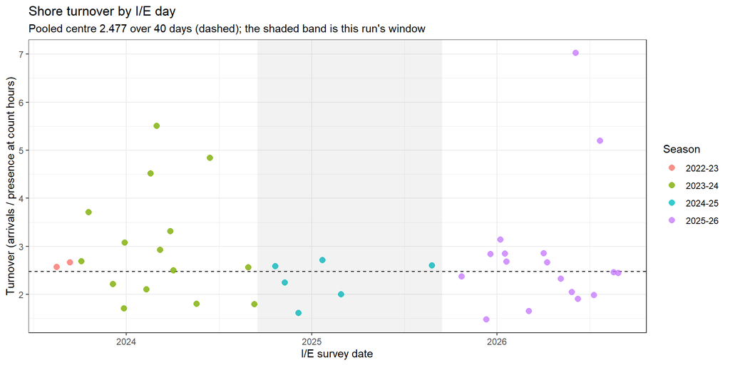

Shore turnover by I/E day (arrivals over the presence at the count hours), coloured by season; the line is the pooled centre the run used.

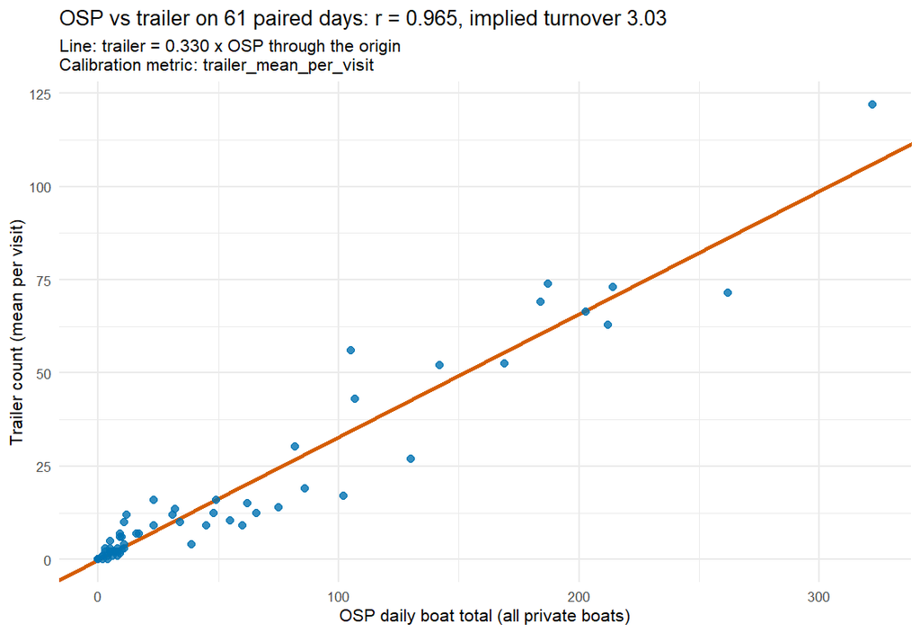

OSP daily private-boat total against the trailer count on the paired days; the line’s inverse slope is the boat turnover centre.

```r
# ---- 7.1b I/E ANALYSIS ----
cat("\n", strrep("=",60), "\n I/E ANALYSIS\n", strrep("=",60), "\n")

if(nrow(ie_data) > 0) {
  ie_validation <- ie_data |>
    filter(population == "shore") |>
    left_join(
      dwg$shore_effort |>
        group_by(event_date) |>
        summarise(mean_gear = mean(count_quantity), n_counts = n(), .groups = "drop"),
      by = "event_date"
    ) |>
    filter(!is.na(mean_gear), mean_gear > 0)

  if(nrow(ie_validation) > 0) {
    # Shared helper (03_R_functions/bss_day_length.R) so the [9, 17] cap lives in
    # exactly one place; this previously hardcoded a 16.0 cap.
    # B55: the civil-twilight comparison only where a day length is used (suncalc).
    ie_validation$day_length_ct <- if (bss_needs_day_length(params)) bss_day_length_civil(ie_validation$event_date, params) else NA_real_

    summ_shore_full <- prep_population_summary(dwg, "shore", params$est_date_start, params$est_date_end, params)
    cpg <- summ_shore_full$crabbers_per_gear

    ie_validation <- ie_validation |>
      mutate(
        gear_est_crabber_hrs = mean_gear * cpg * day_length_ct,
        f_temporal = ie_crabber_hours / gear_est_crabber_hrs,
        pct_error = (gear_est_crabber_hrs - ie_crabber_hours) / ie_crabber_hours * 100
      )

    cat("\n  I/E vs Gear-Count Comparison (paired days):\n")
    for(i in 1:nrow(ie_validation)) {
      r <- ie_validation[i,]
      cat(sprintf("  %-12s %-8s IE=%.0f Gear_est=%.0f f=%.2f\n",
                  as.character(r$event_date), r$day_type, r$ie_crabber_hours,
                  r$gear_est_crabber_hrs, r$f_temporal))
    }
    # 2026-08-27: report the deployment-scale columns too. ie_trips is the observation the
    # shore likelihood consumes under gear-deployments (improvement 1/A); turnover is what
    # `L` carries there; hours_per_trip is their ratio and should sit near the
    # interview-reported trip length (~3.2 h). Without these three, this file could not be
    # used to audit the unit the model actually ran on.
    write.csv(ie_validation |>
      mutate(turnover       = if_else(max_present > 0, ie_trips / max_present, NA_real_),
             hours_per_trip = if_else(ie_trips > 0, ie_crabber_hours / ie_trips, NA_real_)) |>
      select(event_date, day_type, ie_crabber_hours, ie_trips, max_present, mean_present,
             L_effective, turnover, hours_per_trip,
             mean_gear, n_counts, gear_est_crabber_hrs, f_temporal, pct_error),
      file.path(output_dir, "ie_analysis.csv"), row.names = FALSE)
  }
} else {
  bss_warn("I/E", "No I/E data in the workbook: the shore turnover falls back to its prior centre and no I/E observation enters any fit.", severity = "note")
}
```

### 3.2 Shore I/E representativeness (diagnostic)

The shore turnover above is derived from the I/E survey days, so it is only as representative as those days are. This check compares the shore daily gear counts on I/E days against every other sampled day: a mean percentile rank near 0.5 and a non-significant rank test mean the I/E days look like the rest of the season; a rank far from 0.5 means the turnover was measured on unusually busy (or quiet) days, and the shore scale should be read with that in mind (CHANGE_REGISTER D24). The fitted `sigma_IE` (Section 12) is the in-model counterpart: it grows when the I/E arrivals and the counts disagree.

**Shore I/E days: 6.** I/E days skew toward LOWER-effort days (mean percentile 0.29, rank-test p = 0.09).

Shore daily gear counts on I/E observation days against every other sampled day. A mean percentile rank near 0.5 with a non-significant rank test means the I/E days, and so the turnover derived from them, are representative of the season’s effort.

| Days | Sampled days | Mean gear count | Median gear count |
| --- | --- | --- | --- |
| I/E days | 6 | 47.17 | 23.5 |
| non-I/E days | 191 | 92.00 | 51.0 |

### 3.3 Other-fishery openers

Whether other coastal fishery openers (Marine Area 2 finfish, razor-clam digs) enter the EFFORT model as covariates this run. The spillover diagnostic behind the screen, a day-type and month adjusted comparison of crab effort and catch rate on opener days, is in Appendix B; it changes no estimate. `opener_covariate_mode` selects `"off"` (no covariates), `"manual"` or `"auto"` (a candidate enters only if its adjusted effect clears `opener_auto_p` after a Benjamini-Hochberg adjustment across the effort tests). **A screen is not a verdict**: a term selected on a p-value from the data it is then fitted to has an inflated coefficient, and the arbiter is the effort streams’ held-out predictive fit. A boat opener term should be paired with `crab_fraction_strata = "month_opener"`, not with `"opener"`: a crabbing fraction that cannot see opener days converts the opener surge in all-boat counts into crab effort, and plain `"opener"` anchors EVERY stratum to the level prior and silently discards the walk.

```r
# ---- 3.5 OTHER-FISHERY OPENER SPILLOVER (diagnostic; changes no estimate) ----
spillover <- NULL; sp_raw_disp <- NULL; sp_adj_disp <- NULL; p_spill_eff <- NULL; p_spill_cpue <- NULL
if (isTRUE(params$run_fishery_spillover_diag)) {
  timer_start("2b_fishery_spillover")
  spillover <- tryCatch(
    diagnose_fishery_spillover(dwg, params),
    error = function(e) { bss_warn("openers", sprintf("Fishery-opener spillover diagnostic skipped: %s", conditionMessage(e)), severity = "note"); NULL })
  if (!is.null(spillover)) {
    write.csv(spillover$raw,      file.path(output_dir, "fishery_spillover_raw.csv"),      row.names = FALSE)
    write.csv(spillover$adjusted, file.path(output_dir, "fishery_spillover_adjusted.csv"), row.names = FALSE)
    for (nt in spillover$notes) bss_warn("openers", paste("Spillover diagnostic:", nt), severity = "note")

    sp_raw_disp <- spillover$raw |>
      dplyr::transmute(Series, Opener,
        `n (opener)` = n_opener, `Mean (opener)` = round(mean_opener, 2),
        `n (other)`  = n_other,  `Mean (other)`  = round(mean_other, 2),
        `Raw diff`   = round(raw_diff, 2), `Raw %` = round(raw_pct, 0),
        `t-test p`   = fmt_p(t_p))
    sp_adj_disp <- spillover$adjusted |>
      dplyr::transmute(Series, Opener,
        `Adj. estimate` = round(adj_estimate, 2), SE = round(se, 2),
        `95% CI` = ifelse(is.na(ci_lo), "-", sprintf("[%.1f, %.1f]", ci_lo, ci_hi)),
        p = fmt_p(adj_p), Note = note)

    mk_long <- function(df) df |>
      tidyr::pivot_longer(dplyr::all_of(spillover$flag_cols), names_to = "opener", values_to = "is_open") |>
      dplyr::mutate(Opener = unname(spillover$flag_labels[opener]),
                    Status = ifelse(is_open, "Opener", "Other"))
    p_spill_eff <- ggplot(mk_long(spillover$effort_long), aes(Status, value, fill = Status)) +
      geom_boxplot(outlier.size = 0.5, alpha = 0.85) +
      facet_grid(series ~ Opener, scales = "free_y") +
      scale_fill_manual(values = c(Opener = "#c0392b", Other = "grey70")) +
      labs(title = "Crab effort: other-fishery opener days vs other days", x = NULL, y = "Daily effort count") +
      theme_bw() + theme(legend.position = "none", axis.text.x = element_text(angle = 20, hjust = 1))
    p_spill_cpue <- ggplot(mk_long(spillover$cpue_long), aes(Status, value, fill = Status)) +
      geom_boxplot(outlier.size = 0.5, alpha = 0.85) +
      facet_grid(series ~ Opener, scales = "free_y") +
      scale_fill_manual(values = c(Opener = "#c0392b", Other = "grey70")) +
      labs(title = "Interview CPUE: other-fishery opener days vs other days", x = NULL, y = "Dungeness per gear deployment") +
      theme_bw() + theme(legend.position = "none", axis.text.x = element_text(angle = 20, hjust = 1))
  }
  timer_stop("2b_fishery_spillover")
}
```

*No opener covariates considered this run (`opener_covariate_mode = 'off'`).*

### 3.4 The marine hazard effort covariate (the method of record since 2026-09-27)

**The method of record** (CHANGE_REGISTER A30, adopted 2026-09-27): whether an NWS **Small Craft Advisory or higher** was in effect for the Grays Harbor Bar or the coastal waters off Westport at any moment of the local 04:00 to 16:00 window enters the **private-boat all-gear** effort process as one season-constant term (`marine_hazard_mode = "manual"`, `marine_hazard_manual_boat = "nws_sca_any"`, `marine_hazard_gear_regimes = "all_gear"`). No shore term, not the samplers’ bar-restriction tick, and not the pot-closure fit, which stays covariate-free. The flag is known on every day of the window from the archived NWS products in `04_input_files/nws_marine_hazards.xlsx`, which is what a covariate on a daily latent process needs. The other modes remain for experiments: `"off"` (nothing is read), `"auto"` (a candidate enters only if its day-type and month adjusted effect clears `marine_hazard_auto_p` after a multiplicity adjustment), `"on"` (every candidate). The term rides on the effort-covariate block as a column, and its fitted coefficient is in Section 12.4; the table below is the pre-fit screen on the sampled days.

**What to hold when reading the boat term.** A boat term describes ALL private boats: if crabbing boats respond to an advisory differently from finfish boats, the crabbing fraction `f` differs on those days and the monthly `f` cannot see it (D30). The term is one coefficient for the season, and the four-season trailer record says the winter effect is about half the summer’s, so the winter months are probably over-corrected while the season total is insensitive to that shape (D32). The evidence behind the adoption, and these caveats, are in `VALIDATION_CAMPAIGN.md` Sections 1x to 1z. If an experiment enters the bar-restriction tick, note that it is observed on sampled days only and **imputed** on the rest (an expected value from a logistic regression on the archived advisories, `bar_restriction_impute`), so its unsampled-day contribution rests on the NWS flags, not on an observation.

Marine hazard effort-covariate screen. ‘Rate ratio’ is exp(coefficient) from glm(daily count ~ day-type + month + covariate, quasipoisson) on the window’s sampled days (bar restriction: observed days only); ‘Rate ratio (per count)’ is the same GLM fitted per count rather than per daily sum, a sensitivity check nothing selects on; ‘p (adjusted)’ applies the configured multiplicity correction across the marine family. Definition: SC.Y/RB.Y/SW.Y/SI.Y/GL.W/SR.W/SE.W/HF.W in effect at any moment between 04:00 and 16:00 America/Los_Angeles; zones bar = PZZ110, coastal = PZZ156 . Selection is a SCREEN: confirm any selected term against a covariate-free run’s paired effort elpd_loo before citing it.

| Population | Covariate | Rate ratio | Rate ratio (per count) | p (raw) | p (adjusted) | Selected | Reason |
| --- | --- | --- | --- | --- | --- | --- | --- |
| private boat | NWS SCA or higher, any zone | 0.29 | 0.29 | 0.00056 | - | TRUE | manual |
| private boat | USCG bar restriction (sampler tick) | 0.39 | 0.32 | 0.00032 | - | FALSE | not named |

## 4. Point Estimator (PE)

The design-based estimator: it averages the sampled days within each week by day-type stratum and expands to the unsampled days. The PE is fast and transparent, it is the independent check on the Bayesian estimate (Section 13), and it is what a component reports if its Bayesian fit fails the convergence gate.

**Many of a component’s days rest on one sampled day or none.** With weekly strata and partial day coverage, a (week x day-type) cell often has one sampled day and sometimes none; the table below gives this run’s share for each component (also in `pe_empty_effort_strata.csv`). Three settings decide what happens to those cells, all documented in `run_config.R` and implemented once in `03_R_functions/pe_effort_strata.R`:

- an unsampled cell’s **effort** is imputed from the same day type in the same month (`pe_empty_effort_stratum = "local_day_type"`). Until 2026-09-12 it contributed nothing, which removed effort disproportionately from weekend and holiday days. `"zero"` restores that, and `pe_empty_effort_strata.csv` reports `zeroed_effort_bias`, the effort those cells would have carried, so that choice states its own cost.
- an unsampled cell’s **CPUE** is that month’s ratio of sums (`pe_empty_stratum = "local"`), matching the scale of the effort fill. Whether that is the right fill is an open question (CHANGE_REGISTER D19).
- an unsampled or singleton cell’s **variance** (`pe_variance = "impute_aware"`): a singleton cell borrows its donor’s spread (the collapsed-stratum estimator), an imputed cell carries the donor mean’s sampling variance plus a between-cell surrogate, and the component SE carries the covariances between cells that share a donor (B44). `effort_se_sampled_only` in the CSV keeps the sampled-cells-only arithmetic.

The point estimate is unaffected by the third setting. **This is not PE-only bookkeeping**: a component whose gate fails reports its PE point in the port total as a constant, so these settings reach the headline whenever a component falls back.

```r
# ---- 7.2 PE ESTIMATES ----
timer_start("3_PE_estimates")
cat("\n", strrep("=",60), "\n PE ESTIMATES\n", strrep("=",60), "\n")

pe_all <- list()
for(pop in c("shore","private_boat")) {
  for(ss in subseasons) {
    label <- paste0(pop, "_", ss$name)
    days_ss <- prep_days_crab(ss$start, ss$end, params, L_eff_model = L_eff_model)
    summ_ss <- prep_population_summary(dwg, pop, ss$start, ss$end, params)
    pe_all[[label]] <- run_pe_pooled(summ_ss, days_ss, params, label)
  }
}
# 2026-08-27: the empty-effort-stratum audit as a FILE, not a console line. This chunk is
# results='hide', so the per-component report run_pe_pooled() cat()s never reached a reader
# on this track. See write_pe_empty_stratum_report() in 03_R_functions/save_run_diagnostics.R.
pe_empty_report <- write_pe_empty_stratum_report(pe_all, output_dir, params)
timer_stop("3_PE_estimates")
```

This run’s (week x day-type) cells: unsampled, resting on one sampled day, the share of calendar days they cover, the effort SE and the PE catch.

| Component | Cells | Unsampled | One sampled day | Share of calendar days | Effort SE | PE catch |
| --- | --- | --- | --- | --- | --- | --- |
| shore pot-closure | 24 | 1 | 10 | 26% | 650 (8.9%) | 9,126 |
| shore all-gear | 91 | 20 | 35 | 43% | 1,753 (4.5%) | 32,960 |
| boat pot-closure | 24 | 6 | 7 | 33% | 98 (21.5%) | 1,192 |
| boat all-gear | 91 | 22 | 32 | 42% | 1,602 (11.5%) | 36,941 |

### 4.1 Incomplete-trip treatment diagnostic (improvement 5)

An incomplete trip is one where the crabber had not finished when we spoke to them. All their gear is in the catch-rate denominator but only part of their catch is in the numerator, so their measured rate reads low. Production drops them; the table below gives this run’s incomplete share by component, which is what the filter costs in sample size.

**The structural fact that bounds what any treatment can do.** Effort in this pipeline does not come from interviews. It comes from the dock gear counts and the trailer/OSP boat counts. Interviews supply only the catch **rate** and the gear **ratios** (`R_G`, gear per crabber; `R_G_boat` / the PE’s gear-per-group). So no treatment of incomplete trips can add effort to the expansion; each arm below moves the estimate through the catch rate or through the gear ratios, and nothing else.

Four arms are run against the fast design-based PE. **This section changes no reported number**; the production estimator remains `exclude`.

- **exclude**, production today: drop them from both the catch rate and the gear ratios.
- **gear_only**, drop their catch, keep their gear counts in the gear ratios. An interrupted trip’s gear count is fully observed; only its catch is truncated. The pipeline does not do this: the PE and the BSS both build their gear ratios from the filtered frame (`pe_gear_ratio_arm = "match_bss"`, aligned 2026-09-02).
- **impute_mean_cpue**, keep them with catch replaced by (complete-trip catch rate × their gear count). Expect close to no movement, and that is arithmetic rather than luck: a ratio-of-sums over complete-plus-imputed returns the complete-trip rate identically. Any movement is thin-stratum shrinkage toward the pooled rate.
- **keep**, no filter (pre-v7.5 behaviour).

Read `gear_ratio` and `gear_lengthbias_p` before acting on `gear_only`: intercepted trips over-represent long trips by construction, and if long trips also deploy more gear then folding them into `R_G` would bias the effort expansion up.

Not implemented here, and the statistically correct answer: a **censored likelihood**, in which an incomplete trip’s observed catch is treated as a lower bound (`neg_binomial_2_lccdf`) rather than an observation. That recovers the whole sample without the bias, but it is a Stan change with a validation burden and cannot be evaluated by a design-based arm. See `PIPELINE_STATUS.md` Tier 2.

```r
# ---- 7.2b POOL-2 / improvement 5: INCOMPLETE-TRIP TREATMENT DIAGNOSTIC ----
# Four arms through the fast design-based PE (no MCMC). DIAGNOSTIC ONLY: it changes no
# reported total and is tryCatch-wrapped so it can never break the run. The arm logic and
# the reasoning behind each arm live in 03_R_functions/diagnose_incomplete_trips.R.
# Output: sensitivity_incomplete_trips.csv.
cat("\n", strrep("=",60), "\n INCOMPLETE-TRIP TREATMENT DIAGNOSTIC (improvement 5)\n", strrep("=",60), "\n")
sens_df <- NULL   # persists to the display chunk below even if the tryCatch errors
if (isTRUE(params$diagnose_incomplete_trips %||% TRUE)) {
  tryCatch({
    sens_df <- diagnose_incomplete_trips(dwg, subseasons, params, L_eff_model,
                                         pe_fun = run_pe_pooled)
    if (!is.null(sens_df))
      write.csv(sens_df, file.path(output_dir, "sensitivity_incomplete_trips.csv"), row.names = FALSE)
  }, error = function(e) bss_warn("PE", sprintf("Incomplete-trip diagnostic skipped: %s", conditionMessage(e)), severity = "note"))
}
```

Incomplete-trip treatment arms (improvement 5), design-based PE. Production is ‘exclude’ and is the reference row for the two ‘% vs exclude’ columns. ‘Gear ratio’ is gear per crabber (shore) or gear per boat group (boat); for shore on gear-deployments it affects only the BSS, not the PE, so a flat shore PE across arms is expected. DIAGNOSTIC ONLY: no reported number changes.

| Component | Arm | Interviews used | Incomplete (%) | Gear ratio | Gear vs exclude (%) | PE effort | PE catch | Catch vs exclude (%) |
| --- | --- | --- | --- | --- | --- | --- | --- | --- |
| shore Pot closure | exclude | 628 | 27.9 | 1.32 | 0.0 | 7,328 | 9,126 | 0.0 |
| shore Pot closure | gear_only | 628 | 27.9 | 1.32 | -0.5 | 7,328 | 9,126 | 0.0 |
| shore Pot closure | impute_mean_cpue | 871 | 27.9 | 1.32 | -0.5 | 7,328 | 9,078 | -0.5 |
| shore Pot closure | keep | 871 | 27.9 | 1.32 | -0.5 | 7,328 | 8,328 | -8.7 |
| shore All gear | exclude | 1,652 | 42.2 | 1.28 | 0.0 | 39,165 | 32,960 | 0.0 |
| shore All gear | gear_only | 1,652 | 42.2 | 1.27 | -0.6 | 39,165 | 32,960 | 0.0 |
| shore All gear | impute_mean_cpue | 2,860 | 42.2 | 1.27 | -0.6 | 39,165 | 33,508 | 1.7 |
| shore All gear | keep | 2,860 | 42.2 | 1.27 | -0.6 | 39,165 | 29,229 | -11.3 |
| private boat Pot closure | exclude | 18 | 18.2 | 2.89 | 0.0 | 457 | 1,192 | 0.0 |
| private boat Pot closure | gear_only | 18 | 18.2 | 3.04 | 5.4 | 482 | 1,257 | 5.5 |
| private boat Pot closure | impute_mean_cpue | 22 | 18.2 | 3.04 | 5.4 | 482 | 1,260 | 5.7 |
| private boat Pot closure | keep | 22 | 18.2 | 3.04 | 5.4 | 482 | 1,102 | -7.6 |
| private boat All gear | exclude | 130 | 17.7 | 3.56 | 0.0 | 13,951 | 36,941 | 0.0 |
| private boat All gear | gear_only | 130 | 17.7 | 3.52 | -1.2 | 13,784 | 36,500 | -1.2 |
| private boat All gear | impute_mean_cpue | 158 | 17.7 | 3.52 | -1.2 | 13,784 | 40,315 | 9.1 |
| private boat All gear | keep | 158 | 17.7 | 3.52 | -1.2 | 13,784 | 31,647 | -14.3 |

**Length-bias check on the gear counts** (Welch t-test, incomplete vs complete trips; a small p with a HIGHER incomplete-trip gear count is what would disqualify the `gear_only` arm): shore Pot closure p = 0.2780; shore All gear p = 0.0105; private boat Pot closure p = 0.4700; private boat All gear p = 0.4453

### 4.2 Commercial and charter census

The commercial and charter harvest is not modelled: it is **two estimators**. The **commercial** vessels fishing recreationally are a **census**: the daily tally counts them and the samplers are scheduled on the days those vessels operate, so a window day without a tally is a day with no commercial operation (`census_expansion = "none"`). The component is the exact sum over the tally days of vessels times the mean catch per interviewed vessel; the count is exact, and the per-vessel mean is a near-census sample mean that enters the port interval only under `census_uncertainty = "sampling"` (CHANGE_REGISTER D16). The **charter** vessels are not fully sampled, so their component is an **expansion** over the operators’ trip roster (`charter_trips.xlsx`, unioned per day with the tally’s charter column), stratified by vessel, with the finite-population-corrected variance `N^2 (1 - n/N) s^2 / n`; that SE is what `census_uncertainty = "charter"` carries into the port interval. The census runs over the part of the census window inside the estimation window (B52). The frame conditions below say how the number should be read; none of them stops the run.

```r
# ---- 7.4 COMMERCIAL/CHARTER ----
timer_start("4_commercial_charter")
pe_all$comm_charter <- estimate_comm_charter(dwg, params)
# 2026-09-29: the frame conditions go to the run-warnings log as well as census_frame_warnings.csv
# (written in the port-total chunk); a missing frame or a census outside the window is a warning.
for (.w in pe_all$comm_charter$frame_warnings %||% character(0))
  bss_warn("census", .w, severity = if (grepl("^(NO CENSUS FRAME|CENSUS OUTSIDE)", .w)) "warning" else "note")
# census_daily.csv flags every calendar day observed / no operation; census_variance.csv
# carries the per-stratum imputation variance behind Dungeness_Kept_se. Whether that SE
# reaches the port interval is params$census_uncertainty ("charter" SHIPS | "none" |
# "sampling"; "imputed_days" survives only as the 2026-09-08 alias for "sampling").
if (!is.null(pe_all$comm_charter$daily_full))
  write.csv(pe_all$comm_charter$daily_full, file.path(output_dir, "census_daily.csv"), row.names = FALSE)
if (!is.null(pe_all$comm_charter$variance_detail))
  write.csv(pe_all$comm_charter$variance_detail, file.path(output_dir, "census_variance.csv"), row.names = FALSE)
timer_stop("4_commercial_charter")
```

Commercial census and charter expansion. Commercial: vessel-trips on the tally days times the mean catch per interviewed vessel. Charter: roster trips in the frame, expanded per vessel. Under census_expansion = ‘none’ these two add to the component total.

| Vessel type | Interviews | Mean Dungeness/vessel | Vessels or trips in the frame | Crab |
| --- | --- | --- | --- | --- |
| Commercial | 141 | 39.1 | 164 | 6,405 |
| Charter | 20 | 64.3 | 34 | 2,133 |

**This run:** commercial census from 141 interviews on 164 vessel-trips; charter frame 34 trips, 20 interviewed (59%).

**Census frame conditions (3).** Facts about the frame, not the catch; none stops the run.

1. ROSTER-ONLY DAYS: 8 charter trip(s) on 8 day(s) with no vessel tally. They are in the frame because charter_frame = ‘roster’ unions the roster with the tally; a tally-only frame would carry 0 crab on those days.
2. FRAMES DISAGREE on 6 tally day(s): the vessel tally and the charter roster give different trip counts. The larger of the two is used. See roster_reconciliation in census_roster_reconciliation.csv.
3. UNSAMPLED DAYS TREATED AS NO OPERATION: 23 calendar day(s) in the census window have no tally row, and census_expansion = ‘none’ records them as days on which no vessel operated rather than imputing them. That is what the tally means; it is stated here because the alternative (census_expansion = ‘day_type’) would add catch on those days.

### 4.3 PE port totals

The Point Estimator port total, summed across the three population components. Compare it against the Bayesian total below.

```r
# ---- 7.5 PE PORT TOTALS ----
cat("\n", strrep("=",60), "\n PE PORT TOTALS\n", strrep("=",60), "\n")

# component_keys / component_names now follow the sub-season set (build_subseasons):
# one row per population x sub-season, then comm_charter, then a PORT TOTAL computed from
# the semantic sums (pe_port_total), not by a fixed row index. component_keys is still
# consumed by the PE-consistency check chunk below (comm_charter has no check, skipped there).
pe_pops    <- c("shore", "private_boat")
pop_disp   <- c(shore = "Shore", private_boat = "Private Boat")
ss_names   <- vapply(subseasons, function(ss) ss$name,         character(1))
ss_disp    <- vapply(subseasons, function(ss) ss$display_name, character(1))
component_keys  <- c(unlist(lapply(pe_pops, function(p) paste0(p, "_", ss_names))), "comm_charter")
component_names <- c(unlist(lapply(pe_pops, function(p) sprintf("%s (%s)", pop_disp[[p]], ss_disp))),
                     "Commercial/Charter")

pe_summary <- tibble(
  Component  = c(component_names, "PORT TOTAL"),
  # 2026-09-29: named for its unit. It was Effort_hrs; the fitted components are in gear
  # deployments and the commercial/charter row in vessel-trips, so the PORT TOTAL row of this
  # column adds two units and is not an effort figure (the report says so).
  Effort = c(vapply(component_keys, function(k) pe_field(k, "effort_total"),  numeric(1)), pe_port_total("effort_total")),
  Dungeness  = c(vapply(component_keys, function(k) pe_field(k, "Dungeness_Kept"), numeric(1)), pe_port_total("Dungeness_Kept"))
)

print(pe_summary |> mutate(across(where(is.numeric), ~round(.))))
write.csv(pe_summary, file.path(output_dir, "pe_port_summary.csv"), row.names=FALSE)
```

Point Estimator (PE) totals by component. Effort is in gear deployments for the four fitted components and in vessel-trips for commercial/charter, so it is not summed.

| Component | Effort | Dungeness |
| --- | --- | --- |
| Shore (Pot closure) | 7,328 | 9,126 |
| Shore (All gear) | 39,165 | 32,960 |
| Private Boat (Pot closure) | 457 | 1,192 |
| Private Boat (All gear) | 13,951 | 36,941 |
| Commercial/Charter | 198 | 8,538 |
| PORT TOTAL | - | 88,758 |

### 4.4 PE internal consistency (ratio-of-sums)

Each component’s PE stratum CPUE is a ratio-of-sums (`sum(catch)/sum(hrs)` within each week-by-day-type stratum), not a mean of per-day ratios (backlog P0). The mean-of-ratios was unstable in thin strata, a day with very little sampled effort produced an extreme daily ratio that was then multiplied by the full stratum effort, and it made the shore PE’s implied CPUE about 2.9x its own interview ratio-of-sums. Ratio-of-sums removes that and matches the gear-resolved track. The check below is the guardrail: the PE’s implied CPUE (its catch divided by its effort) should sit near the ratio of sums over the same interviews. Outside 0.5 to 2 the likeliest cause is a unit mismatch, though a steep within-season CPUE gradient can put a legitimate component there; such a component is flagged here and raises a warning (Section 16), and the run continues.

PE internal-consistency check (P0). ‘PE implied CPUE’ is the component’s PE catch / PE effort; ‘Interview RoS’ is the ratio-of-sums over the same interviews. Healthy: Ratio near 1; outside 0.5 to 2 is flagged and warned, not stopped (B46).

| Component | Unit | PE implied CPUE | Interview RoS | Ratio | Within 0.5-2 |
| --- | --- | --- | --- | --- | --- |
| shore pot-closure | gear-deployments | 1.25 | 1.25 | 1.00 | TRUE |
| shore all-gear | gear-deployments | 0.84 | 0.87 | 0.97 | TRUE |
| boat pot-closure | gear-deployments | 2.61 | 2.12 | 1.23 | TRUE |
| boat all-gear | gear-deployments | 2.65 | 3.28 | 0.81 | TRUE |

## 5. Bayesian state-space model fits

Each population by sub-season is fitted independently with a Bayesian state-space (BSS) model: daily effort and catch rate are latent series that evolve as AR(1) processes at the resolution in the table below, observed through the gear or trailer counts, the OSP boat totals, the I/E arrivals and the interviews, and the model fills the unsampled days with full credible intervals. The table records how each fit was run. Whether each fit converged, and so whether its component reports the Bayesian estimate, is Section 6.

```r
# ---- 7.6 BSS MODEL RUNS ----
timer_start("5_BSS_model_runs")
cat("\n", strrep("=",60), "\n BSS MODEL RUNS (Adaptive AR)\n", strrep("=",60), "\n")

bss_catch_groups <- catch_groups
bss_all <- list()
ar_resolutions <- list()  # track AR resolution per fit (the FINAL attempt's, when escalating)
ar_escalation_log <- list()  # improvement 7: one row per fit attempt (see ar_escalation_log.csv)
fit_settings_log <- list()   # 2026-09-29: how each fit was run, for the report's Section 5 table
.kept_attempt <- list()      # fit label -> the attempt index whose stanfit was retained

for(cg in bss_catch_groups) {
  for(pop in c("shore","private_boat")) {
    for(ss in subseasons) {
      label <- paste0(pop, "_", ss$name, "_", cg)
      cat(sprintf("\n--- BSS: %s ---\n", label))

      days_ss <- prep_days_crab(ss$start, ss$end, params, L_eff_model = L_eff_model)
      summ_ss <- prep_population_summary(dwg, pop, ss$start, ss$end, params)

      # NOTE (POOL-2): n_int is the UNFILTERED interview count. The fitted CPUE
      # count is lower once prep_bss_crab drops h<=0 rows and (with
      # filter_incomplete_trips = TRUE) incomplete trips, so this sufficiency
      # guard reads looser than the count the fit actually uses. Behavior is
      # unchanged from prior versions (the guard was always pre-filter); on the
      # 2024-25 data every fitted component keeps well over bss_min_interviews
      # complete interviews. If a future component is marginal, gate on the
      # complete-only count instead.
      n_int <- nrow(summ_ss$interview)
      n_eff <- nrow(summ_ss$effort_index)

      if(n_eff < 5 || n_int < params$bss_min_interviews) {
        cat(sprintf("  Insufficient data (%d effort, %d interviews), PE fallback.\n", n_eff, n_int))
        bss_warn("fit", sprintf("%s: insufficient data (%d effort counts, %d interviews; floor %d); the component reports its PE.",
                                label, n_eff, n_int, params$bss_min_interviews))
        bss_all[[label]] <- list(C_sum=NA, E_sum=NA, pe_fallback=TRUE,
                                 population=pop, subseason=ss$name, catch_group=cg)
        next
      }

      # ================================================================================
      # improvement 7: AR RESOLUTION ESCALATION LADDER
      # --------------------------------------------------------------------------------
      # ar_escalate = FALSE (default) -> exactly one attempt at the resolution the
      # coverage rule picks, capped by ar_max_resolution. Identical to previous runs.
      #
      # ar_escalate = TRUE -> start at the FINEST rung (daily, ignoring the caps) and
      # refit one rung coarser each time the fit fails the SAME convergence gate that
      # decides PE-vs-BSS, stopping at the first rung that passes. Each rung is a real
      # multi-hour fit, so this is a deliberate runtime-for-guarantee trade; see
      # run_config.R. Every attempt is logged to ar_escalation_log.csv.
      #
      # The gate is computed here per attempt, on a minimal list(fit, pe_fallback), which
      # is exactly what bss_compute_gate() reads. The authoritative gate pass in Section 6
      # still recomputes it on the final fit, so the two cannot disagree.
      # ================================================================================
      eff_d_ladder <- summ_ss$effort_index |>
        filter(count_sequence <= params$bss_max_count_seq) |>
        left_join(days_ss |> select(event_date, day_index), by = "event_date") |>
        filter(!is.na(day_index))
      ar_ladder <- bss_ar_ladder(days_ss, eff_d_ladder, pop, params,
                                 fixed_resolution = NULL, gear_regime = ss$gear_regime)
      # Incumbent trackers for the rung-selection rule below. Reset per component.
      .incumbent_passed <- FALSE; .incumbent_pi_rel <- Inf
      # 2026-09-04: ar_escalate is resolved PER FIT, because it now accepts a per-population
      # or per-sub-season scope as well as a scalar (03_R_functions/bss_ar_resolution.R).
      # Every rung is a multi-hour fit, so escalating a component whose cap is already
      # settled burns known-bad fits to rediscover it.
      .esc_on <- .bss_resolve_ar_escalate(params, pop, ss$gear_regime)
      if (.esc_on)
        cat(sprintf("  AR escalation ladder [%s/%s]: %s\n", pop, ss$gear_regime,
                    paste(ar_ladder, collapse = " -> ")))

      # improvement 6: the POST-FILTER interview floor. The guard above counts UNFILTERED
      # interviews and therefore reads looser than the count the CPUE likelihood sees;
      # that was harmless at a floor of 20 with hundreds to spare and is not harmless at
      # 15 with the boat pot-closure's 17. NULL reuses bss_min_interviews.
      min_fitted <- params$bss_min_interviews_fitted %||% params$bss_min_interviews

      is_shore   <- (pop == "shore")
      is_boat    <- (pop == "private_boat")
      is_allgear <- (ss$gear_regime == "all_gear")
      is_ringnet <- (ss$gear_regime == "pot_closure")

      fit <- NULL; bss_data <- NULL; too_thin <- FALSE

      for (attempt in seq_along(ar_ladder)) {

        # force_resolution only when escalating: with the ladder off we must go through
        # the historical data-driven + cap path so the run is bit-comparable to Run 6.
        #
        # 2026-09-04 DEFECT FIX. This line read `isTRUE(params$ar_escalate)`. When
        # ar_escalate became scoped (`list(shore = "all_gear")`, or a character vector of
        # populations) on the same day, `isTRUE()` on a list is FALSE, so force_res stayed
        # NULL while `.esc_on` above correctly resolved TRUE. The ladder was therefore BUILT
        # with four rungs and the loop ran four attempts, but every attempt re-derived the
        # SAME resolution from the data-driven selector. The 2026-09-03 A1 stage fitted
        # shore all-gear at `daily` four consecutive times, 333 divergences and
        # catch_median 20,897.819 on every rung, and burned 14.7 h of a 23.6 h batch to
        # learn nothing. Resolve it the same way `.esc_on` does, from the one helper.
        force_res <- if (.esc_on) ar_ladder[attempt] else NULL
        bss_data_try <- prep_bss_crab_pooled(days_ss, summ_ss, cg, params, pop,
                                             gear_regime = ss$gear_regime, ie_data = ie_data,
                                             force_resolution = force_res)
```

```r
        n_fitted <- attr(bss_data_try, "n_interviews_fitted") %||% bss_data_try$IntC
        if (n_fitted < min_fitted) {
          cat(sprintf(paste0("  Post-filter interviews %d < bss_min_interviews_fitted = %d ",
                             "(pre-filter count was %d); PE fallback.\n"),
                      n_fitted, min_fitted, n_int))
          bss_warn("fit", sprintf("%s: %d interviews after the filters, below bss_min_interviews_fitted = %d; the component reports its PE.",
                                  label, n_fitted, min_fitted))
          bss_all[[label]] <- list(C_sum=NA, E_sum=NA, pe_fallback=TRUE,
                                   population=pop, subseason=ss$name, catch_group=cg)
          too_thin <- TRUE
          break
        }

        # v6.1/v6.2: per-fit sampler tuning. Each branch sets iter, warmup,
        # max_treedepth, and adapt_delta; any fit without a specific override
        # uses the *_default values. Ported from the gear-resolved track (v6.1)
        # and extended with a boat all-gear branch (v6.2). The boat all-gear fit
        # produced 5998 divergences with treedepth_pct = 0 in the 2026-04-08 run,
        # so step size (adapt_delta), not trajectory length, was the binding
        # constraint: adapt_delta is raised to 0.99 and max_treedepth to 13 (the
        # smaller steps from a higher adapt_delta lengthen trajectories, so the
        # deeper tree is a buffer against new treedepth saturation).
        if(is_shore && is_allgear) {
          fit_iter    <- params$bss_iter_shore_allgear
          fit_warmup  <- params$bss_warmup_shore_allgear
          fit_treedep <- params$bss_treedepth_shore_allgear %||% params$bss_max_treedepth_default
          fit_delta   <- params$bss_delta_shore_allgear     %||% params$bss_adapt_delta
        } else if(is_boat && is_allgear) {
          fit_iter    <- params$bss_iter_boat_allgear      %||% params$bss_iter_default
          fit_warmup  <- params$bss_warmup_boat_allgear    %||% params$bss_warmup_default
          fit_treedep <- params$bss_treedepth_boat_allgear %||% params$bss_max_treedepth_default
          fit_delta   <- params$bss_delta_boat_allgear     %||% params$bss_adapt_delta
        } else if(is_ringnet) {
          fit_iter    <- params$bss_iter_default
          fit_warmup  <- params$bss_warmup_default
          fit_treedep <- params$bss_treedepth_ringnet %||% params$bss_max_treedepth_default
          fit_delta   <- params$bss_delta_ringnet     %||% params$bss_adapt_delta
        } else {
          fit_iter    <- params$bss_iter_default
          fit_warmup  <- params$bss_warmup_default
          fit_treedep <- params$bss_max_treedepth_default
          fit_delta   <- params$bss_adapt_delta
        }

        cat(sprintf("  Stan [attempt %d/%d]: iter=%d, warmup=%d, max_treedepth=%d, adapt_delta=%.2f, init_r=%.2f, D=%d days, P_n=%d (%s), %d interviews\n",
                    attempt, length(ar_ladder), fit_iter, fit_warmup, fit_treedep, fit_delta, params$bss_init_r %||% 2,
                    bss_data_try$D, bss_data_try$P_n,
                    attr(bss_data_try, "ar_resolution"), bss_data_try$IntC))

        fit_settings_log[[length(fit_settings_log) + 1]] <- tibble(
          fit = label, attempt = attempt, ar_resolution = attr(bss_data_try, "ar_resolution") %||% NA_character_,
          P_n = bss_data_try$P_n, days = bss_data_try$D, interviews = bss_data_try$IntC,
          effort_obs = bss_data_try$n_effort_obs %||% NA_integer_, ie_obs = bss_data_try$IE_n %||% 0L,
          iter = fit_iter, warmup = fit_warmup, max_treedepth = fit_treedep, adapt_delta = fit_delta,
          init_r = as.numeric(params$bss_init_r %||% 2), level_collapse = as.character(params$mu_hier_collapse_single %||% "both"))
        timer_start(paste0("BSS_", label, "_att", attempt))
        # 2026-08-26: guarded wrapper, 03_R_functions/bss_stan_fit.R. On the happy path
        # this is rstan::stan() with the same arguments, same seed, same RNG stream, so
        # fits are unchanged. It adds two pre/post checks that would have turned the
        # 2026-08-25 "dim(X) must have a positive length" failure into a one-line error
        # naming the missing Stan data variable: a data-completeness check before the
        # sampler, and an empty-stanfit check after it. log_file keeps the Stan console
        # for this fit in output_dir, so a chain failure stays diagnosable even though
        # this chunk is results='hide'.
        fit_try <- bss_stan_fit(
          file = here("02_stan_models", params$bss_model_file),
          data = bss_data_try,
          label = sprintf("%s att%d", label, attempt),
          log_file = file.path(output_dir,
                               sprintf("stan_console_%s_att%d.log", label, attempt)),
          chains = params$bss_chains, iter = fit_iter, warmup = fit_warmup,
          control = list(adapt_delta=fit_delta, max_treedepth=fit_treedep),
          seed = params$bss_seed,
          cores = params$bss_cores,
          # B51 (2026-09-29): the initial-value radius, run_config$bss_init_r (0.5 shipped;
          # rstan's default is 2, the value every render before B51 used). D33.
          init_r = params$bss_init_r %||% 2
        )
        timer_stop(paste0("BSS_", label, "_att", attempt))

        gate_try <- tryCatch(
          bss_compute_gate(list(fit = fit_try, pe_fallback = FALSE), label,
                           catch_par        = "C_expected_sum",
                           effort_par       = "E_sum",
                           max_impact_sd    = params$max_divergence_total_impact_sd %||% 0.10,
                           max_div_fraction = params$max_divergence_fraction %||% 0.05,
                           ar_resolution    = attr(bss_data_try, "ar_resolution")),
          error = function(e) { bss_warn("gate", sprintf("%s attempt %d: the convergence gate could not be computed (%s).", label, attempt, conditionMessage(e))); NULL })

        # 2026-09-04: keep this rung's ANSWER, not only its sampler diagnostics. The loop
        # overwrites `fit` on the next attempt, so without this the estimate produced at
        # every rung except the surviving one is lost, and the whole reason to run a ladder
        # is to see how the answer depends on the resolution. It also makes
        # params$ar_escalate_select's precision tie-break implementable at all.
        .rung <- bss_ar_rung_summary(fit_try)
        # 2026-09-06: adequacy PER RUNG. Only the kept fit reaches write_bss_diagnostics(),
        # so on the 2026-09-04 ladder the two coarser rungs cost 174 minutes and left no
        # p_loo, no Pareto k and no coverage. See 03_R_functions/bss_rung_adequacy.R.
        .radq <- if (isTRUE(params$ar_rung_adequacy %||% TRUE) && length(ar_ladder) > 1)
                   bss_rung_adequacy(fit_try, bss_data_try) else
                   bss_rung_adequacy(NULL, NULL)
        # 2026-09-29 (D29): the leave-one-week-out block CV PER RUNG, for the reason above:
        # only the kept rung reaches write_block_cv_diagnostics(), and the block CV is the
        # one test of what an AR period decides, the interpolation of the unsampled weeks.
        # Written as ladder_block_<stream>_<label>_<resolution>.csv (a prefix the report's
        # block-CV table does not read); seconds per rung; ladders only.
        if (isTRUE(params$ar_rung_adequacy %||% TRUE) && length(ar_ladder) > 1)
          tryCatch(write_block_cv_diagnostics(fit_try, bss_data_try, days_ss,
                                              paste0(label, "_", attr(bss_data_try, "ar_resolution") %||% attempt),
                                              output_dir, prefix = "ladder_block"),
                   error = function(e) bss_warn("ladder", sprintf("%s attempt %d: the rung's block CV was not written (%s).",
                                                               label, attempt, conditionMessage(e)), severity = "note"))
        ar_escalation_log[[length(ar_escalation_log) + 1]] <- tibble(
          fit                = label,
          attempt            = attempt,
          n_attempts_planned = length(ar_ladder),
          ar_resolution      = attr(bss_data_try, "ar_resolution") %||% NA_character_,
          P_n                = bss_data_try$P_n,
          escalation_enabled = .esc_on,
          divergences        = gate_try$divergences        %||% NA_integer_,
          divergence_fraction= gate_try$divergence_fraction %||% NA_real_,
          impact_C_sd        = gate_try$impact_C_sd        %||% NA_real_,
          pass_convergence   = gate_try$pass_convergence   %||% NA,
          # The rung's own estimate. catch_* is the expected-catch season total, the same
          # quantity the gate scores, so the verdict and the number refer to one thing.
          catch_median       = .rung$catch_median,
          catch_lo95         = .rung$catch_lo95,
          catch_hi95         = .rung$catch_hi95,
          pi_width           = .rung$pi_width,
          pi_width_rel       = .rung$pi_width_rel,
          effort_median      = .rung$effort_median,
          p_loo              = .radq$p_loo,
          p_loo_frac         = .radq$p_loo_frac,
          n_pareto_bad       = .radq$n_pareto_bad,
          cov50_gear         = .radq$cov50_gear,
          cov50_catch        = .radq$cov50_catch,
          cov50_trailer      = .radq$cov50_trailer,
          pit_mean_catch     = .radq$pit_mean_catch,
          selected           = FALSE      # set on the surviving rung after the loop
        )
```

```r
        # ---- which rung's fit is kept ------------------------------------------
        # params$ar_escalate_stop:
        #   "first_pass" (DEFAULT, and the pre-2026-09-04 behaviour exactly): stop at the
        #      finest rung that passes the convergence gate and report it. Cheapest, and it
        #      is the production rule: a component reports at the finest resolution the
        #      sampler can actually support this season.
        #   "all_rungs": fit EVERY rung on the ladder and keep the one params$
        #      ar_escalate_select names. This is the DIAGNOSTIC mode. It costs one fit per
        #      rung but it answers, in a single run and a single output folder, how the
        #      estimate depends on resolution, which three separate forced runs answer far
        #      more expensively and with the rungs scattered across three folders.
        #
        # Only ONE stanfit beyond the incumbent is ever held in memory: the challenger
        # replaces the incumbent or is discarded immediately. Holding the whole ladder would
        # be several GB for a daily shore fit.
        .stop_rule   <- params$ar_escalate_stop   %||% "first_pass"
        .select_rule <- params$ar_escalate_select %||% "first_pass"
        # 2026-09-28 (B46): a gate that ERRORS is a rung not shown to pass, so it escalates
        # (bounded by ar_escalate_max_attempts) instead of stopping the ladder as a pass.
        # The authoritative gate in the totals section recomputes the verdict either way.
        if (is.null(gate_try)) message(sprintf("  WARNING: %s attempt %d: the convergence gate errored; treated as NOT passed.", label, attempt))
        .passed      <- !is.null(gate_try) && isTRUE(gate_try$pass_convergence)
        .keep <- if (is.null(fit)) TRUE                    # nothing kept yet
                 else if (identical(.stop_rule, "first_pass")) TRUE
                 else if (!.passed) FALSE                  # never report a rung that failed
                 else if (!isTRUE(.incumbent_passed)) TRUE  # first passing rung wins outright
                 else if (identical(.select_rule, "narrowest_pi"))
                   isTRUE(.rung$pi_width_rel < (.incumbent_pi_rel %||% Inf))
                 else FALSE                                # "first_pass": keep the finest
        if (.keep) {
          bss_data <- bss_data_try; fit <- fit_try
          ar_resolutions[[label]] <- attr(bss_data_try, "ar_resolution")
          .incumbent_passed <- .passed
          .incumbent_pi_rel <- .rung$pi_width_rel
          # 2026-09-04: record the ATTEMPT NUMBER kept, not just its resolution. The
          # post-loop marker used to re-derive the selected row by matching the resolution
          # string and taking the last match, which is wrong whenever two rungs share a
          # resolution. On the 2026-09-03 A1 stage all four rungs read "daily", so the log
          # marked attempt 4 as reported while `.keep` had actually retained attempt 1.
          .kept_attempt[[label]] <- attempt
        }

        if (identical(.stop_rule, "all_rungs") && .esc_on) {
          if (attempt < length(ar_ladder)) {
            cat(sprintf("  [all_rungs] %s AR %s the gate; fitting %s next for the ladder.\n",
                        attr(bss_data_try, "ar_resolution"),
                        if (.passed) "PASSED" else "failed", ar_ladder[attempt + 1]))
            next
          } else break
        }

        if (.passed) break
        if (!.esc_on) break
        if (attempt < length(ar_ladder)) {
          cat(sprintf(paste0("  Gate FAILED at %s AR; escalating to %s and refitting ",
                             "(improvement 7 ladder).\n"),
                      attr(bss_data_try, "ar_resolution"), ar_ladder[attempt + 1]))
          bss_warn("gate", sprintf("%s: the gate FAILED at %s AR; refitting at %s (the escalation ladder).",
                                   label, attr(bss_data_try, "ar_resolution"), ar_ladder[attempt + 1]), severity = "note")
        } else {
          cat(paste0("  Gate FAILED at the coarsest rung on the ladder; this component will ",
                     "report the Point Estimator.\n"))
        }
      }

      if (too_thin) next

      # --- Extract BOTH expected and predictive catch ---
      bss_pars <- c("C_sum","C_expected_sum","E_sum","B1","B2","B1_C_out","B2_C_out")
      if(bss_data$IE_n > 0) bss_pars <- c(bss_pars, "sigma_IE_out")
      # improvement 4: B3_out (razor only) is replaced by the B_open_out vector; the
      # column labels live in attr(bss_data, "opener_labels").
      if(bss_data$K_open > 0) bss_pars <- c(bss_pars, "B_open_out")
      # improvement 8: report the OSP crab-only lower bound alongside f itself.
      if(isTRUE(bss_data$osp_crab_lower == 1L)) bss_pars <- c(bss_pars, "f_lower_out")
      if(bss_data$apply_crab_fraction == 1L) bss_pars <- c(bss_pars, "f_crab_out")
      # review item 1B (2026-09-08): the dynamic-f scale parameters, when the walk is live.
      if (isTRUE(bss_data$crab_fraction_dynamic == 1L) && isTRUE(bss_data$crab_fraction_estimate == 1L)) {
        bss_pars <- c(bss_pars, "sigma_f_out", "cfi_kappa_out")
        # 2026-09-09: the combo-trip share walk, when typed contacts or an OSP stream feed it.
        if (isTRUE(bss_data$combo_dynamic == 1L)) bss_pars <- c(bss_pars, "combo_c_out", "sigma_c_out", "cfc_kappa_out")
      }
      if(isTRUE(params$estimate_cpue_density)) bss_pars <- c(bss_pars, "gamma_C_out")           # item 6b
      bss_summ <- summary(fit, pars=bss_pars)$summary
      cat("  BSS Summary:\n"); print(bss_summ)
      write.csv(as.data.frame(bss_summ), file.path(output_dir, paste0("bss_summary_",label,".csv")))

      # review item 1B: f by stratum, LABELLED and beside the data that informed it. Stan
      # reports f_crab_out[k] by index only; this file says which month k is, how many
      # contacts and OSP boats it carried, and where the walk linked it.
      .fs <- attr(bss_data, "f_strata")
      if (bss_data$apply_crab_fraction == 1L && is.data.frame(.fs)) {
        .fq <- summary(fit, pars = "f_crab_out")$summary
        .fs_out <- cbind(as.data.frame(.fs),
                         f_median = .fq[, "50%"], f_lo95 = .fq[, "2.5%"], f_hi95 = .fq[, "97.5%"],
                         f_n_eff = round(.fq[, "n_eff"]), f_Rhat = round(.fq[, "Rhat"], 4))
        # 2026-09-09: the combo-trip share c per stratum and the implied crab-only share
        # f(1 - c), which is what OSP's crabbing-only column should read.
        if (isTRUE(bss_data$combo_dynamic == 1L)) {
          .cq <- summary(fit, pars = "combo_c_out")$summary; .lq <- summary(fit, pars = "f_lower_out")$summary
          .fs_out <- cbind(.fs_out, c_median = .cq[, "50%"], c_lo95 = .cq[, "2.5%"], c_hi95 = .cq[, "97.5%"],
                           crab_only_share_median = .lq[, "50%"], crab_only_share_lo95 = .lq[, "2.5%"], crab_only_share_hi95 = .lq[, "97.5%"])
        }
        write.csv(.fs_out, file.path(output_dir, paste0("crab_fraction_strata_", label, ".csv")), row.names = FALSE)
      }
```

```r
      # improvement 4: Stan reports B_open_out[1], B_open_out[2], ... with no idea which
      # opener each index is. Without this map an opener-active run's structural table is
      # unreadable. Written per fit because the surviving columns are per fit (a covariate
      # that is not identifiable inside one sub-season's window is dropped for that fit).
      .olab <- attr(bss_data, "opener_labels")
      if (length(.olab) > 0)
        write.csv(tibble(index = seq_along(.olab), parameter = sprintf("B_open_out[%d]", seq_along(.olab)),
                         opener = .olab),
                  file.path(output_dir, paste0("opener_covariates_", label, ".csv")), row.names = FALSE)

      C_draws <- rstan::extract(fit, "C_sum")$C_sum           # Stan's Poisson predictive (reconciliation only)
      C_exp_draws <- rstan::extract(fit, "C_expected_sum")$C_expected_sum  # expected (no noise)
      E_draws <- rstan::extract(fit, "E_sum")$E_sum
      # B46 (2026-09-28): the predictive total from the fitted observation model (party-level
      # ZINB, bss_predictive_catch.R); the Stan C_sum is Poisson and under-dispersed.
      C_pred_draws <- tryCatch(bss_predictive_catch(fit, bss_data, bss_predictive_seed(params$bss_seed, label)),
                               error = function(e) { bss_warn("fit", sprintf("%s: the predictive catch could not be drawn from the fitted observation model (%s); Stan's Poisson C_sum stands in, which UNDERSTATES the predictive interval.", label, conditionMessage(e))); NULL }) %||% C_draws

      bss_all[[label]] <- list(
        C_sum = quantile(C_draws, c(0.025,0.5,0.975)),
        C_expected_sum = quantile(C_exp_draws, c(0.025,0.5,0.975)),
        E_sum = quantile(E_draws, c(0.025,0.5,0.975)),
        C_draws = C_draws, C_exp_draws = C_exp_draws, C_pred_draws = C_pred_draws, E_draws = E_draws,
        fit = fit, pe_fallback = FALSE, bss_data = bss_data, days_ss = days_ss,
        population = pop, subseason = ss$name, catch_group = cg
      )

      # --- Use C_expected (no Poisson noise) for primary estimates ---
      E_bss <- rstan::extract(fit, "E")$E
      C_exp_bss <- rstan::extract(fit, "C_expected")$C_expected

      E_daily <- tibble(
        event_date = days_ss$event_date,
        median = apply(E_bss[,1,,1], 2, median),
        lo95 = apply(E_bss[,1,,1], 2, quantile, 0.025),
        hi95 = apply(E_bss[,1,,1], 2, quantile, 0.975)
      )

      C_daily <- tibble(
        event_date = days_ss$event_date,
        median = apply(C_exp_bss[,1,,1], 2, median),
        lo95 = apply(C_exp_bss[,1,,1], 2, quantile, 0.025),
        hi95 = apply(C_exp_bss[,1,,1], 2, quantile, 0.975)
      )

      # BSS effort plot
      p_bss_eff <- E_daily |>
        ggplot(aes(x = event_date)) +
        geom_ribbon(aes(ymin = lo95, ymax = hi95), alpha = 0.2, fill = "steelblue") +
        geom_line(aes(y = median), color = "steelblue") +
        labs(title = sprintf("Daily effort: %s", short_fit(label)),
             subtitle = sprintf("Median with 95%% credible interval (%s AR(1))",
                                attr(bss_data, "ar_resolution") %||% "adaptive"),
             # improvement 1: the axis said "Crabber-hours" long after the v7.6/v7.7 move
             # to gear-deployments. E carries the CPUE denominator's unit by construction
             # (bss_effort_spec), so read it from the fit's own data rather than hardcoding.
             x = "Date", y = sprintf("Effort (%s)", bss_data$.effort_unit %||% "gear-deployments")) +
        theme_bw()
      ggsave(file.path(output_dir, paste0("plot_bss_effort_", label, ".png")),
             p_bss_eff, width = 10, height = 6)

      # BSS catch plot (using expected catch)
      p_bss_catch <- C_daily |>
        ggplot(aes(x = event_date)) +
        geom_ribbon(aes(ymin = lo95, ymax = hi95), alpha = 0.2, fill = "darkgreen") +
        geom_line(aes(y = median), color = "darkgreen") +
        labs(title = sprintf("Daily expected catch: %s", short_fit(label)),
             subtitle = "E[C|data] with 95% CI (no Poisson sampling noise)",
             x = "Date", y = "Expected Dungeness caught") +
        theme_bw()
      ggsave(file.path(output_dir, paste0("plot_bss_catch_", label, ".png")),
             p_bss_catch, width = 10, height = 6)

      # Posterior densities
      p_bss_post <- tibble(
        `Expected Catch` = C_exp_draws,
        `Predictive Catch` = C_pred_draws,
        `Effort` = E_draws
      ) |>
        pivot_longer(everything(), names_to = "param", values_to = "value") |>
        ggplot(aes(x = value, fill = param)) +
        geom_density(alpha = 0.4) +
        facet_wrap(~param, scales = "free") +
        scale_x_continuous(labels = scales::label_comma()) +
        labs(title = sprintf("Season-total posteriors: %s", short_fit(label)),
             subtitle = "Effort in gear deployments; catch in Dungeness crab. Density is relative within each panel.",
             x = "Season total", y = NULL) +
        theme_bw() + theme(legend.position = "none", axis.text.y = element_blank(), axis.ticks.y = element_blank(),
                           plot.margin = margin(5.5, 18, 5.5, 5.5))   # room for the last x label
      ggsave(file.path(output_dir, paste0("plot_bss_posteriors_", label, ".png")),
             p_bss_post, width = 14, height = 5)

      write.csv(E_daily, file.path(output_dir, paste0("bss_daily_effort_", label, ".csv")), row.names=FALSE)
      write.csv(C_daily, file.path(output_dir, paste0("bss_daily_catch_", label, ".csv")), row.names=FALSE)

      # Save L posterior if estimated
      if(bss_data$estimate_L == 1) {
        L_post <- rstan::extract(fit, "L_out")$L_out  # [draws, D]
        # improvement 1/2: the old column name L_prior_mu was doubly misleading. It was
        # filled with days_ss$L_mu (the L_effective HOURS regression) even when L in the
        # model is tau_shore / tau_boat (a turnover), so it did not describe the prior the
        # fit actually used. Report the prior CENTRE Stan was given, name the unit, and
        # keep the day-length regression in its own clearly-labelled column.
        L_daily <- tibble(
          event_date = days_ss$event_date,
          L_unit = bss_data$.L_unit %||% NA_character_,
          L_prior_center = bss_data$L_data,
          L_prior_sigma_log = bss_data$L_prior_sigma,
          L_effective_hours_regression = days_ss$L_mu,
          L_posterior_median = apply(L_post, 2, median),
          L_posterior_lo95 = apply(L_post, 2, quantile, 0.025),
          L_posterior_hi95 = apply(L_post, 2, quantile, 0.975)
        )
        write.csv(L_daily, file.path(output_dir, paste0("bss_L_effective_", label, ".csv")), row.names=FALSE)
      }
    }
  }
}
```

```r
timer_stop("5_BSS_model_runs")

# improvement 7: persist the ladder. One row per attempt, with the gate verdict that
# decided whether to escalate, so the resolution actually used by each component is
# auditable rather than implicit.
ar_escalation_df <- if (length(ar_escalation_log)) bind_rows(ar_escalation_log) else NULL
# Mark the rung whose fit was actually kept, so the log says which number was reported
# rather than leaving the reader to infer it from the ordering. Under "first_pass" that is
# the last row per fit; under "all_rungs" it can be any row, which is exactly why the flag
# is needed.
if (!is.null(ar_escalation_df) && nrow(ar_escalation_df)) {
  for (.lb in unique(ar_escalation_df$fit)) {
    # 2026-09-04: match on the recorded ATTEMPT INDEX. Matching on the resolution string
    # and taking the last hit silently mislabels the reported rung whenever two rungs
    # carry the same resolution, which is precisely the state a broken ladder leaves the
    # log in, i.e. exactly when a reader most needs the flag to be trustworthy.
    .ka <- .kept_attempt[[.lb]] %||% NA_integer_
    .i <- if (!is.na(.ka)) which(ar_escalation_df$fit == .lb & ar_escalation_df$attempt == .ka) else integer(0)
    if (!length(.i)) {   # pre-2026-09-04 logs have no tracker; fall back to the old rule
      .sel <- ar_resolutions[[.lb]] %||% NA_character_
      .i <- utils::tail(which(ar_escalation_df$fit == .lb &
                              ar_escalation_df$ar_resolution %in% .sel), 1)
    }
    if (length(.i)) ar_escalation_df$selected[.i] <- TRUE
  }
}
if (!is.null(ar_escalation_df))
  write.csv(ar_escalation_df, file.path(output_dir, "ar_escalation_log.csv"), row.names = FALSE)
```

How each fit was run: the AR resolution the coverage rule and the cap chose, the data it saw, and the sampler settings (4 chains; seed and chains in Section 1). Written to fit_settings.csv.

| Fit | Attempt | AR | AR periods | Days | Effort obs | Interviews | I/E obs | Iter (warmup) | Max treedepth | adapt_delta | init_r | Minutes |
| --- | --- | --- | --- | --- | --- | --- | --- | --- | --- | --- | --- | --- |
| shore pot-closure | 1 | biweekly | 6 | 76 | 52 | 628 | 0 | 3000 (1500) | 12 | 0.95 | 0.5 | 10.8 |
| shore all-gear | 1 | weekly | 43 | 289 | 311 | 1,652 | 4 | 5000 (2500) | 14 | 0.95 | 0.5 | 34.7 |
| boat pot-closure | 1 | monthly | 3 | 76 | 44 | 18 | 0 | 3000 (1500) | 12 | 0.95 | 0.5 | 67.1 |
| boat all-gear | 1 | monthly | 10 | 289 | 195 | 130 | 0 | 5000 (2500) | 13 | 0.99 | 0.5 | 123.4 |

*AR escalation is off (`ar_escalate = FALSE`); each component was fitted once, at the resolution the coverage rule and `ar_max_resolution` selected.*

## 6. Convergence gate and model selection

The scale-aware gate decides, per fit, whether the component reports its Bayesian posterior or falls back to its PE point. A fit passes only if R-hat is below 1.01, the effective sample size is above 400, the divergent fraction is under the 5% backstop, and the divergent draws move neither reported total by more than 0.10 posterior standard deviations (Betancourt 2017). **Method** in the table is what the totals use. A PE fallback on a data-thin component is a measured outcome, not an error; the component’s Bayesian draws are then not used anywhere in the totals. Model adequacy, which the gate does not judge, is in Section 11.

```r
# ---- 7.6b SCALE-AWARE CONVERGENCE GATE (B1.8) ----
# Compute the pass/fail gate ONCE per fit here, immediately after fitting, and
# store the decision (use_bss) plus a full diagnostic row (gate_info) on each
# bss_all entry. Sections 7.7, 7.8, and 7.8b consume use_bss through bss_use_pe_for()
# below, and 7.11 simply assembles the stored gate_info rows. This makes the gate
# the single authoritative source of method selection: previously 7.7/7.8/7.8b
# keyed off pe_fallback (data sufficiency) alone, so a fit with enough data but a
# failed gate would still have been summed into the BSS totals. Wiring use_bss
# into the totals closes that gap. (When it landed, every fitted 2024-25 component
# passed the gate, so no total moved; the run's own verdicts are in convergence_report.csv.)
# A weakly-identified fit that fails the gate correctly falls back to PE
# everywhere, not only in the report labels.
cat("\n", strrep("=",60), "\n CONVERGENCE GATE (scale-aware, B1.8)\n", strrep("=",60), "\n")

# The scale-aware gate lives in the shared module
# 03_R_functions/bss_convergence_gate.R (bss_compute_gate / bss_use_pe_for), so the
# pooled and gear-resolved tracks share ONE gate and cannot drift. bss_compute_gate()
# takes the two gate thresholds as arguments (pooled passes its own params values)
# and the per-fit AR-resolution label for the report column; it gates on
# C_expected_sum and E_sum. The single
# pooled-only, REPORT-ONLY column B1_C_rhat (weekend-CPUE-effect R-hat, never part
# of the pass/fail decision) is re-attached at the call site so
# convergence_report.csv keeps its historical schema.
for(label in names(bss_all)) {
  b  <- bss_all[[label]]
  gi <- bss_compute_gate(
    b, label,
    catch_par        = "C_expected_sum",
    effort_par       = "E_sum",
    max_impact_sd    = params$max_divergence_total_impact_sd %||% 0.10,
    # Fallback matches the params value set above (0.05 as of P7, 2026-07-12) and the
    # shared function default, so the gate behaves identically if the param is ever
    # absent (pooled passes params$max_divergence_fraction = 0.05).
    max_div_fraction = params$max_divergence_fraction %||% 0.05,
    ar_resolution    = ar_resolutions[[label]] %||% NA_character_
  )
  # Re-attach the pooled-only B1_C_rhat report column (report-only, NOT gating),
  # right after E_sum_neff to preserve the historical column order. tryCatch
  # yields NA for PE-only entries (no fit to summarize).
  b1c_rhat <- tryCatch(
    round(summary(b$fit, pars = "B1_C_out")$summary["B1_C_out", "Rhat"], 4),
    error = function(e) NA_real_)
  gi <- tibble::add_column(gi, B1_C_rhat = b1c_rhat, .after = "E_sum_neff")
  bss_all[[label]]$gate_info <- gi
  bss_all[[label]]$use_bss   <- isTRUE(gi$pass_convergence)
}

# PE-vs-BSS selection uses the shared bss_use_pe_for(): report PE if the fit never
# ran OR failed the gate. Sections 7.7 / 7.8 / 7.8b call bss_use_pe_for() below.
```

```r
# ---- 7.11 CONVERGENCE REPORT ----
# v7.0 (B1.8): the pass/fail decision and every diagnostic column are computed once
# in 7.6b (bss_compute_gate) and stored as bss_all[[label]]$gate_info, so this section
# is now pure assembly. This guarantees the report agrees with the method actually
# used in the totals (7.7/7.8/7.8b consume the same use_bss flag). All gate
# warnings were already emitted in 7.6b at fit time. Columns now include the
# scale-aware impact (impact_C_sd, impact_E_sd; the gating criterion) and retain
# the legacy level-distortion (distortion_C, distortion_E) as reported-only.
cat("\n", strrep("=",60), "\n CONVERGENCE REPORT\n", strrep("=",60), "\n")

convergence_df <- bind_rows(lapply(names(bss_all), function(label) bss_all[[label]]$gate_info))
print(convergence_df)
write.csv(convergence_df, file.path(output_dir, "convergence_report.csv"), row.names = FALSE)
```

Per-fit convergence summary (key gate columns; full detail in convergence_report.csv). Div frac is the divergent-transition fraction (backstop 0.05); Impact C/E (SD) is the scale-aware gating criterion (threshold 0.10); Method is what the totals actually use. Healthy: R-hat near 1.00, min n_eff above 400, Pass = TRUE.

| Fit | AR | Div | Div frac | R-hat C | R-hat E | min n_eff | Impact C (SD) | Impact E (SD) | Pass | Method |
| --- | --- | --- | --- | --- | --- | --- | --- | --- | --- | --- |
| shore pot-closure | biweekly | 12 | 0.002 | 1.001 | 1.000 | 7,035 | 0.001 | 0 | TRUE | BSS |
| shore all-gear | weekly | 49 | 0.005 | 1.000 | 1.000 | 14,350 | 0.000 | 0 | TRUE | BSS |
| boat pot-closure | monthly | 13 | 0.002 | 1.000 | 1.000 | 5,267 | 0.000 | 0 | TRUE | BSS |
| boat all-gear | monthly | 0 | 0.000 | 1.000 | 1.000 | 9,670 | 0.000 | 0 | TRUE | BSS |

## 7. Headline result: port total

The harvest estimate: the sum of the components, reported as expected catch with a 95% credible interval, which is the number to cite. A component that passed the gate contributes its posterior draws; one that did not contributes its PE point as a constant. The commercial census is exact on the count and enters as a constant; the charter expansion carries its sampling SE. **Read with the extrapolation share in Section 11.4**: much of each fitted component’s catch falls on days with no interview, where the catch rate is the model’s.

```r
# ---- 7.7 COMBINED BSS PORT TOTAL ----
timer_start("6_outputs")
cat("\n", strrep("=",60), "\n COMBINED RESULTS\n", strrep("=",60), "\n")

n_draws_max <- max(sapply(bss_all, function(b) {
  if(bss_use_pe_for(b)) return(0)   # B1.8: a gate-failed fit contributes no BSS draws
  length(b$C_exp_draws)
}))
if(n_draws_max == 0) n_draws_max <- params$bss_chains * (params$bss_iter_default - params$bss_warmup_default)

.cc_draws_by_cg <- list()   # 2026-09-28 (B43): the census draws, kept for the season totals below
for(cg in bss_catch_groups) {
  bss_C_total <- rep(0, n_draws_max)    # expected catch
  bss_C_pred_total <- rep(0, n_draws_max) # predictive catch
  bss_E_total <- rep(0, n_draws_max)

  for(pop in c("shore","private_boat")) {
    for(ss in subseasons) {
      label <- paste0(pop, "_", ss$name, "_", cg)
      pe_label <- paste0(pop, "_", ss$name)
      b <- bss_all[[label]]

      if(bss_use_pe_for(b)) {   # B1.8: PE if insufficient data OR failed scale-aware gate
        bss_C_total <- bss_C_total + (pe_all[[pe_label]][[cg]] %||% 0)
        bss_C_pred_total <- bss_C_pred_total + (pe_all[[pe_label]][[cg]] %||% 0)
        bss_E_total <- bss_E_total + pe_all[[pe_label]]$effort_total
      } else {
        n <- length(b$C_exp_draws)
        idx <- rep_len(1:n, n_draws_max)
        bss_C_total <- bss_C_total + b$C_exp_draws[idx]
        bss_C_pred_total <- bss_C_pred_total + (b$C_pred_draws %||% b$C_draws)[idx]
        bss_E_total <- bss_E_total + b$E_draws[idx]
      }
    }
  }
  # Review item 4 (2026-09-08/09), split in two on 2026-09-11: the commercial part is a
  # census (a constant), the charter part an expansion over the charter trip frame. What
  # enters the port interval is carried_se, which census_uncertainty selects: "charter"
  # (shipped) the charter expansion alone, "none" nothing, "sampling" everything (the
  # commercial per-vessel mean and, under census_expansion = "day_type", the imputation).
  # Draws are clamped at observed_dung, the commercial census plus the charter crab
  # actually observed on the interviewed trips.
  .cc <- pe_all$comm_charter
  .cc_draws <- rep(.cc[[cg]] %||% 0, n_draws_max)
  if (cg == "Dungeness_Kept" && is.finite(.cc$carried_se %||% NA) && (.cc$carried_se %||% 0) > 0) {
    # 2026-09-26 (B38): seeded, so the port total is reproducible between identical runs.
    # Together with the draw permutation bss_stan_fit() rebuilds from the Stan seed, this removes the ~0.1-0.2%
    # Monte Carlo jitter the port median carried between bit-identical fits.
    # B46 (2026-09-28): the same seeded draws, with the caller's RNG restored afterwards.
    .cc_draws <- bss_with_seed(params$bss_seed %||% 1L, pmax(rnorm(n_draws_max, .cc$Dungeness_Kept, .cc$carried_se), .cc$observed_dung %||% 0))
    cat(sprintf(paste0("  Census enters the port interval with SE %s under census_uncertainty = '%s' (total SE %s: charter expansion %s, ",
                       "commercial per-vessel mean %s, imputation %s; census_expansion = '%s', %d unsampled calendar days).\n"),
                format(round(.cc$carried_se), big.mark = ","), .cc$census_uncertainty %||% "charter",
                format(round(.cc$Dungeness_Kept_se %||% 0), big.mark = ","), format(round(.cc$charter_se %||% 0), big.mark = ","),
                format(round(.cc$commercial_se %||% 0), big.mark = ","), format(round(sqrt(.cc$imputation_var %||% 0)), big.mark = ","),
                .cc$census_expansion %||% "none", sum(!.cc$daily_full$observed)))
  }

  # --- 2026-09-13: THE CENSUS FRAME WARNINGS, IN THE REPORT ------------------------------
  # Matt, on whether estimate_comm_charter() should stop rather than warn on a missing
  # census frame: "a warning is fine - included in the html report." A bare warning() does
  # not satisfy that. knitr defers warnings to the end of a chunk, an html_document can be
  # told to hide them, and a batch runner rendering with quiet = TRUE never shows them at
  # all -- which is how a run whose census component is 0 because the frame is missing can
  # look like a run whose census component is genuinely small. So the conditions come back
  # from the function as DATA and are printed here unconditionally, and written to
  # census_frame_warnings.csv so a verdict block can read them from the output folder
  # without re-running anything.
  # 2026-09-29: this chunk is results='hide', so the block it printed here never reached the page.
  # The conditions are now in Section 4.2 and the run-warnings log (Section 16), and in the CSV.
  .fw <- .cc$frame_warnings %||% character(0)
  utils::write.csv(data.frame(n = seq_along(.fw), warning = if (length(.fw)) .fw else character(0),
                              stringsAsFactors = FALSE),
                   file.path(output_dir, "census_frame_warnings.csv"), row.names = FALSE)
  bss_C_total <- bss_C_total + .cc_draws
  bss_C_pred_total <- bss_C_pred_total + .cc_draws
  bss_E_total <- bss_E_total + pe_all$comm_charter$effort_total
  .cc_draws_by_cg[[cg]] <- .cc_draws
  # 2026-09-29: the component table (Section 7) and the BSS catch by mode (Section 9) read these.
  if (identical(cg, "Dungeness_Kept")) port_C_draws <- bss_C_total

  final_table <- tibble(
    Catch_Group = cg,
    Estimate = c("Effort", "Expected_Catch", "Predictive_Catch"),
    PE = c(round(pe_port_total("effort_total")),
           round(pe_port_total(cg)),
           NA),
    BSS_median = c(round(median(bss_E_total)), round(median(bss_C_total)), round(median(bss_C_pred_total))),
    BSS_lo95 = c(round(quantile(bss_E_total,0.025)), round(quantile(bss_C_total,0.025)), round(quantile(bss_C_pred_total,0.025))),
    BSS_hi95 = c(round(quantile(bss_E_total,0.975)), round(quantile(bss_C_total,0.975)), round(quantile(bss_C_pred_total,0.975)))
  )

  cat(sprintf("\n--- Port Total: %s ---\n", cg))
  print(final_table)
  write.csv(final_table, file.path(output_dir, paste0("port_total_",cg,".csv")), row.names=FALSE)
}
```

Port total. The expected catch is the estimate to cite; the predictive catch adds the observation noise a repeat season would show.

| Estimate | Median | 95% interval | PE |
| --- | --- | --- | --- |
| Effort (gear deployments; census vessel-trips added) | 63,307 | 63,307 [54,401, 73,375] | 61,099 |
| Dungeness kept: expected catch (the headline) | 99,822 | 99,822 [82,090, 124,718] | 88,758 |
| Dungeness kept: predictive catch (a new season’s observation noise) | 99,831 | 99,831 [82,093, 124,852] | - |

The components of the port total. Component medians do not add to the port median (medians of sums are not sums of medians); the port interval comes from summing the draws. Written to component_totals.csv.

| Component | Method | Median | 95% interval | PE | Share of port median |
| --- | --- | --- | --- | --- | --- |
| Shore, Pot closure | BSS | 9,505 | 9,505 [7,274, 12,523] | 9,126 | 9.5% |
| Shore, All gear | BSS | 32,455 | 32,455 [26,188, 40,526] | 32,960 | 32.5% |
| Private boat, Pot closure | BSS | 1,378 | 1,378 [529, 5,149] | 1,192 | 1.4% |
| Private boat, All gear | BSS | 47,105 | 47,105 [31,648, 70,574] | 36,941 | 47.2% |
| Commercial (census) | Census (exact count) | 6,405 | 6,405 (no interval) | 6,405 | 6.4% |
| Charter (expansion) | Expansion (vessel) | 2,135 | 2,135 [1,991, 2,275] | 2,133 | 2.1% |
| PORT TOTAL | sum of draws | 99,822 | 99,822 [82,090, 124,718] | 88,758 | 100.0% |

## 8. Monthly estimates

The total by month with 95% credible intervals. Fitted components contribute their daily posterior draws summed by month; the commercial/charter component is spread over its months by its daily catch. Monthly medians do not add to the port median.

Monthly estimates: expected catch and effort (gear deployments) with 95% intervals.

| Month | Catch | Catch 95% interval | Effort | Effort 95% interval |
| --- | --- | --- | --- | --- |
| 2024-09 | 2,195 | 2,195 [1,519, 3,412] | 1,650 | 1,650 [1,216, 2,370] |
| 2024-10 | 4,379 | 4,379 [3,316, 6,073] | 3,143 | 3,143 [2,428, 4,094] |
| 2024-11 | 4,383 | 4,383 [3,120, 7,599] | 3,290 | 3,290 [2,398, 4,645] |
| 2024-12 | 9,678 | 9,678 [8,274, 11,878] | 3,528 | 3,528 [2,798, 4,496] |
| 2025-01 | 7,778 | 7,778 [6,613, 9,625] | 3,599 | 3,599 [2,809, 4,640] |
| 2025-02 | 1,994 | 1,994 [1,498, 2,899] | 2,173 | 2,173 [1,679, 2,843] |
| 2025-03 | 2,604 | 2,604 [1,870, 3,948] | 2,897 | 2,897 [2,361, 3,585] |
| 2025-04 | 4,595 | 4,595 [3,412, 6,391] | 4,996 | 4,996 [4,005, 6,231] |
| 2025-05 | 9,136 | 9,136 [6,075, 14,866] | 5,588 | 5,588 [4,404, 7,026] |
| 2025-06 | 8,864 | 8,864 [5,672, 14,262] | 6,499 | 6,499 [4,871, 8,708] |
| 2025-07 | 18,312 | 18,312 [10,799, 32,429] | 11,537 | 11,537 [8,590, 15,340] |
| 2025-08 | 19,051 | 19,051 [11,946, 31,617] | 10,541 | 10,541 [8,181, 13,680] |
| 2025-09 | 4,475 | 4,475 [2,811, 7,979] | 3,261 | 3,261 [2,398, 4,462] |

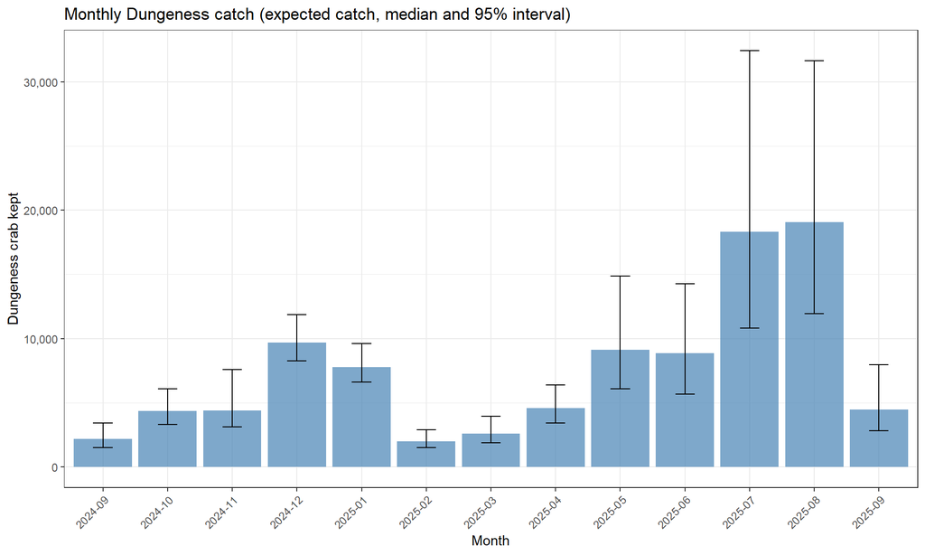

Monthly Dungeness catch with 95% intervals.

```r
# ---- 7.8 MONTHLY ESTIMATES ----
cat("\n", strrep("=",60), "\n MONTHLY ESTIMATES\n", strrep("=",60), "\n")

days_full <- prep_days_crab(params$est_date_start, params$est_date_end,
                            params, L_eff_model = L_eff_model)

month_lookup <- days_full |>
  mutate(month_label = format(event_date, "%Y-%m")) |>
  select(event_date, month_label)

all_months <- sort(unique(month_lookup$month_label))
monthly_C_draws <- matrix(0, nrow = n_draws_max, ncol = length(all_months),
                          dimnames = list(NULL, all_months))
monthly_E_draws <- matrix(0, nrow = n_draws_max, ncol = length(all_months),
                          dimnames = list(NULL, all_months))

for(cg in bss_catch_groups) {
  for(pop in c("shore","private_boat")) {
    for(ss in subseasons) {
      label <- paste0(pop, "_", ss$name, "_", cg)
      pe_label <- paste0(pop, "_", ss$name)
      b <- bss_all[[label]]

      days_ss <- prep_days_crab(ss$start, ss$end, params, L_eff_model = L_eff_model)
      days_ss$month_label <- format(days_ss$event_date, "%Y-%m")

      if(bss_use_pe_for(b)) {   # B1.8: PE if insufficient data OR failed scale-aware gate
        # B44 (2026-09-28): the PE's own strata, spread over their calendar days and summed
        # by month (pe_monthly_split.R). The months add up to the component totals exactly
        # and carry each cell's own CPUE; the effort-share split this replaced assumed one
        # CPUE for the whole sub-season and weighted months by their sampled days only.
        monthly_pe <- pe_monthly_split(pe_all[[pe_label]], days_ss, cg)

        for(m in monthly_pe$month_label) {
          if(m %in% all_months) {
            i_m <- monthly_pe$month_label == m
            monthly_C_draws[, m] <- monthly_C_draws[, m] + monthly_pe$month_catch[i_m]
            monthly_E_draws[, m] <- monthly_E_draws[, m] + monthly_pe$month_effort[i_m]
          }
        }
      } else {
        # Use C_expected (no Poisson noise) for monthly totals
        C_exp_bss <- rstan::extract(b$fit, "C_expected")$C_expected
        E_bss <- rstan::extract(b$fit, "E")$E
        n_fit_draws <- dim(C_exp_bss)[1]

        C_daily_mat <- C_exp_bss[,1,,1]
        E_daily_mat <- E_bss[,1,,1]

        for(m in unique(days_ss$month_label)) {
          day_idx <- which(days_ss$month_label == m)
          if(length(day_idx) == 0) next
          month_C <- if(length(day_idx)==1) C_daily_mat[, day_idx] else rowSums(C_daily_mat[, day_idx])
          month_E <- if(length(day_idx)==1) E_daily_mat[, day_idx] else rowSums(E_daily_mat[, day_idx])
          idx <- rep_len(1:n_fit_draws, n_draws_max)
          if(m %in% all_months) {
            monthly_C_draws[, m] <- monthly_C_draws[, m] + month_C[idx]
            monthly_E_draws[, m] <- monthly_E_draws[, m] + month_E[idx]
          }
        }
      }
    }
  }
}

# Add commercial/charter
if(!is.null(pe_all$comm_charter$daily_est)) {
  comm_daily <- pe_all$comm_charter$daily_est |>
    mutate(month_label = format(date, "%Y-%m"))
  comm_total <- pe_all$comm_charter$Dungeness_Kept
  total_sampled_dung <- sum(comm_daily$est_dung)
  if(total_sampled_dung > 0) {
    for(m in unique(comm_daily$month_label)) {
      if(m %in% all_months) {
        share <- sum(comm_daily$est_dung[comm_daily$month_label == m]) / total_sampled_dung
        monthly_C_draws[, m] <- monthly_C_draws[, m] + comm_total * share
      }
    }
  }
}

monthly_summary <- tibble(
  Month = all_months,
  BSS_Catch_median = apply(monthly_C_draws, 2, median),
  BSS_Catch_lo95   = apply(monthly_C_draws, 2, quantile, 0.025),
  BSS_Catch_hi95   = apply(monthly_C_draws, 2, quantile, 0.975),
  BSS_Effort_median = apply(monthly_E_draws, 2, median),
  BSS_Effort_lo95   = apply(monthly_E_draws, 2, quantile, 0.025),
  BSS_Effort_hi95   = apply(monthly_E_draws, 2, quantile, 0.975)
) |>
  mutate(across(where(is.numeric), round))

print(monthly_summary |> select(Month, BSS_Catch_median, BSS_Catch_lo95, BSS_Catch_hi95))
write.csv(monthly_summary, file.path(output_dir, "monthly_estimates.csv"), row.names = FALSE)

p_monthly <- monthly_summary |>
  mutate(Month = factor(Month, levels = all_months)) |>
  ggplot(aes(x = Month)) +
  geom_col(aes(y = BSS_Catch_median), fill = "steelblue", alpha = 0.7) +
  geom_errorbar(aes(ymin = BSS_Catch_lo95, ymax = BSS_Catch_hi95), width = 0.3) +
  scale_y_continuous(labels = scales::comma) +
  labs(title = "Monthly Dungeness catch (expected catch, median and 95% interval)",
       x = "Month", y = "Dungeness crab kept") +
  theme_bw() + theme(axis.text.x = element_text(angle = 45, hjust = 1))
ggsave(file.path(output_dir, "plot_monthly_catch.png"), p_monthly, width = 12, height = 6)


# ===========================================================================
```

### 8.1 Monthly catch by crabbing mode

The monthly trajectory by mode. Each fitted component contributes its posterior where it passed the gate; a component on PE contributes its PE point with a design-based effort SE, which omits the catch-rate uncertainty, so its interval here is a lower bound. The commercial/charter panel carries a per-vessel catch CV. This panel’s census uncertainty is therefore not the one the port total carries (the charter expansion SE); the two agree on the medians.

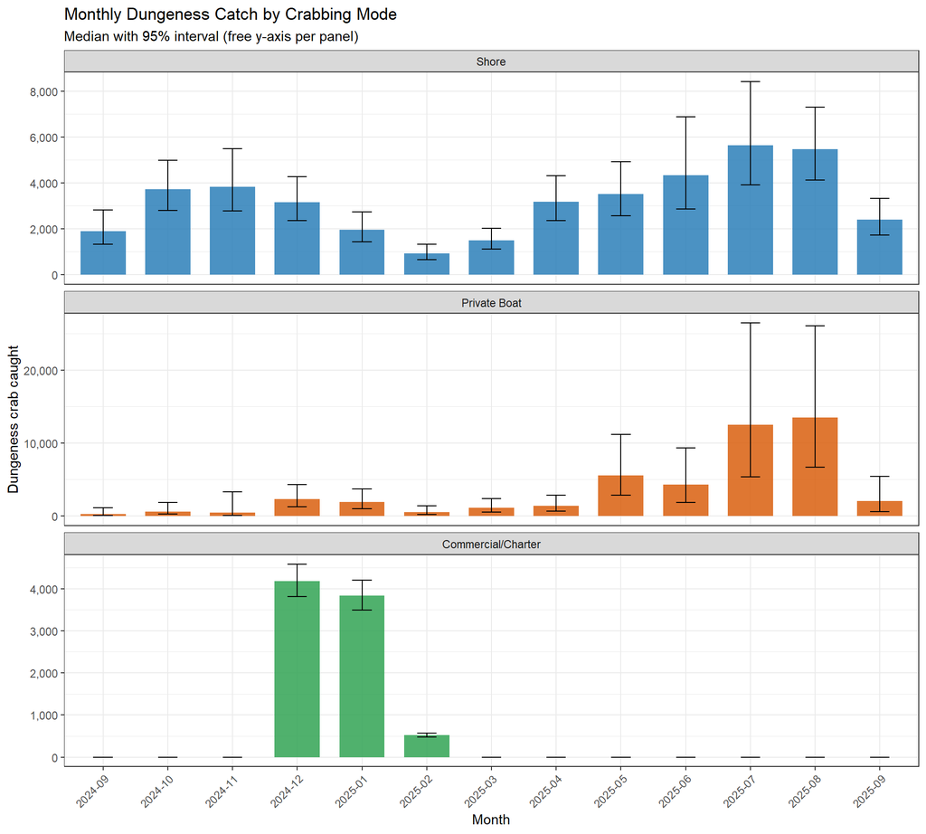

Monthly Dungeness catch by crabbing mode, median and 95% interval, each panel on its own scale. (The same figure with the modes side by side is plot_monthly_catch_by_mode.png.)

```r
# 7.8b MONTHLY ESTIMATES BY CRABBING MODE (with per-mode uncertainty)
# ===========================================================================
# Companion to plot_monthly_catch.png. Breaks the monthly Dungeness catch out by
# crabbing mode, each month with a 95% interval. The uncertainty source matches
# the method actually selected for each component (convergence_report / pe_vs_bss):
#   Shore  (BSS, both sub-seasons): full posterior. Monthly catch draws are summed
#          from the daily C_expected draws, then 2.5/50/97.5 quantiles.
#   Private Boat: method is per sub-season (v7.0 scale-aware gate, B1.8). On the
#          method-of-record data every fit passes the gate and uses its BSS posterior
#          (full daily C_expected draws). A component on PE instead spreads its PE
#          point over months from its own strata (pe_monthly_split.R, B44), then
#          applies a design-based relative SE (stratified effort
#          SE / effort total) as ONE per-component lognormal scale shared across
#          months, so the monthly catches move together and the boat total carries
#          that relative SE. NOTE: the PE branch captures effort sampling
#          uncertainty but NOT CPUE sampling uncertainty, so a PE sub-season's
#          interval is a lower bound; the BSS posterior is the fuller
#          characterization. Branch selection is driven by bss_use_pe_for(), so if a
#          component's gate verdict changes in a future run this block follows it
#          automatically.
#   Commercial/Charter (census): point distributed by sampled-harvest share with
#          a catch-per-vessel sampling CV as the relative SE (small, high coverage).
# The PE branch splits the component by month from the PE's own strata
# (pe_monthly_split.R, B44), the same helper 7.8 uses, so the two blocks cannot drift.
cat("\n", strrep("=",60), "\n MONTHLY ESTIMATES BY MODE\n", strrep("=",60), "\n")

modes_lvl <- c("Shore", "Private Boat", "Commercial/Charter")
mk_mat <- function() matrix(0, nrow = n_draws_max, ncol = length(all_months),
                            dimnames = list(NULL, all_months))
bymode_C <- setNames(lapply(modes_lvl, function(x) mk_mat()), modes_lvl)

# lognormal scale, mean 1, target relative SE (mean-preserving)
# B46 (2026-09-28): each call draws under its own seed (bss_seed + the call's index) with the
# caller's RNG restored. It used to draw from whatever state the port-total chunk's set.seed()
# had left, so it was reproducible only by accident, and not at all under census_uncertainty = "none".
.rln_k <- 0L
rln_scale <- function(n, rel_se) {
  .rln_k <<- .rln_k + 1L
  rel_se <- max(rel_se, 1e-4)
  sdlog  <- sqrt(log(1 + rel_se^2))
  bss_with_seed((params$bss_seed %||% 1L) + .rln_k, exp(stats::rnorm(n, -sdlog^2 / 2, sdlog)))
}

for(cg in bss_catch_groups) {
  for(pop in c("shore","private_boat")) {
    mode_nm <- if(pop == "shore") "Shore" else "Private Boat"
    for(ss in subseasons) {
      label    <- paste0(pop, "_", ss$name, "_", cg)
      pe_label <- paste0(pop, "_", ss$name)
      b <- bss_all[[label]]

      days_ss <- prep_days_crab(ss$start, ss$end, params, L_eff_model = L_eff_model)
      days_ss$month_label <- format(days_ss$event_date, "%Y-%m")

      if(bss_use_pe_for(b)) {   # B1.8: PE if insufficient data OR failed scale-aware gate
        # B44 (2026-09-28): the PE's own strata by month (pe_monthly_split.R), as in 7.8.
        monthly_pe <- pe_monthly_split(pe_all[[pe_label]], days_ss, cg)

        eff_total <- pe_all[[pe_label]]$effort_total %||% NA_real_
        eff_se    <- pe_all[[pe_label]]$effort_se %||% NA_real_
        rel_se <- if(!is.na(eff_total) && eff_total > 0 && !is.na(eff_se) && eff_se > 0)
                    eff_se / eff_total else {
                      bss_warn("monthly", sprintf("%s: no PE effort SE; the by-mode monthly panel uses a relative SE of 0.30.", pe_label), severity = "note"); 0.30 }
        scale_draws <- rln_scale(n_draws_max, rel_se)   # common effort-level uncertainty

        for(m in monthly_pe$month_label) {
          if(m %in% all_months) {
            bymode_C[[mode_nm]][, m] <- bymode_C[[mode_nm]][, m] +
              monthly_pe$month_catch[monthly_pe$month_label == m] * scale_draws
          }
        }
      } else {
        C_exp_bss   <- rstan::extract(b$fit, "C_expected")$C_expected
        n_fit_draws <- dim(C_exp_bss)[1]
        C_daily_mat <- C_exp_bss[,1,,1]
        for(m in unique(days_ss$month_label)) {
          day_idx <- which(days_ss$month_label == m)
          if(length(day_idx) == 0 || !(m %in% all_months)) next
          month_C <- if(length(day_idx)==1) C_daily_mat[, day_idx] else rowSums(C_daily_mat[, day_idx])
          idx <- rep_len(1:n_fit_draws, n_draws_max)
          bymode_C[[mode_nm]][, m] <- bymode_C[[mode_nm]][, m] + month_C[idx]
        }
      }
    }
  }
}

# Commercial/charter (census): distribute by sampled-harvest share, with a
# catch-per-vessel sampling CV as the relative SE (robust fallback if unavailable).
if(!is.null(pe_all$comm_charter$daily_est)) {
  comm_daily    <- pe_all$comm_charter$daily_est |> mutate(month_label = format(date, "%Y-%m"))
  comm_total    <- pe_all$comm_charter$Dungeness_Kept %||% 0
  total_sampled <- sum(comm_daily$est_dung)
  rel_se_comm <- tryCatch({
    cpv <- dwg$interview |> filter(population == "comm_charter") |> pull(dungeness_kept)
    cpv <- cpv[is.finite(cpv)]
    if(length(cpv) > 1 && mean(cpv) > 0) (sd(cpv) / sqrt(length(cpv))) / mean(cpv) else 0.12
  }, error = function(e) { bss_warn("monthly", "Commercial/charter per-vessel CV not computed; 0.12 used in the by-mode monthly panel.", severity = "note"); 0.12 })
  scale_comm <- rln_scale(n_draws_max, rel_se_comm)
  if(total_sampled > 0) {
    for(m in unique(comm_daily$month_label)) {
      if(m %in% all_months) {
        sh <- sum(comm_daily$est_dung[comm_daily$month_label == m]) / total_sampled
        bymode_C[["Commercial/Charter"]][, m] <- bymode_C[["Commercial/Charter"]][, m] + (comm_total * sh) * scale_comm
      }
    }
  }
}

monthly_bymode <- purrr::map_dfr(modes_lvl, function(md) {
  M <- bymode_C[[md]]
  tibble(
    Mode   = md,
    Month  = all_months,
    median = apply(M, 2, median),
    lo95   = apply(M, 2, quantile, probs = 0.025),
    hi95   = apply(M, 2, quantile, probs = 0.975)
  )
}) |>
  mutate(Mode  = factor(Mode, levels = modes_lvl),
         Month = factor(Month, levels = all_months),
         across(c(median, lo95, hi95), round))

print(monthly_bymode, n = nrow(monthly_bymode))
write.csv(monthly_bymode, file.path(output_dir, "monthly_estimates_by_mode.csv"), row.names = FALSE)

mode_cols <- c("Shore" = "#2c7fb8", "Private Boat" = "#d95f0e", "Commercial/Charter" = "#31a354")

# (1) Grouped (dodged) bars, one colour per mode, with 95% interval error bars.
p_bymode_dodge <- monthly_bymode |>
  ggplot(aes(x = Month, y = median, fill = Mode)) +
  geom_col(position = position_dodge(width = 0.8), width = 0.75, alpha = 0.85) +
  geom_errorbar(aes(ymin = lo95, ymax = hi95),
                position = position_dodge(width = 0.8), width = 0.3) +
  scale_fill_manual(values = mode_cols) +
  labs(title = "Monthly Dungeness Catch by Crabbing Mode",
       subtitle = "Median and 95% interval: BSS where the fit passed the gate, else the PE point with its effort SE;\ncommercial/charter with a per-vessel catch CV",
       x = "Month", y = "Dungeness crab caught", fill = "Mode") +
  theme_bw() +
  theme(axis.text.x = element_text(angle = 45, hjust = 1), legend.position = "top")
ggsave(file.path(output_dir, "plot_monthly_catch_by_mode.png"), p_bymode_dodge, width = 13, height = 6)

# (2) Faceted companion (free y) so shore and commercial panels stay readable
# next to the larger boat panel.
p_bymode_facet <- monthly_bymode |>
  ggplot(aes(x = Month, y = median, fill = Mode)) +
  geom_col(width = 0.7, alpha = 0.85) +
  geom_errorbar(aes(ymin = lo95, ymax = hi95), width = 0.3) +
  scale_fill_manual(values = mode_cols) +
  facet_wrap(~Mode, ncol = 1, scales = "free_y") +
  labs(title = "Monthly Dungeness Catch by Crabbing Mode",
       subtitle = "Median with 95% interval (free y-axis per panel)",
       x = "Month", y = "Dungeness crab caught") +
  theme_bw() +
  theme(axis.text.x = element_text(angle = 45, hjust = 1), legend.position = "none")
ggsave(file.path(output_dir, "plot_monthly_catch_by_mode_facet.png"), p_bymode_facet, width = 12, height = 9)


# ===========================================================================
```

## 9. Catch by crabbing mode

The total by crabbing mode, from the same draws as the port total: each mode sums its fitted components’ posterior draws (or PE points where a fit fell back), so the intervals are joint over the mode’s sub-seasons. The PE column is the design-based estimate for comparison. (Until 2026-09-29 this table showed the PE alone, which contradicted the headline.)

```r
# 7.9 CATCH BY CRABBING MODE
# ===========================================================================

cat("\n", strrep("=",60), "\n CATCH BY CRABBING MODE\n", strrep("=",60), "\n")

.mode_draws <- function(pop) {
  tot <- rep(0, n_draws_max)
  for (ss in subseasons) {
    b <- bss_all[[paste0(pop, "_", ss$name, "_Dungeness_Kept")]]
    tot <- tot + if (bss_use_pe_for(b)) (pe_all[[paste0(pop, "_", ss$name)]]$Dungeness_Kept %||% 0)
                 else b$C_exp_draws[rep_len(seq_along(b$C_exp_draws), n_draws_max)]
  }
  tot
}
.md <- list(shore = .mode_draws("shore"), boat = .mode_draws("private_boat"), cc = .cc_draws_by_cg[["Dungeness_Kept"]], port = port_C_draws)
.q <- function(x, p) as.numeric(stats::quantile(x, p))
mode_table <- tibble(
  Mode = c("Shore (Dock/Jetty/Beach)", "Private Boat", "Commercial/Charter", "PORT TOTAL"),
  BSS_median = vapply(.md, .q, numeric(1), p = 0.5),
  BSS_lo95   = vapply(.md, .q, numeric(1), p = 0.025),
  BSS_hi95   = vapply(.md, .q, numeric(1), p = 0.975),
  PE_Catch = c(
    pe_pop_sum("shore", "Dungeness_Kept"),
    pe_pop_sum("private_boat", "Dungeness_Kept"),
    pe_field("comm_charter", "Dungeness_Kept"), NA
  ),
  PE_Effort = c(
    pe_pop_sum("shore", "effort_total"),
    pe_pop_sum("private_boat", "effort_total"),
    pe_field("comm_charter", "effort_total"), NA
  )
)
mode_table$PE_Catch[4] <- sum(mode_table$PE_Catch[1:3], na.rm = TRUE)
mode_table$PE_Effort[4] <- sum(mode_table$PE_Effort[1:3], na.rm = TRUE)
print(mode_table |> mutate(across(where(is.numeric), round)))
write.csv(mode_table, file.path(output_dir, "catch_by_mode.csv"), row.names = FALSE)


# ===========================================================================
```

Season catch by crabbing mode (expected catch; BSS draws where the gate passed). Medians do not add to the port median.

| Mode | Catch | 95% interval | Share of port median | PE catch |
| --- | --- | --- | --- | --- |
| Shore (Dock/Jetty/Beach) | 42,042 | 42,042 [35,233, 50,465] | 42.1% | 42,086 |
| Private Boat | 48,818 | 48,818 [33,281, 72,429] | 48.9% | 38,133 |
| Commercial/Charter | 8,540 | 8,540 [8,396, 8,680] | 8.6% | 8,538 |
| PORT TOTAL | 99,822 | 99,822 [82,090, 124,718] | 100.0% | 88,758 |

### 9.1 Catch by gear type

In the pooled model the gear-type catch is an allocation after estimation: each population and sub-season’s total draws are split by the gear catch shares in that sub-season’s interviews, drawn by a **trip-level bootstrap** (crab arrive in trips, so the trip is the sampling unit; review item 6, 2026-09-08). Each gear therefore carries both sources of uncertainty. It is an apportionment of the pooled total, not a per-gear catch-rate model; commercial/charter catch is all pot by construction. The share intervals are in `gear_shares_bootstrap.csv`.

Season catch by gear type: trip-level bootstrap interview gear shares, per population and sub-season, times each component total (BSS draws or PE point). A “-” interval marks the point-allocation fallback.

| Gear | Catch | 95% interval | Share |
| --- | --- | --- | --- |
| Pot | 66,352 | 66,352 [51,141, 89,161] | 66.8% |
| Trap | 17,411 | 17,411 [14,454, 20,995] | 17.5% |
| Ring Net | 12,167 | 12,167 [9,637, 16,415] | 12.2% |
| Snare | 2,979 | 2,979 [2,264, 3,967] | 3.0% |
| Other | 434 | 434 [0, 1,621] | 0.4% |

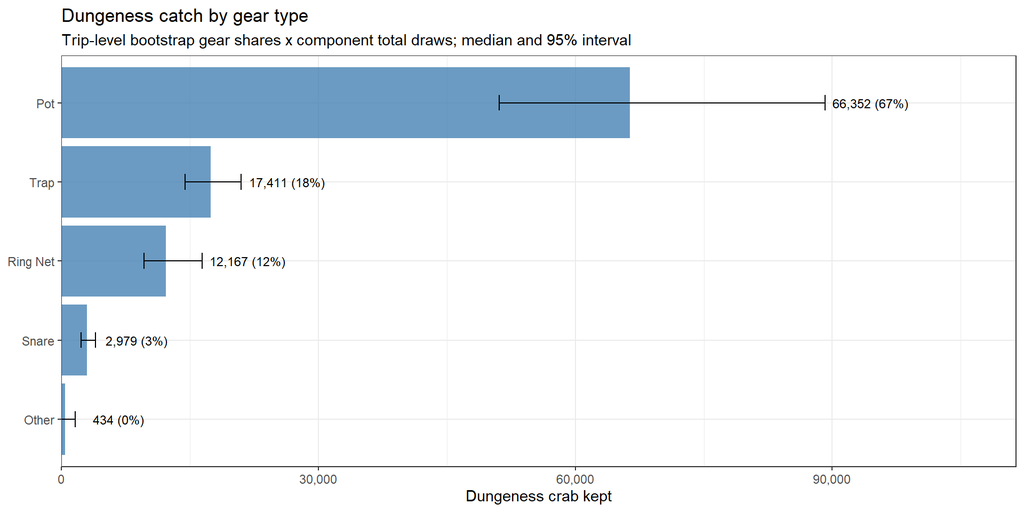

Catch by gear type, median and 95% interval.

```r
# 7.10 CATCH BY GEAR TYPE (trip-level bootstrap shares x component total draws)
#
# Pooled model: the gear split is an apportionment of each component's catch by the
# catch shares observed in that component's interviews. REVIEW ITEM 6 (2026-09-08)
# replaced two things at once:
#   (1) Dirichlet(catch counts + 0.5) -> a nonparametric TRIP-level bootstrap of the
#       shares. The Dirichlet treated every crab as an independent multinomial draw; crab
#       arrive in trips (one pot boat lands 25), so the effective sample size is the number
#       of trips and the old intervals were several times too narrow.
#   (2) one season-wide share vector per population -> shares PER population x sub-season,
#       applied to that sub-season's own total draws. The old pooling attributed "Pot" catch
#       to the pot-closure period, where pots are illegal.
# The helper lives in 03_R_functions/gear_share_bootstrap.R. Comm/charter is all Pot by
# construction (census). tryCatch falls back to a point allocation if a draw object is
# unavailable, so the section can never break the knit.
# ===========================================================================

cat("\n", strrep("=",60), "\n CATCH BY GEAR TYPE (bootstrap shares x totals)\n", strrep("=",60), "\n")

gear_levels <- gear_primary_levels

gear_int <- dwg$interview |>
  filter(population %in% c("shore","private_boat")) |>
  mutate(gear_primary = gear_primary_class(gear_type),
         catch = as.numeric(dungeness_kept))

# Observed (point) shares per population x sub-season, for the report and the fallback.
gear_props <- bind_rows(lapply(subseasons, function(ss) {
  gear_int |>
    filter(between(event_date, ss$start, ss$end)) |>
    group_by(population, gear_primary) |>
    summarise(total_catch = sum(catch, na.rm = TRUE), n_int = n(), .groups = "drop") |>
    group_by(population) |>
    mutate(prop_catch = if (sum(total_catch) > 0) total_catch / sum(total_catch) else NA_real_,
           subseason = ss$name) |>
    ungroup()
}))
cat("\n  Observed catch proportions by gear type (per sub-season):\n")
print(gear_props |> select(subseason, population, gear_primary, n_int, total_catch, prop_catch) |>
        mutate(prop_catch = round(prop_catch, 3)))

total_shore_catch <- pe_pop_sum("shore", "Dungeness_Kept")
total_boat_catch  <- pe_pop_sum("private_boat", "Dungeness_Kept")

# One component's total draws: its BSS expected-catch draws where the gate passed, the PE
# point otherwise (recycled to n_target so the bootstrap shares can multiply it).
gear_component_total_draws <- function(pop, ss_name, n_target) {
  lab <- paste0(pop, "_", ss_name, "_Dungeness_Kept")
  b   <- bss_all[[lab]]
  if (!is.null(b) && !bss_use_pe_for(b) && !is.null(b$C_exp_draws)) {
    d <- as.numeric(b$C_exp_draws)
    if (length(d) >= n_target) d[seq_len(n_target)] else bss_with_seed(params$bss_seed %||% 1L, sample(d, n_target, replace = TRUE))
  } else {
    rep(pe_all[[paste0(pop, "_", ss_name)]]$Dungeness_Kept %||% 0, n_target)
  }
}

gear_summary <- tryCatch({
  n_gd <- 4000
  per_gear <- matrix(0, n_gd, length(gear_levels), dimnames = list(NULL, gear_levels))
  gear_share_detail <- list()
  for (pop in c("shore", "private_boat")) {
    for (ss in subseasons) {
      iv <- gear_int |> filter(population == pop, between(event_date, ss$start, ss$end))
      shares <- gear_share_bootstrap(iv, n_boot = n_gd, levels = gear_levels,
                                     seed = params$bss_seed + match(pop, c("shore","private_boat")) * 1000 +
                                            match(ss$name, vapply(subseasons, `[[`, "", "name")))
      # A sub-season whose interviews carry no catch at all (or none) has undefined shares;
      # fall back to the population's season-wide point shares, and say so.
      if (all(is.na(shares))) {
        fb <- gear_share_point(gear_int |> filter(population == pop), gear_levels)
        if (all(is.na(fb))) fb <- setNames(c(1, 0, 0, 0, 0), gear_levels)
        shares <- matrix(fb, n_gd, length(gear_levels), byrow = TRUE, dimnames = list(NULL, gear_levels))
        bss_warn("gear split", sprintf("%s / %s has no catch-bearing interviews; its gear split uses the population's season-wide point shares.", pop, ss$name), severity = "note")
      } else if (anyNA(shares)) {
        # a rare replicate with zero total catch: replace it by the point shares
        pt <- gear_share_point(iv, gear_levels)
        shares[is.na(shares[, 1]), ] <- matrix(pt, sum(is.na(shares[, 1])), length(gear_levels), byrow = TRUE)
      }
      tot <- gear_component_total_draws(pop, ss$name, n_gd)
      per_gear <- per_gear + shares * tot
      gear_share_detail[[paste(pop, ss$name)]] <- tibble(
        population = pop, subseason = ss$name, n_interviews = nrow(iv),
        gear_primary = gear_levels,
        share_median = apply(shares, 2, median),
        share_lo95   = apply(shares, 2, quantile, 0.025),
        share_hi95   = apply(shares, 2, quantile, 0.975))
    }
  }
  per_gear[, "Pot"] <- per_gear[, "Pot"] + (pe_all$comm_charter$Dungeness_Kept %||% 0)
  write.csv(bind_rows(gear_share_detail), file.path(output_dir, "gear_shares_bootstrap.csv"), row.names = FALSE)
  tibble(
    gear_primary = gear_levels,
    Catch_median = round(apply(per_gear, 2, median)),
    lo95     = round(apply(per_gear, 2, quantile, 0.025)),
    hi95     = round(apply(per_gear, 2, quantile, 0.975))
  ) |>
    dplyr::mutate(Proportion = round(Catch_median / sum(Catch_median), 3)) |>
    dplyr::arrange(dplyr::desc(Catch_median))
}, error = function(e) {
  bss_warn("gear split", sprintf("Gear bootstrap propagation failed (%s); the gear table is a point allocation with no intervals.", conditionMessage(e)))
  ge <- gear_props |>
    group_by(population, gear_primary) |>
    summarise(total_catch = sum(total_catch), .groups = "drop") |>
    group_by(population) |> mutate(prop_catch = total_catch / sum(total_catch)) |> ungroup() |>
    mutate(pop_total = dplyr::case_when(population == "shore" ~ total_shore_catch,
                                        population == "private_boat" ~ total_boat_catch),
           est_catch = round(pop_total * prop_catch)) |>
    dplyr::select(gear_primary, est_catch)
  ge <- bind_rows(ge, tibble(gear_primary = "Pot",
                             est_catch = round(pe_all$comm_charter$Dungeness_Kept %||% 0)))
  ge |> group_by(gear_primary) |>
    summarise(Catch_median = sum(est_catch), .groups = "drop") |>
    mutate(lo95 = NA_real_, hi95 = NA_real_, Proportion = round(Catch_median / sum(Catch_median), 3)) |>
    arrange(desc(Catch_median))
})

cat("\n--- Catch by Gear Type (trip-level bootstrap shares x component totals) ---\n")
print(gear_summary)
write.csv(gear_summary, file.path(output_dir, "catch_by_gear_type.csv"), row.names = FALSE)

p_gear <- gear_summary |>
  dplyr::filter(Catch_median > 0 | !is.na(hi95) & hi95 > 0) |>
  mutate(gear_primary = fct_reorder(gear_primary, Catch_median),
         label_y = pmax(hi95, Catch_median, na.rm = TRUE)) |>
  ggplot(aes(x = gear_primary, y = Catch_median)) +
  geom_col(fill = "steelblue", alpha = 0.8) +
  geom_errorbar(aes(ymin = lo95, ymax = hi95), width = 0.2, na.rm = TRUE) +
  # labels sit PAST the interval, so they no longer print over the whiskers (2026-09-29)
  geom_text(aes(y = label_y, label = sprintf("%s (%.0f%%)", format(Catch_median, big.mark = ","), Proportion * 100)),
            hjust = -0.1, size = 3.2) +
  scale_y_continuous(labels = scales::comma, expand = expansion(mult = c(0, 0.25))) +
  labs(title = "Dungeness catch by gear type", subtitle = "Trip-level bootstrap gear shares x component total draws; median and 95% interval",
       x = NULL, y = "Dungeness crab kept") +
  theme_bw() + coord_flip()
ggsave(file.path(output_dir, "plot_catch_by_gear_type.png"), p_gear, width = 10, height = 6)
```

## 10. Per-fit BSS plots

For each fitted component: the daily effort and the daily expected catch (posterior median with the 95% interval), and the posterior of the component’s season totals. One tab per fit; each figure is also a PNG in the run folder.

### shore pot-closure

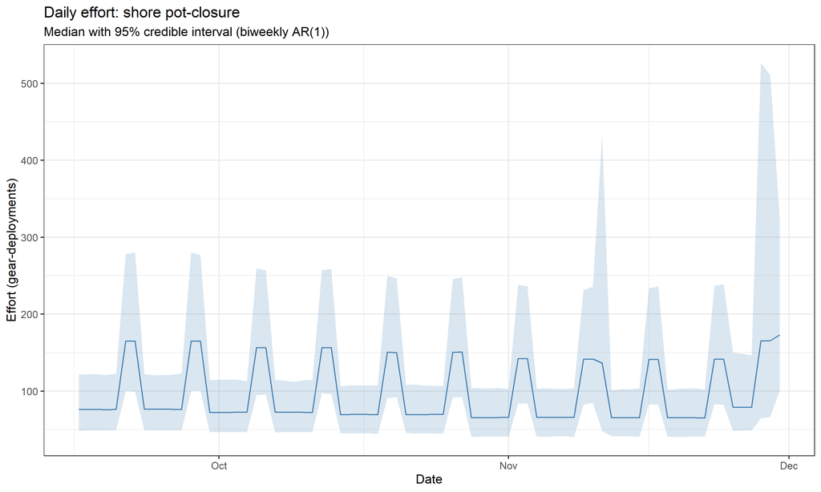

shore pot-closure: daily effort

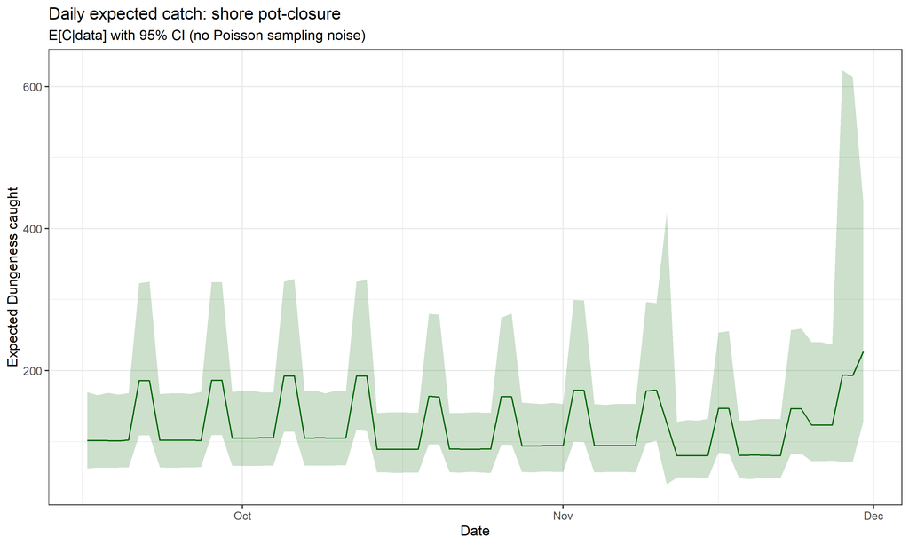

shore pot-closure: daily expected catch

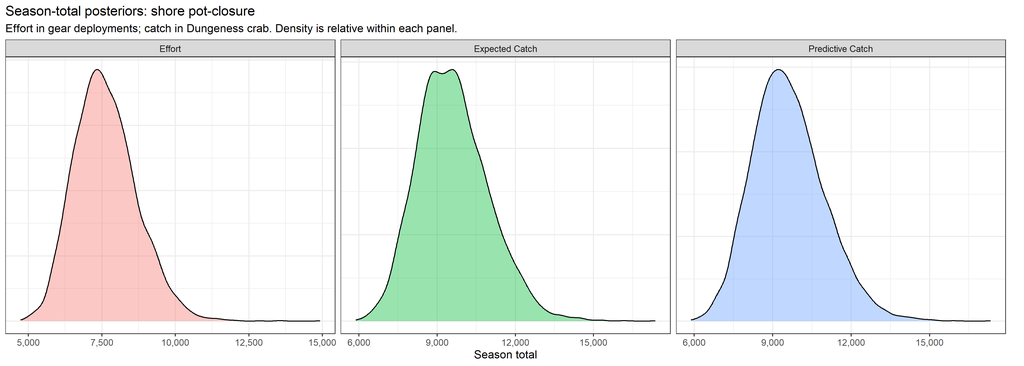

shore pot-closure: season-total posteriors

### shore all-gear

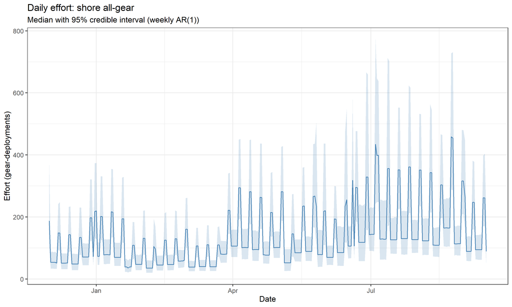

shore all-gear: daily effort

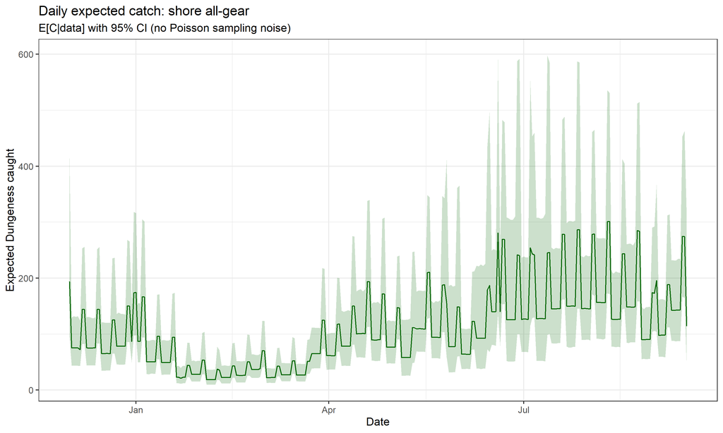

shore all-gear: daily expected catch

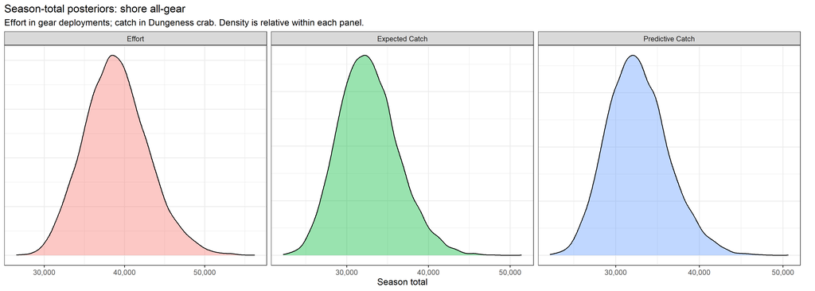

shore all-gear: season-total posteriors

### boat pot-closure

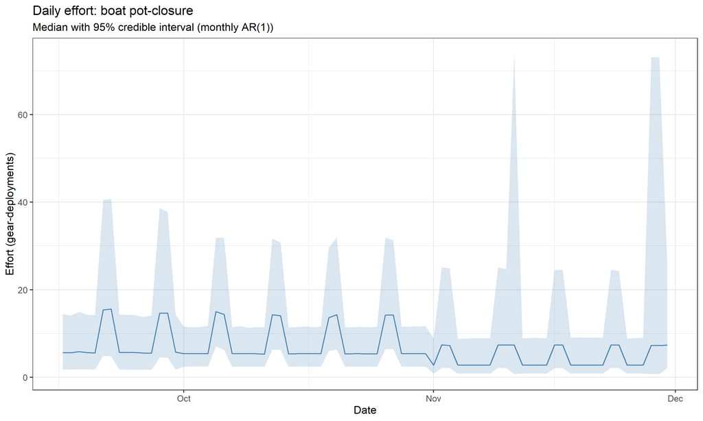

boat pot-closure: daily effort

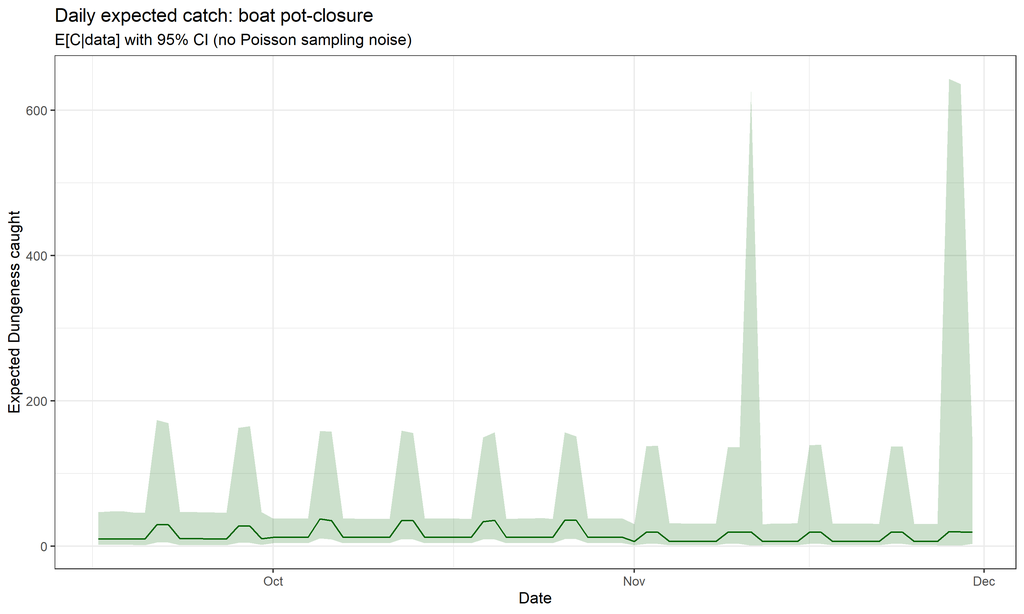

boat pot-closure: daily expected catch

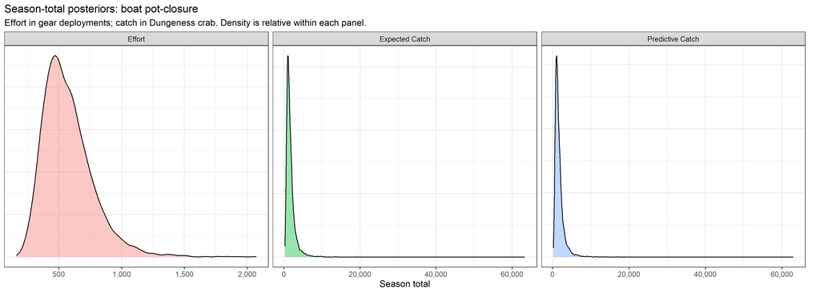

boat pot-closure: season-total posteriors

### boat all-gear

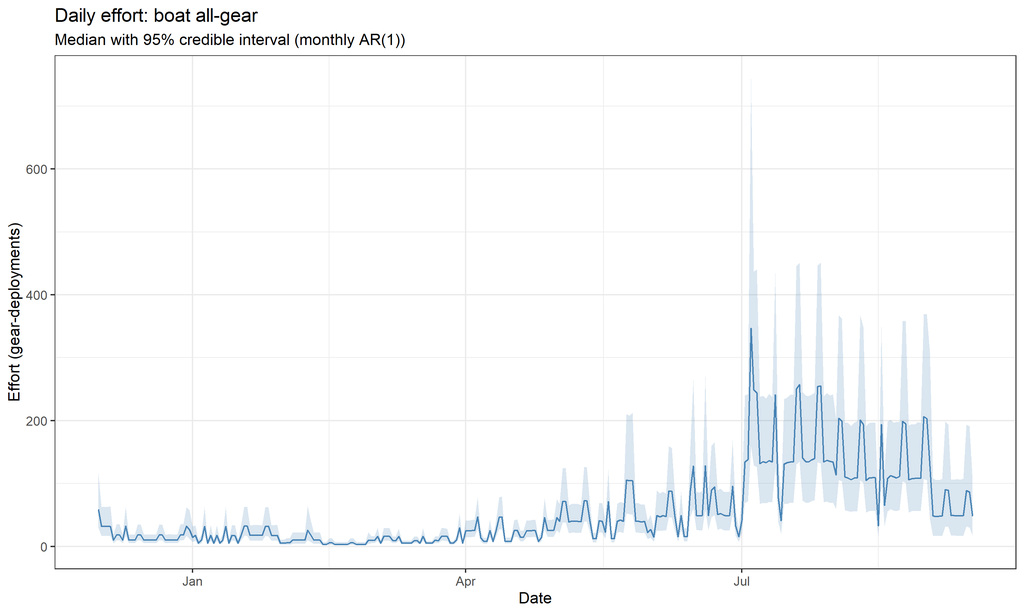

boat all-gear: daily effort

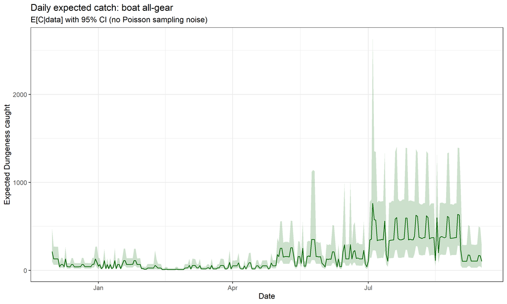

boat all-gear: daily expected catch

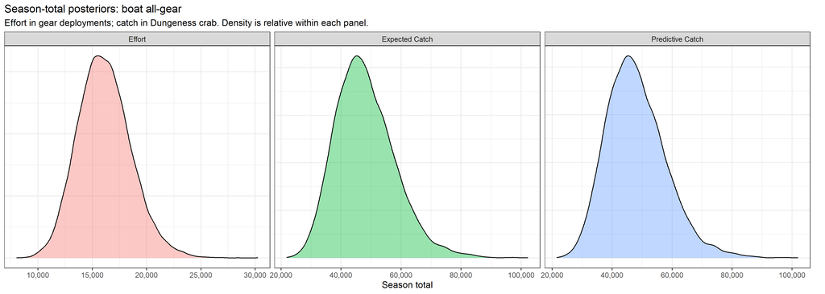

boat all-gear: season-total posteriors

## 11. Model diagnostics

The gate says whether the sampler worked; this section says whether the model carries the data. **Posterior-predictive calibration** (below) compares each observation with its predictive distribution: coverage near nominal and PIT histograms that are flat mean a calibrated stream; a hump means the predictive is too wide, a U too narrow. **Model adequacy** (11.5) summarises the flags per fit, **prior influence** (11.6) lists the parameters whose posterior is essentially the prior, and the **block cross-validation** (11.7) scores each effort stream on whole held-out weeks, the interpolation the model is actually used for.

```r
# ---- 7.12 PER-FIT MODEL DIAGNOSTICS (B1.6) ----
# Additive per-fit diagnostics: structural parameters, divergence localization,
# and posterior predictive calibration. write_bss_diagnostics() is sourced from
# 03_R_functions/model_diagnostics.R and is fully tryCatch-wrapped, so a diagnostic
# failure prints a note and never interrupts the run. Storing bss_data with each
# fit (Section 7) is what enables the PPC; without it the PPC is skipped cleanly.
cat("\n", strrep("=",60), "\n MODEL DIAGNOSTICS\n", strrep("=",60), "\n")
for(label in names(bss_all)) {
  b <- bss_all[[label]]
  if(is.null(b$fit)) next                  # PE-only entry: nothing to diagnose
  cat(sprintf("  %s:\n", label))
  # 2026-08-30: the gate verdict travels INTO the per-fit tables, so a parameter row lifted
  # out of a rejected fit's file carries that fact with it.
  write_bss_diagnostics(b$fit,
                        if(!is.null(b$bss_data)) b$bss_data else NULL,
                        label, output_dir,
                        fit_method = b$gate_info$method_selected %||%
                          (if (isTRUE(b$use_bss)) "BSS" else "PE (convergence fail)"))
  # 2026-09-04: persist the draws the PPC is computed from. Three separate defects in the
  # diagnostic arithmetic have each cost a full multi-hour re-fit to correct, most recently
  # the ZINB catch stream being scored as NB2. See 03_R_functions/save_bss_ppc_draws.R.
  if (isTRUE(params$save_ppc_draws) && !is.null(b$bss_data))
    save_bss_ppc_draws(b$fit, b$bss_data, label, output_dir,
                       max_draws = params$save_ppc_draws_max %||% NULL)
}
```

Posterior-predictive calibration by fit and data stream. Healthy: Cover 95% near 0.95 and PIT mean near 0.50; coverage well above nominal means the predictive is too wide (over-dispersed), the effort streams are the known case.

| Fit | Stream | Cover 50% | Cover 95% | PIT mean | PIT sd | n |
| --- | --- | --- | --- | --- | --- | --- |
| boat all-gear | trailer | 0.53 | 0.97 | 0.49 | 0.27 | 195 |
| boat all-gear | osp | 0.48 | 0.98 | 0.49 | 0.28 | 130 |
| boat all-gear | catch | 0.58 | 0.95 | 0.51 | 0.27 | 130 |
| boat pot-closure | trailer | 0.57 | 1.00 | 0.50 | 0.28 | 44 |
| boat pot-closure | osp | 0.56 | 0.94 | 0.51 | 0.25 | 18 |
| boat pot-closure | catch | 0.44 | 1.00 | 0.53 | 0.30 | 18 |
| shore all-gear | gear | 0.56 | 0.96 | 0.51 | 0.27 | 311 |
| shore all-gear | catch | 0.45 | 0.98 | 0.50 | 0.28 | 1,652 |
| shore pot-closure | gear | 0.56 | 0.98 | 0.52 | 0.27 | 52 |
| shore pot-closure | catch | 0.43 | 0.98 | 0.50 | 0.29 | 628 |

**PIT histograms, one per fit** (flat is calibrated):

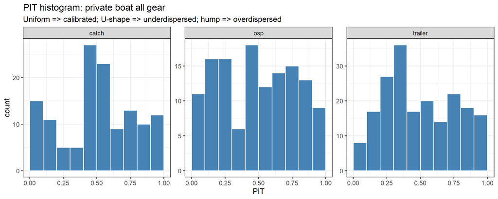

PIT histogram, boat all-gear

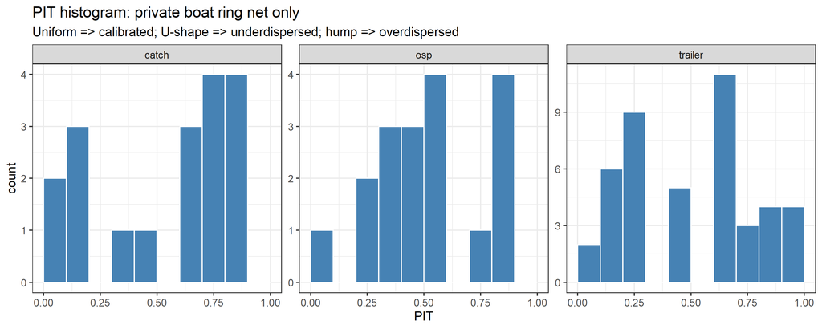

PIT histogram, boat pot-closure

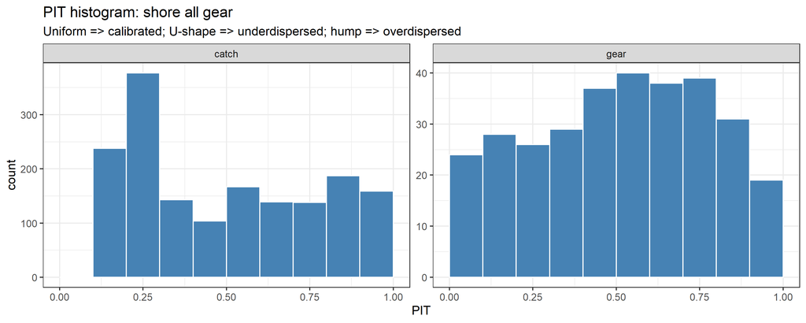

PIT histogram, shore all-gear

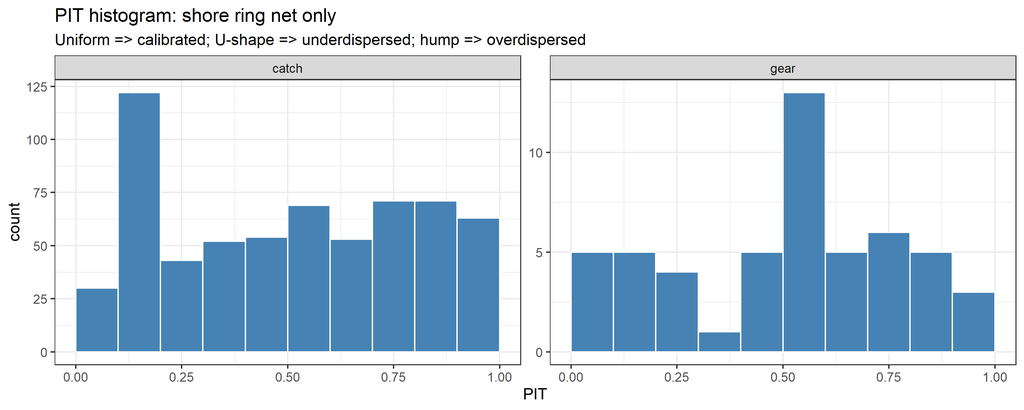

PIT histogram, shore pot-closure

### 11.1 Effort over-dispersion decomposition

Splits each effort-count predictive variance into its Poisson floor, negative-binomial observation over-dispersion, and latent-process parts, written per fit. It identifies which lever drives any excess effort variance before a prior or model change is considered.

```r
# ---- 7.13 EFFORT OVER-DISPERSION DECOMPOSITION (T1.5) ----
# Additive per-fit diagnostic. The v7.0 PPC showed the negative-binomial
# effort model is over-dispersed (gear/trailer PIT central humps, coverage_50
# ~ 0.63-0.75 vs the nominal 0.50); that says the effort predictive is too
# wide but not which part of the model to tune. This decomposes each effort-
# count predictive variance, by the law of total variance, into its Poisson
# floor E[mu], the NB observation over-dispersion E[mu^2/r_E] (the r_E /
# sigma_r_E lever), and the latent process variance Var(mu) (the sigma_eps_E /
# single-cell level lever), and reports their shares so the lever is identified
# before any prior or model change. write_effort_overdispersion_diag() is
# sourced from 03_R_functions/diagnose_effort_overdispersion.R and is fully
# tryCatch-wrapped; it writes only CSVs (effort_overdispersion_decomp_<label>
# and ..._byobs_<label>) and changes nothing in the model. It needs the in-
# memory fit and its bss_data (stored with each fit in Section 7), which is why
# it runs here in the fit session rather than from the saved summary CSVs.
cat("\n", strrep("=",60), "\n EFFORT OVER-DISPERSION DECOMPOSITION (T1.5)\n", strrep("=",60), "\n")
for(label in names(bss_all)) {
  b <- bss_all[[label]]
  if(is.null(b$fit)) next                  # PE-only entry: nothing to decompose
  write_effort_overdispersion_diag(b$fit,
                                   if(!is.null(b$bss_data)) b$bss_data else NULL,
                                   label, output_dir)
}
```

Effort-count predictive variance decomposition (shares sum to 1): Poisson floor, negative-binomial observation over-dispersion, and latent AR-process variance. The dominant share is the lever to tune if the effort predictive is too wide.

| Fit | Stream | Poisson | NB overdisp | Latent AR | Cover 50% |
| --- | --- | --- | --- | --- | --- |
| boat all-gear | trailer | 0.04 | 0.93 | 0.04 | 0.53 |
| boat pot-closure | trailer | 0.21 | 0.71 | 0.07 | 0.57 |
| shore all-gear | gear | 0.06 | 0.85 | 0.09 | 0.56 |
| shore pot-closure | gear | 0.06 | 0.79 | 0.14 | 0.56 |

### 11.2 Extended per-fit outputs and PSIS-LOO

The extended output series (parameter posteriors, AR paths, coverage maps, PPC residuals, sampler diagnostics, prior-vs-posterior tables) and PSIS-LOO cross-validation are written to the run folder for later analysis; nothing here changes an estimate.

```r
# ---- 7.13b EXTENDED RUN OUTPUTS (O1-O11) ----
# Additive persistence of in-memory quantities not previously saved, so the R
# workspace is rarely needed for later diagnosis. Per-fit (O1-O6, O8, O9): full
# parameter posterior summary, AR latent path, AR-period data coverage, modeled
# daily CPUE, per-observation PPC residuals (exact randomized PIT), HMC sampler
# diagnostics (E-BFMI), summed-quantity draws, prior-vs-posterior. Run-level (O7,
# O10, O11): monthly PE-vs-BSS by mode, gear proportions, per-fit data summary.
# Sourced from 03_R_functions/save_run_diagnostics.R; every writer is tryCatch-
# wrapped and writes only CSVs, so this changes no estimate. The fit objects
# (O12) are deliberately not saved, to avoid output/ bloat.
cat("\n", strrep("=",60), "\n EXTENDED RUN OUTPUTS (O1-O11)\n", strrep("=",60), "\n")
for(label in names(bss_all)) {
  b <- bss_all[[label]]
  if(is.null(b$fit)) next                  # PE-only entry: nothing to extract
  # 2026-08-27: pass the run seed so the diagnostic draw subsampling is reproducible
  # (see the note in save_run_diagnostics.R; the port total stays RNG-sensitive regardless).
  write_fit_extended_diagnostics(b$fit, b$bss_data, b$days_ss, label, output_dir,
                                 seed = params$bss_seed %||% 1L)
  write_loo_diagnostics(b$fit, b$bss_data, b$days_ss, label, output_dir)
  # 2026-09-26 (D31 -> B39): leave-one-WEEK-out PSIS block CV of the effort streams, the
  # interpolation test pointwise LOO cannot make. Writes loo_block_<stream>_<label>.csv;
  # tryCatch-wrapped per stream; changes no estimate (03_R_functions/bss_block_cv.R).
  write_block_cv_diagnostics(b$fit, b$bss_data, b$days_ss, label, output_dir)
  # POOL-5: CPUE estimator triad, saturation exponent, effort-linearity, and the
  # E/h unit assertion (03_R_functions/bss_cpue_diagnostics.R). Diagnostic-only:
  # writes cpue_estimators_/cpue_saturation_/cpue_linearity_<label>.csv and changes
  # no estimate. This is the check that surfaces a boat/shore effort-unit defect
  # (e.g. catch flat in soak time) the same way it did for gear-resolved. Wrapped
  # so a diagnostic error (or the unit assertion) can never abort the run.
  tryCatch(write_cpue_diagnostics(b, label, output_dir),
           error = function(e)
             cat(sprintf("  CPUE diagnostics skipped for %s: %s\n", label, conditionMessage(e))))
}
```

```r
write_run_level_diagnostics(bss_all, pe_all,
                            if(exists("gear_props")) gear_props else NULL,
                            params, output_dir)
# improvement-plan item 5.5 (2026-08-30): model ADEQUACY, reported beside the convergence
# gate rather than folded into it. The gate asks whether the sampler worked; this asks
# whether the model is carrying the data. It changes no selection. Runs after the per-fit
# LOO and PPC writers because it reads their output.
write_model_adequacy(bss_all, output_dir, params)
```

CPUE effort-unit validity. beta_h is the catch-vs-effort elasticity (harvest- unbiased when it covers 1, shown as ‘linear? = ok’); the model CPUE should track the design-based ratio-of-sums (RoS). ‘sat? = FLAG’ (catch sub-linear in soak time) is expected for pots and is the reason the unit is deployments, not hours.

| Fit | Unit | n | CPUE RoS | CPUE model | beta_h | linear? | sat beta | sat? |
| --- | --- | --- | --- | --- | --- | --- | --- | --- |
| boat all-gear | gear-deployments | 130 | 3.28 | 2.95 | 0.77 | ok | 0.24 | FLAG |
| boat pot-closure | gear-deployments | 18 | 2.12 | 2.55 | - | - | - | - |
| shore all-gear | gear-deployments | 1,652 | 0.87 | 0.84 | 1.04 | ok | 0.22 | FLAG |
| shore pot-closure | gear-deployments | 628 | 1.25 | 1.26 | 0.90 | ok | 0.27 | FLAG |

Per-fit data coverage: latent days, effort observations, interviews, and I/E observations, with the percent of days carrying any effort/interview data. Thin coverage is where the BSS leans hardest on the AR process and priors.

| Fit | Method | AR | Days | Eff obs | Interviews | I/E obs | % days eff | % days int |
| --- | --- | --- | --- | --- | --- | --- | --- | --- |
| shore pot-closure | BSS | biweekly | 76 | 52 | 628 | 0 | 68 | 67 |
| shore all-gear | BSS | weekly | 289 | 311 | 1,652 | 4 | 50 | 50 |
| boat pot-closure | BSS | monthly | 76 | 44 | 18 | 0 | 57 | 18 |
| boat all-gear | BSS | monthly | 289 | 195 | 130 | 0 | 50 | 23 |

PSIS-LOO by data stream. p_loo is the effective number of parameters; a large ‘Pareto k>0.7’ count means LOO is unreliable for that stream (the model is near- saturated there), so read its elpd_loo with caution.

| Fit | Stream | n | elpd_loo | p_loo | Pareto k>0.7 |
| --- | --- | --- | --- | --- | --- |
| boat all-gear | trailer | 195 | -551.3 | 8.7 | 0 |
| boat all-gear | osp | 130 | -580.6 | 12.5 | 1 |
| boat all-gear | catch | 130 | -447.2 | 9.8 | 1 |
| boat pot-closure | trailer | 44 | -87.0 | 3.8 | 0 |
| boat pot-closure | osp | 18 | -64.2 | 3.4 | 0 |
| boat pot-closure | catch | 18 | -54.8 | 3.2 | 1 |
| shore all-gear | gear | 311 | -1,368.4 | 28.3 | 0 |
| shore all-gear | catch | 1,652 | -3,157.3 | 27.5 | 0 |
| shore pot-closure | gear | 52 | -226.7 | 6.0 | 0 |
| shore pot-closure | catch | 628 | -1,439.4 | 8.1 | 0 |

### 11.3 Divergence localization

Where the divergent transitions (if any) concentrate. **Healthy:** small `|SMD|` across the board, meaning divergences are diffuse and not biasing any particular parameter or total.

Top divergence-localization drivers per fit (largest |SMD|). A large |SMD| is where divergent draws depart most from the bulk; it names the geometry to watch. Small values across the board mean divergences are diffuse, not biasing a total. Prior-only parameters (Section 11.6) are left out.

| Fit | Parameter | SMD | median (bulk) | median (div) |
| --- | --- | --- | --- | --- |
| boat pot-closure | sigma_r_C | 0.98 | 1.24 | 1.40 |
| boat pot-closure | r_C | -0.81 | 0.65 | 0.51 |
| boat pot-closure | sigma_eps_C | 0.65 | 0.42 | 0.67 |
| shore all-gear | phi_C | 1.67 | 0.67 | 0.99 |
| shore all-gear | R_G | -1.08 | 1.28 | 1.26 |
| shore all-gear | phi_E | -0.91 | 0.70 | 0.48 |
| shore pot-closure | phi_C | 1.01 | -0.22 | 0.32 |
| shore pot-closure | sigma_eps_E | 0.96 | 0.14 | 0.26 |
| shore pot-closure | phi_E | 0.93 | 0.10 | 0.61 |

### 11.4 Summer-extrapolation transparency (T1.1)

How much of each fitted component’s BSS catch falls on days with **no interview**, where the CPUE is imputed by the AR process and priors rather than observed. A high extrapolated share means that component’s harvest rests on the model filling unsampled time; it is the transparency counterpart to the summer-dominance caveat, and the place to be most cautious about the headline number. The share is computed from summed daily medians, so read it as a coverage diagnostic, not a re-estimate of the total.

Share of each fitted component’s BSS catch on days with no interview (CPUE imputed by the AR process). Across the fitted components, 66.2% of the summed BSS catch falls on extrapolated days. A high ‘% catch extrapolated’ flags a component whose harvest rests on the model filling unsampled time; shares use summed daily medians, so read as a coverage diagnostic, not a re-estimate of the total.

| Fit | days total | days sampled | catch total | catch extrapolated | % days sampled | % catch extrapolated |
| --- | --- | --- | --- | --- | --- | --- |
| boat all-gear | 289 | 67 | 44,010 | 34,996 | 23 | 79.5 |
| boat pot-closure | 76 | 14 | 1,134 | 897 | 18 | 79.1 |
| shore all-gear | 289 | 145 | 31,018 | 17,465 | 50 | 56.3 |
| shore pot-closure | 76 | 51 | 9,190 | 3,151 | 67 | 34.3 |

### 11.5 Model adequacy

Reported beside the gate, never gating it (`model_adequacy.csv`). **p_loo fraction**: the effective number of parameters as a share of the observations in the worst stream (high means the model is nearly memorising that stream). **Pareto k > 0.7**: observations whose leave-one-out estimate is unreliable. **PIT bias** and **coverage deviation**: how far the worst stream’s predictive calibration is from nominal. The flags summarise these against the thresholds in `bss_model_adequacy.R`.

Model adequacy per fit (model_adequacy.csv). A flag is a reason to read that fit’s streams with care, not a gate failure.

| Fit | p_loo fraction (worst stream) | Pareto k > 0.7 | PIT bias (worst) | 50% coverage deviation (worst) | Flags |
| --- | --- | --- | --- | --- | --- |
| shore pot-closure | 0.116 (gear) | 0 | 0.015 (gear) | 0.065 (catch) | none |
| shore all-gear | 0.091 (gear) | 0 | 0.012 (gear) | 0.059 (gear) | none |
| boat pot-closure | 0.179 (catch) | 1 | 0.033 (catch) | 0.068 (trailer) | LOO unreliable |
| boat all-gear | 0.075 (catch) | 1 | 0.010 (catch) | 0.077 (catch) | LOO unreliable |

### 11.6 Prior influence

Parameters whose posterior barely moved from the prior (`prior_influential` in `prior_vs_posterior_<fit>.csv`: contraction below the threshold in `save_run_diagnostics.R`), and parameters that enter no likelihood in a fit and so report their prior exactly (`decoupled` in `structural_params_<fit>.csv`). Neither is an estimate. A prior-influenced parameter that the total depends on (a turnover, for example) means that part of the total rests on the prior’s centre.

Parameters that report (mostly) their prior, per fit. Contraction is 1 - posterior SD / prior SD.

| Fit | Prior-influenced (contraction) | Prior only (enters no likelihood) |
| --- | --- | --- |
| boat all-gear | R_G (-0.00); phi_C (0.07); cfi_kappa[1] (0.01); sigma_c[1] (0.43); cfc_kappa[1] (0.16) | sigma_mu_E, sigma_mu_C, sigma_IE, gamma_C, kappa_OSP |
| boat pot-closure | R_G (0.00); phi_E (0.06); phi_C (0.04); B2 (0.02); B1_C (0.38); sigma_f[1] (0.22); cfi_kappa[1] (0.04); sigma_c[1] (0.01); cfc_kappa[1] (0.01) | sigma_mu_E, sigma_mu_C, sigma_IE, gamma_C, kappa_OSP |
| shore all-gear | R_G_boat (0.03); tau_bar[1] (0.10) | sigma_mu_E, sigma_mu_C, R_G_boat, gamma_C, kappa_OSP, sigma_r_OSP, r_OSP, f_crab, f_lower, sigma_f_out, cfi_kappa_out, combo_c_out, sigma_c_out, cfc_kappa_out |
| shore pot-closure | phi_E (0.03); phi_C (0.03); B2 (0.48); R_G_boat (0.00); tau_bar[1] (-0.01) | sigma_mu_E, sigma_mu_C, sigma_IE, R_G_boat, gamma_C, kappa_OSP, sigma_r_OSP, r_OSP, f_crab, f_lower, sigma_f_out, cfi_kappa_out, combo_c_out, sigma_c_out, cfc_kappa_out |

### 11.7 Leave-one-week-out cross-validation of the effort streams

Pointwise LOO scores single days, but the model’s job is to fill whole unsampled stretches. The block cross-validation (`loo_block_<stream>_<fit>.csv`, B39) leaves out each week in turn and scores the effort stream there by PSIS. A low reliable share (Pareto k > 0.7 on many weeks) means the week-level score cannot be trusted for that stream; where it is reliable, the elpd per observation is comparable between runs on the same data.

Leave-one-week-out PSIS cross-validation by fit and effort stream (the joint row leaves out every boat stream of the week together).

| Fit | Stream | Weeks | Observations | Reliable weeks | elpd (sum) | elpd per obs | worst Pareto k |
| --- | --- | --- | --- | --- | --- | --- | --- |
| boat all-gear | joint | 42 | 325 | 39 | -1,141.6 | -3.51 | 1.20 |
| boat all-gear | osp | 29 | 130 | 26 | -586.1 | -4.51 | 1.20 |
| boat all-gear | trailer | 37 | 195 | 35 | -558.0 | -2.86 | 1.20 |
| boat pot-closure | joint | 11 | 62 | 10 | -153.3 | -2.47 | 0.89 |
| boat pot-closure | osp | 5 | 18 | 4 | -65.0 | -3.61 | 0.89 |
| boat pot-closure | trailer | 11 | 44 | 10 | -88.4 | -2.01 | 0.89 |
| shore all-gear | gear | 38 | 311 | 15 | -1,376.0 | -4.42 | 0.95 |
| shore pot-closure | gear | 11 | 52 | 8 | -229.9 | -4.42 | 1.11 |

### 11.8 Sampler health

Per chain: divergent transitions, the mean and maximum tree depth, the step size and the energy Bayesian fraction of missing information (E-BFMI; below 0.3 means the sampler explored the tails poorly). Written to `sampler_diagnostics_<fit>.csv`.

Sampler health per fit, over its chains.

| Fit | Chains | Divergent | Mean treedepth | Max treedepth | Mean step size | Min E-BFMI | Low E-BFMI chains |
| --- | --- | --- | --- | --- | --- | --- | --- |
| boat all-gear | 4 | 0 | 8.2 | 9 | 0.02 | 0.89 | 0 |
| boat pot-closure | 4 | 13 | 6.0 | 7 | 0.06 | 0.89 | 0 |
| shore all-gear | 4 | 49 | 6.0 | 6 | 0.06 | 0.85 | 0 |
| shore pot-closure | 4 | 12 | 5.2 | 6 | 0.11 | 0.87 | 0 |

## 12. Effort and CPUE multipliers

The fitted day-type effects: how much more effort and how much higher a catch rate a weekend or holiday carries than a weekday, as multipliers with 95% intervals.

```r
# ---- 7.14 EFFORT & CPUE MULTIPLIERS ----
cat("\n", strrep("=",60), "\n EFFORT & CPUE MULTIPLIERS\n", strrep("=",60), "\n")

multiplier_results <- list()
for(label in names(bss_all)) {
  b <- bss_all[[label]]
  if(is.null(b$pe_fallback) || !b$pe_fallback) {
    B1_draws <- rstan::extract(b$fit, "B1")$B1
    B2_draws <- rstan::extract(b$fit, "B2")$B2
    B1C_draws <- rstan::extract(b$fit, "B1_C_out")$B1_C_out

    weekend_eff_mult <- exp(B1_draws)
    holiday_eff_mult <- exp(B1_draws + B2_draws)
    weekend_cpue_mult <- exp(B1C_draws)

    multiplier_results[[label]] <- tibble(
      fit = label,
      weekend_effort_mult = sprintf("%.2fx (%.2f-%.2f)",
        median(weekend_eff_mult), quantile(weekend_eff_mult, 0.025), quantile(weekend_eff_mult, 0.975)),
      holiday_effort_mult = sprintf("%.2fx (%.2f-%.2f)",
        median(holiday_eff_mult), quantile(holiday_eff_mult, 0.025), quantile(holiday_eff_mult, 0.975)),
      weekend_cpue_mult = sprintf("%.2fx (%.2f-%.2f)",
        median(weekend_cpue_mult), quantile(weekend_cpue_mult, 0.025), quantile(weekend_cpue_mult, 0.975)),
      B1_C_median = round(median(B1C_draws), 3),
      B1_C_lo95 = round(quantile(B1C_draws, 0.025), 3),
      B1_C_hi95 = round(quantile(B1C_draws, 0.975), 3)
    )
  }
}
if(length(multiplier_results) > 0) {
  multiplier_df <- bind_rows(multiplier_results)
  cat("\n  Multipliers relative to weekdays:\n")
  for(i in 1:nrow(multiplier_df)) {
    cat(sprintf("    %s:\n      Weekend effort: %s\n      Holiday effort: %s\n      Weekend CPUE: %s\n",
                multiplier_df$fit[i],
                multiplier_df$weekend_effort_mult[i],
                multiplier_df$holiday_effort_mult[i],
                multiplier_df$weekend_cpue_mult[i]))
  }
  write.csv(multiplier_df, file.path(output_dir, "effort_cpue_multipliers.csv"), row.names = FALSE)
}
```

Fitted multipliers relative to a weekday: median (95% interval).

| Fit | Weekend effort | Holiday effort | Weekend catch rate |
| --- | --- | --- | --- |
| shore pot-closure | 2.16x (1.55-3.03) | 2.06x (0.78-6.36) | 0.85x (0.73-0.98) |
| shore all-gear | 2.77x (2.44-3.15) | 3.00x (2.16-4.18) | 0.69x (0.60-0.80) |
| boat pot-closure | 2.66x (1.61-4.34) | 2.69x (0.35-20.33) | 1.11x (0.34-4.04) |
| boat all-gear | 1.84x (1.48-2.30) | 2.62x (1.65-4.35) | 0.90x (0.63-1.32) |

### 12.1 Expansion ratios (R_G and R_G_boat)

The gear-per-crabber ratio `R_G` (learned from the shore interviews) and the gear-per-boat-group ratio `R_G_boat` (learned from the boat interviews) that carry the counts onto the gear-deployment scale. Each ratio is declared in every fit but informed only in its own population’s fits; in the other it reports its prior and is marked PRIOR ONLY. The `R_G` prior centre is the season’s interview ratio unless `R_G_prior_mu` overrides it (the sensitivity sweep is `06_diagnostics/run_rg_sweep.R`).

```r
# ---- 7.16 R_G AND R_G_boat POSTERIORS ----
cat("\n", strrep("=",60), "\n EXPANSION RATIOS (R_G, R_G_boat)\n", strrep("=",60), "\n")

expansion_results <- list()
for(label in names(bss_all)) {
  b <- bss_all[[label]]
  if(is.null(b$pe_fallback) || !b$pe_fallback) {
    R_G_draws      <- rstan::extract(b$fit, "R_G")$R_G
    # POOL-1: R_T replaced by R_G_boat (gear per boat group). Both are always-present
    # parameters now; in the population where a ratio is unused it samples its prior.
    R_G_boat_draws <- rstan::extract(b$fit, "R_G_boat")$R_G_boat

    # 2026-08-30: R_G_boat is DECOUPLED in a shore fit. Both ratios are declared with proper
    # priors unconditionally, so a shore fit's R_G_boat samples its prior and prints as a
    # perfectly reasonable "4.02 gear/group (1.51-10.54)" beside the boat fits' genuine 3.55.
    # structural_params_*.csv has flagged this since 2026-08-27; this file did not, which is
    # how the 2026-08-29 review found the value being read as an estimate. The flag and a
    # suffix on the string, so it cannot be quoted by accident from either.
    .rgb_decoupled <- is.null(b$bss_data) ||
      ((b$bss_data$T_n %||% 0) == 0 && (b$bss_data$OSP_n %||% 0) == 0)
    # 2026-09-29: R_G is informed only by the shore gear interviews (IntA_gear), so in a boat fit
    # it is its prior too; that was reported as an estimate (1.25 [0.69, 2.27] on 2024-25).
    .rg_decoupled <- is.null(b$bss_data) || (b$bss_data$IntA_gear %||% 0) == 0
    expansion_results[[label]] <- tibble(
      fit = label,
      R_G_interpretation = sprintf("%.2f gear/crabber (%.2f-%.2f)%s",
        median(R_G_draws), quantile(R_G_draws, 0.025), quantile(R_G_draws, 0.975),
        if (.rg_decoupled) "  [PRIOR ONLY: no shore gear interviews in this fit]" else ""),
      R_G_boat_interpretation = sprintf("%.2f gear/group (%.2f-%.2f)%s",
        median(R_G_boat_draws), quantile(R_G_boat_draws, 0.025), quantile(R_G_boat_draws, 0.975),
        if (.rgb_decoupled) "  [PRIOR ONLY: no boat count stream in this fit]" else ""),
      R_G_boat_decoupled = .rgb_decoupled,
      R_G_decoupled = .rg_decoupled
    )
  }
}
if(length(expansion_results) > 0) {
  expansion_df <- bind_rows(expansion_results)
  for(i in 1:nrow(expansion_df)) {
    cat(sprintf("  %s: R_G=%s, R_G_boat=%s\n",
                expansion_df$fit[i], expansion_df$R_G_interpretation[i],
                expansion_df$R_G_boat_interpretation[i]))
  }
  write.csv(expansion_df, file.path(output_dir, "expansion_ratios.csv"), row.names = FALSE)
}
```

Expansion-ratio posteriors, median (95% interval). PRIOR ONLY marks a ratio no data in that fit informs.

| Fit | R_G (gear per crabber) | R_G_boat (gear per boat group) |
| --- | --- | --- |
| shore pot-closure | 1.32 gear/crabber (1.26-1.39) | 4.03 gear/group (1.48-10.75) [PRIOR ONLY: no boat count stream in this fit] |
| shore all-gear | 1.28 gear/crabber (1.25-1.32) | 4.01 gear/group (1.52-10.34) [PRIOR ONLY: no boat count stream in this fit] |
| boat pot-closure | 1.34 gear/crabber (0.76-2.39) [PRIOR ONLY: no shore gear interviews in this fit] | 2.94 gear/group (2.26-3.78) |
| boat all-gear | 1.25 gear/crabber (0.70-2.28) [PRIOR ONLY: no shore gear interviews in this fit] | 3.56 gear/group (3.24-3.90) |

### 12.2 Turnover as fitted

The season-level turnover `tau_bar` each fit estimated around the prior centre of Section 3.1. A posterior close to the prior (Section 11.6 flags it) means the component’s scale rests on the derived centre; the shore fits are the case to watch, because only the in-window I/E days inform them.

Fitted season-level turnover per fit, median (95% interval).

| Fit | Prior centre | tau_bar posterior | n_eff | R-hat |
| --- | --- | --- | --- | --- |
| boat all-gear | 3.030 | 3.102 [2.485, 3.860] | 15,484 | 1.000 |
| boat pot-closure | 3.030 | 2.856 [1.794, 4.677] | 8,014 | 1.000 |
| shore all-gear | 2.477 | 2.381 [1.980, 2.873] | 16,649 | 1.000 |
| shore pot-closure | 2.477 | 2.477 [2.029, 3.015] | 8,339 | 1.000 |

### 12.3 The crabbing fraction f

The share of private-boat effort that is crab-directed, a monthly logit random walk informed by the sampler’s boat contacts (and OSP’s crab-only share when delivered, as a lower bound through the combo share `c`). It multiplies the boat effort one for one, so a month with few contacts leans on its neighbours through the walk. From `crab_fraction_strata_<fit>.csv`.

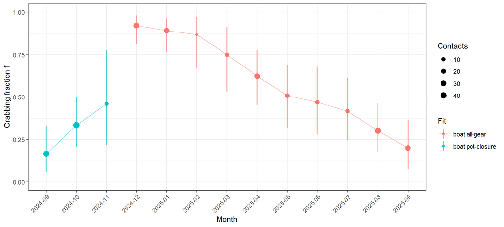

Crabbing fraction f by month (median and 95% interval) for each boat fit; point size is the number of boat contacts.

### 12.4 Effort day covariates as fitted

Every fit’s day-covariate block (`K_open`): which columns it carries, on how many of its days each column is set, and the fitted effect on the latent effort (`B_open_out`, with its rate ratio). Under the method of record (CHANGE_REGISTER A30) the private-boat all-gear fit carries the NWS Small-Craft-Advisory flag `nws_sca_any` and every other fit carries nothing (`marine_hazard_gear_regimes`, B42); an other-fishery opener column appears here only when `opener_covariate_mode` selects one. Section 3.4 shows the covariate’s pre-fit screen on the sampled days; this table is the fitted model. Written to `effort_day_covariates.csv`.

```r
# ---- 7.16b EFFORT DAY COVARIATES AS FITTED (2026-09-28, B43) ----
# Until 2026-09-28 the report showed the covariate's pre-fit screen and the configured scope,
# and never the fitted coefficient or which fits carried the column: the preps print that per
# fit, and the fit loop's chunk hides its output. bss_day_covariate_report.R builds the table
# from bss_all, so it is the fits that are reported, not the configuration.
day_cov_df <- tryCatch(bss_day_covariate_table(bss_all, params), error = function(e) {
  bss_warn("covariates", paste("Effort day covariate table not built:", conditionMessage(e)), severity = "note"); NULL })
if (!is.null(day_cov_df) && nrow(day_cov_df) > 0) {
  for (i in seq_len(nrow(day_cov_df)))
    cat(sprintf("  %s: %s%s\n", day_cov_df$fit[i], day_cov_df$covariate[i],
                if (is.na(day_cov_df$rate_ratio[i])) "" else sprintf(" on %d of %d days, rate ratio %s",
                  day_cov_df$days_flagged[i], day_cov_df$fit_days[i], day_cov_df$rate_ratio[i])))
  write.csv(day_cov_df, file.path(output_dir, "effort_day_covariates.csv"), row.names = FALSE)
}
```

Effort day covariates as fitted: per fit, the columns of the K_open block, the days each flags (column_sum is the column total, which differs for an imputed fractional column), and the posterior of its coefficient (rate ratio = exp(coefficient), the multiplier on latent effort on a flagged day).

| Fit | Covariate | Source | Days flagged | Column sum | Fit days | Coefficient | Rate ratio |
| --- | --- | --- | --- | --- | --- | --- | --- |
| shore pot-closure | (none) | - | - | - | 76 | - | - |
| shore all-gear | (none) | - | - | - | 289 | - | - |
| boat pot-closure | (none) | - | - | - | 76 | - | - |
| boat all-gear | nws_sca_any | marine hazard | 102 | 102 | 289 | -1.16 [-1.44, -0.88] | 0.31 (0.24-0.42) |

## 13. PE vs BSS comparison

The design-based PE and the Bayesian estimate for each component, on the same effort unit, so a gap is a genuine disagreement between the methods and not a unit artifact. Close agreement is reassuring; a large gap usually marks a data-thin component, where the PE’s thin-cell fills (Section 4) and the BSS’s AR process fill the unsampled days differently. `Totals use` says which one the port total carries.

```r
# ---- 7.17 PE VS BSS COMPARISON ----
cat("\n", strrep("=",60), "\n PE VS BSS COMPARISON\n", strrep("=",60), "\n")

comparison <- list()
for(pop in c("shore","private_boat")) {
  for(ss in subseasons) {
    label_cg <- paste0(pop, "_", ss$name, "_Dungeness_Kept")
    pe_label <- paste0(pop, "_", ss$name)
    b <- bss_all[[label_cg]]

    pe_catch <- pe_all[[pe_label]]$Dungeness_Kept %||% 0
    pe_effort <- pe_all[[pe_label]]$effort_total %||% 0

    if(!is.null(b) && (is.null(b$pe_fallback) || !b$pe_fallback)) {
      bss_catch <- b$C_expected_sum["50%"]
      bss_effort <- b$E_sum["50%"]
      catch_diff_pct <- round((bss_catch - pe_catch) / pe_catch * 100, 1)
      effort_diff_pct <- round((bss_effort - pe_effort) / pe_effort * 100, 1)
      conv <- convergence_df |> filter(fit == label_cg)
      method <- if(nrow(conv) > 0 && conv$pass_convergence[1]) "BSS" else "PE"
    } else {
      bss_catch <- NA; bss_effort <- NA
      catch_diff_pct <- NA; effort_diff_pct <- NA
      method <- "PE"
    }

    comparison[[length(comparison)+1]] <- tibble(
      component = paste0(pop, " (", ss$display_name, ")"),
      PE_effort = round(pe_effort), BSS_effort = round(bss_effort),
      effort_diff_pct = effort_diff_pct,
      PE_catch = round(pe_catch), BSS_catch = round(bss_catch),
      catch_diff_pct = catch_diff_pct,
      method_selected = method
    )
  }
}
comparison[[length(comparison)+1]] <- tibble(
  component = "comm_charter (census)",
  PE_effort = round(pe_all$comm_charter$effort_total), BSS_effort = NA, effort_diff_pct = NA,
  PE_catch = round(pe_all$comm_charter$Dungeness_Kept), BSS_catch = NA, catch_diff_pct = NA,
  # Review item 4 (2026-09-08/09): say what was observed and what the unsampled days are.
  # 2026-09-11: the two populations, two estimators, stated in the method column
  method_selected = local({ .c <- pe_all$comm_charter; sprintf(
    paste0("Commercial CENSUS %s (%s crab, %.0f vessel-trips on %d tally days, %d unsampled days %s; per-vessel mean over %d interviews SE %s) ",
           "+ Charter EXPANSION (%s frame%s, %s; %.0f trips, %d interviewed = %.0f%%, %s crab observed -> %s crab, SE %s). Carried into the port ",
           "interval: %s (census_uncertainty = '%s')"),
    if (identical(.c$census_expansion %||% "none", "none")) "(exact sum over the tally days)" else "(day-type stratified)",
    format(round(.c$commercial_dung %||% NA), big.mark = ","), .c$commercial_vessels %||% NA,
    sum(.c$daily_full$observed %||% NA), sum(!(.c$daily_full$observed %||% NA)),
    if (identical(.c$census_expansion %||% "none", "none")) "= no operation" else sprintf("imputed at %s", format(round(.c$imputed_dung %||% NA), big.mark = ",")),
    # 2026-09-29: the commercial per-vessel mean rests on the COMMERCIAL interviews; this read
    # charter_interviews (20 on 2024-25) where the count is commercial_interviews (141).
    .c$commercial_interviews %||% NA, format(round(.c$commercial_se %||% NA), big.mark = ","),
    .c$charter_frame %||% "tally",
    if ((.c$n_roster_only_days %||% 0L) > 0) sprintf(" incl. %s crab on %d day(s) with no tally", format(round(.c$charter_roster_dung %||% 0), big.mark = ","), .c$n_roster_only_days) else "",
    .c$charter_expansion %||% "pooled", .c$charter_trips %||% NA, .c$charter_interviews %||% NA,
    100 * (.c$charter_sampled_frac %||% NA_real_), format(round(.c$charter_observed_dung %||% NA), big.mark = ","),
    format(round(.c$charter_dung %||% NA), big.mark = ","), format(round(.c$charter_se %||% NA), big.mark = ","),
    format(round(.c$carried_se %||% 0), big.mark = ","), .c$census_uncertainty %||% "charter") })
)
comparison_df <- bind_rows(comparison)
# 2026-08-30: say explicitly whether the BSS column was USED.
# `method_selected` already recorded the gate verdict, but a rejected fit still leaves its
# BSS_catch sitting in the adjacent column with nothing marking it as unused. The
# 2026-08-29 gear run is the worked example: BSS_catch = 32,689 for private_boat (All gear)
# beside method_selected = "PE", while the port total correctly substituted the PE. A reader
# scanning the BSS column has no way to know. bss_reported answers it in one field.
comparison_df$bss_reported <- comparison_df$method_selected == "BSS"
print(comparison_df)
write.csv(comparison_df, file.path(output_dir, "pe_vs_bss_comparison.csv"), row.names = FALSE)
```

Point Estimator against the Bayesian estimate by component (BSS medians). Effort is in gear deployments; the census row in vessel-trips. ‘Totals use’ is the estimate the port total carries.

| Component | PE effort | BSS effort | Effort BSS vs PE (%) | PE catch | BSS catch | Catch BSS vs PE (%) | Totals use |
| --- | --- | --- | --- | --- | --- | --- | --- |
| Shore (Pot closure) | 7,328 | 7,547 | 3.0 | 9,126 | 9,505 | 4.2 | BSS |
| Shore (All gear) | 39,165 | 38,810 | -0.9 | 32,960 | 32,455 | -1.5 | BSS |
| Private boat (Pot closure) | 457 | 541 | 18.4 | 1,192 | 1,378 | 15.6 | BSS |
| Private boat (All gear) | 13,951 | 15,993 | 14.6 | 36,941 | 47,105 | 27.5 | BSS |
| Commercial/charter | 198 | - | - | 8,538 | - | - | Census + charter expansion |

**Commercial/charter component:** Commercial CENSUS (exact sum over the tally days) (6,405 crab, 164 vessel-trips on 47 tally days, 23 unsampled days = no operation; per-vessel mean over 141 interviews SE 123) + Charter EXPANSION (roster frame incl. 514 crab on 8 day(s) with no tally, vessel; 34 trips, 20 interviewed = 59%, 1,286 crab observed -> 2,133 crab, SE 73). Carried into the port interval: 73 (census_uncertainty = ‘charter’)

## 14. Run summary

The window, the sampling coverage, the interviews the fits used, and how many fits passed the gate.

```r
# ---- 7.18 SEASON SUMMARY ----
cat("\n", strrep("=",60), "\n SEASON SUMMARY\n", strrep("=",60), "\n")

season_days <- as.integer(as.Date(params$est_date_end) - as.Date(params$est_date_start) + 1)
total_effort_days <- n_distinct(c(dwg$shore_effort$event_date, dwg$boat_effort$event_date))
total_interview_n <- nrow(dwg$interview)
# 2026-09-29: the interviews the fits actually used (after the incomplete-trip and gear filters),
# beside the raw count of every interview in the window, which includes commercial/charter.
fitted_interview_n <- sum(vapply(bss_all, function(b) if (!is.null(b$bss_data)) as.numeric(b$bss_data$IntC %||% 0) else 0, numeric(1)))
n_bss_fits <- sum(!sapply(bss_all, function(b) !is.null(b$pe_fallback) && b$pe_fallback))
n_pass <- sum(convergence_df$pass_convergence, na.rm=TRUE)

cat(sprintf("\n  Season: %s to %s (%d days)\n", params$est_date_start, params$est_date_end, season_days))
cat(sprintf("  Effort days sampled: %d (%d%%)\n", total_effort_days, round(total_effort_days/season_days*100)))
cat(sprintf("  Total interviews: %d\n", total_interview_n))
cat(sprintf("  BSS convergence: %d of %d fits passed\n", n_pass, n_bss_fits))

season_summary <- tibble(
  metric = c("Model configuration", "Season start", "Season end", "Season days",
             "Effort days sampled", "Total interviews", "Interviews used by the fits", "BSS fits attempted", "BSS fits passed",
             "Day length", "AR temporal resolution"),
  # 2026-09-29: this driver IS the pooled model. It read the orchestrator's `model`, which is
  # "both" when the two models render in turn, so the table said "both CPUE".
  value = c(sprintf("%s CPUE; seasons %s; effort unit %s; AR %s; marine term %s", "pooled",
                    paste(params$season_filter, collapse = " + "), params$shore_effort_unit %||% "?",
                    if (is.null(params$ar_escalate) || isFALSE(params$ar_escalate)) "adaptive (capped)" else "escalation ladder (scoped)",
                    params$marine_hazard_mode %||% "off"),
            params$est_date_start, params$est_date_end,
            as.character(season_days), as.character(total_effort_days),
            format(total_interview_n, big.mark = ","), format(fitted_interview_n, big.mark = ","), as.character(n_bss_fits), as.character(n_pass),
            if (!bss_needs_day_length(params)) "not used (gear-deployment unit; the expansion is the turnover)"
            else if (!is.null(L_eff_model)) L_eff_model$method else "civil_twilight",
            paste(unique(na.omit(unlist(ar_resolutions))), collapse = ", "))
)
write.csv(season_summary, file.path(output_dir, "season_summary.csv"), row.names = FALSE)
```

Run summary. “Total interviews” counts every interview in the window, commercial/charter included; the fits use the filtered subset.

| Item | Value |
| --- | --- |
| Model configuration | pooled CPUE; seasons 2024-25; effort unit gear-deployments; AR adaptive (capped); marine term manual |
| Season start | 2024-09-16 |
| Season end | 2025-09-15 |
| Season days | 365 |
| Effort days sampled | 200 |
| Total interviews | 4,076 |
| Interviews used by the fits | 2,428 |
| BSS fits attempted | 4 |
| BSS fits passed | 4 |
| Day length | not used (gear-deployment unit; the expansion is the turnover) |
| AR temporal resolution | biweekly, weekly, monthly |

## 15. Run parameters, timing and software

The full parameters are written to `run_parameters.txt` and the R session to `session_info.txt`; the tables below give the wall-clock by section and the software that produced this run.

```r
# ---- 7.19 SAVE PARAMETERS ----
timer_stop("6_outputs")
# 2026-09-04 DEFECT FIX. This was `str(params)` with its defaults, and str() truncates a
# list at list.len = 99 entries with a "[list output truncated]" line. run_config carries 120
# keys, so EVERY run_parameters.txt in this repo before this date is missing about 21 of
# them, silently. That file is not decoration: config_delta() in the batch runners compares
# two runs key by key from it, and annotate_decoupled_run.R reads run flags out of it. A
# truncated dump gives that machinery false POSITIVES (a key that scrolled off one side of a
# comparison reads as "differs") and, far worse, false NEGATIVES (a key that genuinely
# differs but sits past entry 99 in both dumps is never compared at all). The 2026-09-03 Z0
# stage reported 9 UNEXPECTED config keys on a run whose config was in fact correct; all 9
# were keys that crossed the truncation boundary when new keys were added above them.
# list.len is set well above the key count and nchar.max is raised so long vectors are not
# elided either.
writeLines(capture.output(str(params, list.len = 1000, nchar.max = 2000, vec.len = 100)),
           file.path(output_dir, "run_parameters.txt"))

# B1.6: session and version capture for reproducibility. Pins package and Stan
# versions and the seed with each output set, so a result is reproducible from
# the committed artifacts.
writeLines(capture.output(sessionInfo()), file.path(output_dir, "session_info.txt"))
cat(sprintf("\nrstan %s; StanHeaders %s; bss_seed %s\n",
            utils::packageVersion("rstan"),
            utils::packageVersion("StanHeaders"),
            params$bss_seed),
    file = file.path(output_dir, "session_info.txt"), append = TRUE)

cat(sprintf("\nAll outputs saved to: %s\n", output_dir))
cat(paste(" ", list.files(output_dir), collapse="\n"), "\n")

# ---- TIMING SUMMARY ----
run_total <- difftime(Sys.time(), run_start_time, units = "mins")
cat("\n", strrep("=",60), "\n TIMING SUMMARY\n", strrep("=",60), "\n")
timing_df <- tibble(
  Section = names(bss_timer_log()),
  Minutes = sapply(bss_timer_log(), function(x) round(as.numeric(x$elapsed), 1))
)
print(timing_df, n = 20)
# 2026-09-05: persist it. Per-fit wall-clock by AR resolution is what a batch runtime
# estimate is built from, and until now it existed only as console output inside a
# results='hide' chunk, so the 2026-09-05 pre-run audit had to scrape the gear HTML for it.
utils::write.csv(timing_df, file.path(output_dir, "run_timings.csv"), row.names = FALSE)
cat(sprintf("\n  TOTAL RUNTIME: %.1f minutes (%.1f hours)\n",
            as.numeric(run_total), as.numeric(run_total)/60))

# save.image(file = file.path(output_dir, "BSS-GH-pooled-CPUE-model_workspace.RData"))
```

Wall-clock minutes by section; total 247.7 minutes.

| Section | Minutes |
| --- | --- |
| 1_load_data | 0.1 |
| 2_diagnostic_plots | 0.1 |
| 2b_fishery_spillover | 0.0 |
| 3_PE_estimates | 0.0 |
| 4_commercial_charter | 0.0 |
| 5_BSS_model_runs | 244.9 |
| fit: shore_ring_net_only (attempt 1) | 10.8 |
| fit: shore_all_gear (attempt 1) | 34.7 |
| fit: private_boat_ring_net_only (attempt 1) | 67.1 |
| fit: private_boat_all_gear (attempt 1) | 123.4 |
| 6_outputs | 2.4 |

Software and reproducibility. A render of the same code, data and configuration on the same platform reproduces this run’s draws.

| Item | Value |
| --- | --- |
| R | R version 4.2.2 (2022-10-31 ucrt) |
| rstan | 2.32.7 |
| StanHeaders | 2.32.10 |
| Platform | x86_64-w64-mingw32/x64 (64-bit) |
| Code (git) | 2523e8e (uncommitted changes) |
| Seed / init_r | 20260619 / 0.5 |

## 16. Run warnings and notes

Every condition this run recorded, in one place: fallbacks (a turnover prior centred on its fallback, a component on its PE), skipped diagnostics, census frame conditions, and every R warning and message a step raised. **Warnings** can affect a number and should be read before citing the estimate; **notes** record a choice or a missing optional input. Written to `run_warnings.csv`. An empty table means the run recorded nothing.

Run warnings (6) and notes (7), each listed once with the number of times it was raised.

| Severity | Source | Message | Times |
| --- | --- | --- | --- |
| warning | R warning (chunk bss-fits) | Examine the pairs() plot to diagnose sampling problems | 3 |
| warning | R warning (chunk bss-fits) | There were 12 divergent transitions after warmup. See https://mc-stan.org/misc/warnings.html#divergent-transitions-after-warmup to find out why this is a problem and how to eliminate them. | 1 |
| warning | R warning (chunk bss-fits) | There were 13 divergent transitions after warmup. See https://mc-stan.org/misc/warnings.html#divergent-transitions-after-warmup to find out why this is a problem and how to eliminate them. | 1 |
| warning | R warning (chunk bss-fits) | There were 49 divergent transitions after warmup. See https://mc-stan.org/misc/warnings.html#divergent-transitions-after-warmup to find out why this is a problem and how to eliminate them. | 1 |
| warning | R warning (chunk diag-extended) | Some Pareto k diagnostic values are too high. See help(‘pareto-k-diagnostic’) for details. | 3 |
| warning | R warning (chunk input-figures) | Calling `case_when()` with size 1 LHS inputs and size >1 RHS inputs was deprecated in dplyr 1.2.0. ℹ This `case_when()` statement can result in subtle silent bugs and is very inefficient. Please use a… | 1 |
| note | I/E | I/E stream dropped for shore/pot_closure: 2 in-window obs < ie_min_obs_shore = 3; sigma_IE left decoupled (GR-8 guard). | 1 |
| note | census | FRAMES DISAGREE on 6 tally day(s): the vessel tally and the charter roster give different trip counts. The larger of the two is used. See roster_reconciliation in census_roster_reconciliation.csv. | 1 |
| note | census | ROSTER-ONLY DAYS: 8 charter trip(s) on 8 day(s) with no vessel tally. They are in the frame because charter_frame = ‘roster’ unions the roster with the tally; a tally-only frame would carry 0 crab on … | 1 |
| note | census | UNSAMPLED DAYS TREATED AS NO OPERATION: 23 calendar day(s) in the census window have no tally row, and census_expansion = ‘none’ records them as days on which no vessel operated rather than imputing t… | 1 |
| note | openers | Spillover diagnostic: Bottomfish is open most of the year (near-constant), and salmon is open only in summer (near-collinear with month); read those adjusted estimates with care. | 1 |
| note | openers | Spillover diagnostic: Nearby-dig vs any-dig agree on 197 of 197 sampled shore days (differ on 0); when 0, the nearby flag is not separable from a generic dig day this season. | 1 |
| note | openers | Spillover diagnostic: Opener OPEN-day counts in the sampled shore-effort series: salmon 33, halibut 23, bottomfish 103, nearby dig 69 (of 197 sampled days). | 1 |

## Appendix B: Other-fishery opener spillover

A hypothesis test, not a model change: do other coastal fishery openers (Marine Area 2 finfish, coastal razor-clam digs near Grays Harbor) pull crab effort or catch rate onto or off opener days beyond what the day type and the month already explain? The **adjusted** table is the test: the opener’s coefficient in `lm(response ~ day_type + month + opener)`. It feeds the opener screen in Section 3.3 and changes no estimate by itself.

Raw comparison: mean crab effort (daily counts) and CPUE (Dungeness per gear deployment) on other-fishery opener days vs other days. These are confounded with day-type and season; read the adjusted table below for the marginal effect.

| Series | Opener | n (opener) | Mean (opener) | n (other) | Mean (other) | Raw diff | Raw % | t-test p |
| --- | --- | --- | --- | --- | --- | --- | --- | --- |
| Shore gear (effort) | MA2 salmon open | 33 | 209.58 | 164 | 66.70 | 142.87 | 214 | < 1e-04 |
| Shore gear (effort) | MA2 halibut open | 23 | 167.78 | 174 | 80.44 | 87.35 | 109 | 0.00032 |
| Shore gear (effort) | MA2 bottomfish open | 103 | 141.51 | 94 | 34.88 | 106.63 | 306 | < 1e-04 |
| Shore gear (effort) | Razor dig (nearby beaches) | 69 | 75.26 | 128 | 98.92 | -23.66 | -24 | 0.07843 |
| Boat trailers (effort) | MA2 salmon open | 32 | 61.38 | 154 | 3.87 | 57.50 | 1,486 | < 1e-04 |
| Boat trailers (effort) | MA2 halibut open | 22 | 61.32 | 164 | 7.38 | 53.93 | 730 | < 1e-04 |
| Boat trailers (effort) | MA2 bottomfish open | 100 | 24.65 | 86 | 1.10 | 23.55 | 2,131 | < 1e-04 |
| Boat trailers (effort) | Razor dig (nearby beaches) | 64 | 3.88 | 122 | 18.95 | -15.08 | -80 | < 1e-04 |
| Shore CPUE | MA2 salmon open | 916 | 0.80 | 2,815 | 0.85 | -0.05 | -6 | 0.24143 |
| Shore CPUE | MA2 halibut open | 548 | 0.87 | 3,183 | 0.83 | 0.04 | 5 | 0.44921 |
| Shore CPUE | MA2 bottomfish open | 2,311 | 0.82 | 1,420 | 0.87 | -0.05 | -6 | 0.14901 |
| Shore CPUE | Razor dig (nearby beaches) | 1,417 | 0.87 | 2,314 | 0.82 | 0.04 | 5 | 0.24097 |
| Boat CPUE | MA2 salmon open | 38 | 2.06 | 142 | 3.02 | -0.95 | -32 | 0.03695 |
| Boat CPUE | MA2 halibut open | 21 | 2.71 | 159 | 2.83 | -0.12 | -4 | 0.87858 |
| Boat CPUE | MA2 bottomfish open | 87 | 2.18 | 93 | 3.41 | -1.22 | -36 | 0.00365 |
| Boat CPUE | Razor dig (nearby beaches) | 66 | 3.33 | 114 | 2.52 | 0.81 | 32 | 0.08439 |

Adjusted association: the opener coefficient in lm(response ~ day-type + month + opener), the marginal effect after removing the weekend and monthly signal the model already captures. Positive = more effort/CPUE on opener days. A blank estimate with a Note means the opener could not be separated from day-type/month in this season.

| Series | Opener | Adj. estimate | SE | 95% CI | p | Note |
| --- | --- | --- | --- | --- | --- | --- |
| Shore gear (effort) | MA2 salmon open | -3.34 | 62.67 | [-126.2, 119.5] | 0.958 |  |
| Shore gear (effort) | MA2 halibut open | 17.54 | 19.33 | [-20.3, 55.4] | 0.365 |  |
| Shore gear (effort) | MA2 bottomfish open | 28.33 | 18.65 | [-8.2, 64.9] | 0.130 |  |
| Shore gear (effort) | Razor dig (nearby beaches) | 21.50 | 9.26 | [3.3, 39.6] | 0.021 |  |
| Boat trailers (effort) | MA2 salmon open | -10.77 | 22.06 | [-54.0, 32.5] | 0.626 |  |
| Boat trailers (effort) | MA2 halibut open | 29.39 | 6.56 | [16.5, 42.2] | <1e-04 |  |
| Boat trailers (effort) | MA2 bottomfish open | 1.50 | 7.17 | [-12.6, 15.6] | 0.835 |  |
| Boat trailers (effort) | Razor dig (nearby beaches) | 1.00 | 3.40 | [-5.7, 7.7] | 0.770 |  |
| Shore CPUE | MA2 salmon open | 0.57 | 0.22 | [0.1, 1.0] | 0.010 |  |
| Shore CPUE | MA2 halibut open | -0.06 | 0.07 | [-0.2, 0.1] | 0.423 |  |
| Shore CPUE | MA2 bottomfish open | 0.03 | 0.10 | [-0.2, 0.2] | 0.725 |  |
| Shore CPUE | Razor dig (nearby beaches) | 0.01 | 0.04 | [-0.1, 0.1] | 0.737 |  |
| Boat CPUE | MA2 salmon open | -1.00 | 2.96 | [-6.8, 4.8] | 0.736 |  |
| Boat CPUE | MA2 halibut open | 0.27 | 0.97 | [-1.6, 2.2] | 0.781 |  |
| Boat CPUE | MA2 bottomfish open | 1.77 | 1.41 | [-1.0, 4.5] | 0.211 |  |
| Boat CPUE | Razor dig (nearby beaches) | 0.01 | 0.54 | [-1.0, 1.1] | 0.989 |  |

**Identifiability notes (read before interpreting):**

- Nearby-dig vs any-dig agree on 197 of 197 sampled shore days (differ on 0); when 0, the nearby flag is not separable from a generic dig day this season.
- Opener OPEN-day counts in the sampled shore-effort series: salmon 33, halibut 23, bottomfish 103, nearby dig 69 (of 197 sampled days).
- Bottomfish is open most of the year (near-constant), and salmon is open only in summer (near-collinear with month); read those adjusted estimates with care.

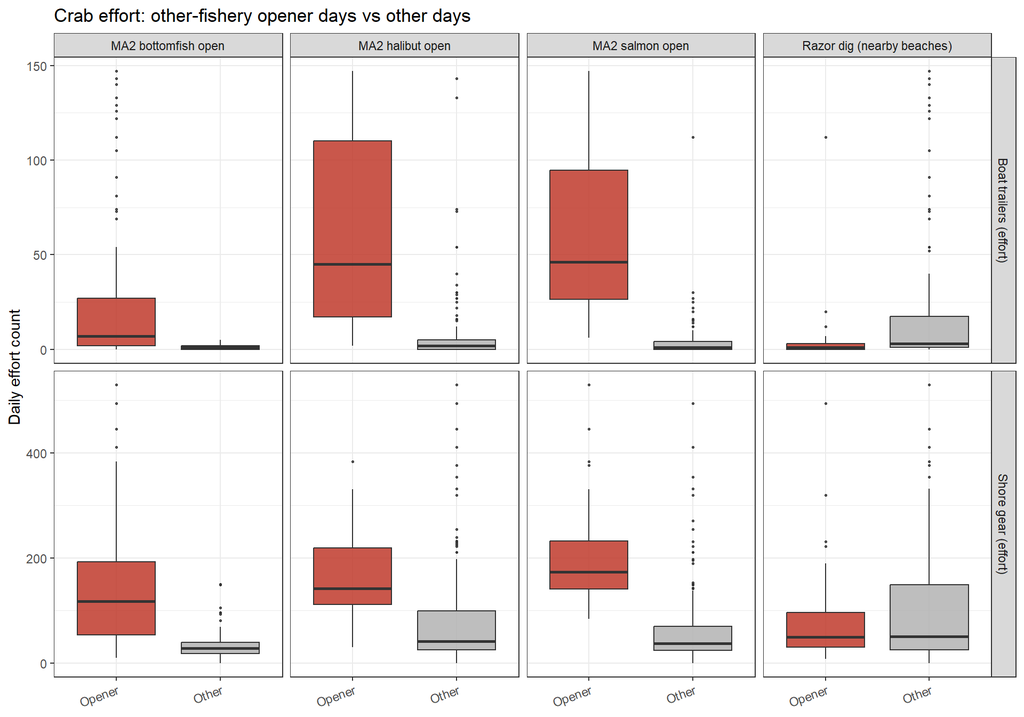

Crab effort on other-fishery opener days vs other days, by opener and series.

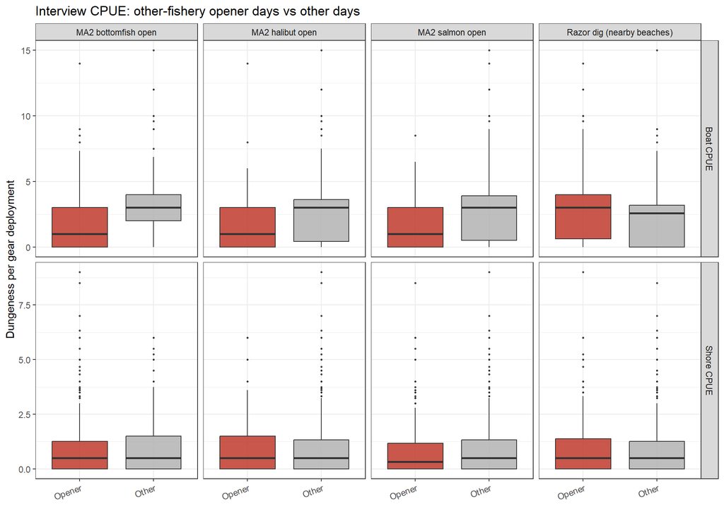

Interview CPUE on other-fishery opener days vs other days, by opener and series.